# Project: Identify Customer Segments

In this project, you will apply unsupervised learning techniques to identify segments of the population that form the core customer base for a mail-order sales company in Germany. These segments can then be used to direct marketing campaigns towards audiences that will have the highest expected rate of returns. The data that you will use has been provided by our partners at Bertelsmann Arvato Analytics, and represents a real-life data science task.

This notebook will help you complete this task by providing a framework within which you will perform your analysis steps. In each step of the project, you will see some text describing the subtask that you will perform, followed by one or more code cells for you to complete your work. **Feel free to add additional code and markdown cells as you go along so that you can explore everything in precise chunks.** The code cells provided in the base template will outline only the major tasks, and will usually not be enough to cover all of the minor tasks that comprise it.

It should be noted that while there will be precise guidelines on how you should handle certain tasks in the project, there will also be places where an exact specification is not provided. **There will be times in the project where you will need to make and justify your own decisions on how to treat the data.** These are places where there may not be only one way to handle the data. In real-life tasks, there may be many valid ways to approach an analysis task. One of the most important things you can do is clearly document your approach so that other scientists can understand the decisions you've made.

At the end of most sections, there will be a Markdown cell labeled **Discussion**. In these cells, you will report your findings for the completed section, as well as document the decisions that you made in your approach to each subtask. **Your project will be evaluated not just on the code used to complete the tasks outlined, but also your communication about your observations and conclusions at each stage.**

```python
###########################################
# Suppress matplotlib user warnings
# Necessary for newer version of matplotlib
import warnings
warnings.filterwarnings("ignore", category = UserWarning, module = "matplotlib")
#
# Display inline matplotlib plots with IPython
from IPython import get_ipython
get_ipython().run_line_magic('matplotlib', 'inline')
###########################################

# import libraries here; add more as necessary
import numpy as np
import pandas as pd
import matplotlib.pyplot as plt
import seaborn as sns
# added libraries
from sklearn.decomposition import PCA
from sklearn.preprocessing import StandardScaler
from sklearn.ensemble import RandomForestClassifier
from sklearn.model_selection import train_test_split
from sklearn.metrics import confusion_matrix, accuracy_score
from sklearn.metrics.pairwise import euclidean_distances
from sklearn.preprocessing import Imputer

import matplotlib.image as mpimg
import matplotlib.cm as cm

from mpl_toolkits.mplot3d import Axes3D
from sklearn.cluster import KMeans
from sklearn.datasets import make_blobs

from IPython.display import display

# magic word for producing visualizations in notebook
%matplotlib inline
import random

# Make the images larger
plt.rcParams['figure.figsize'] = (16, 9)

'''
Import note: The classroom currently uses sklearn version 0.19.
If you need to use an imputer, it is available in sklearn.preprocessing.Imputer,
instead of sklearn.impute as in newer versions of sklearn.
'''
```

```
'\nImport note: The classroom currently uses sklearn version 0.19.\nIf you need to use an imputer, it is available in sklearn.preprocessing.Imputer,\ninstead of sklearn.impute as in newer versions of sklearn.\n'
```

### Step 0: Load the Data

There are four files associated with this project (not including this one):

- `Udacity_AZDIAS_Subset.csv`: Demographics data for the general population of Germany; 891211 persons (rows) x 85 features (columns).
- `Udacity_CUSTOMERS_Subset.csv`: Demographics data for customers of a mail-order company; 191652 persons (rows) x 85 features (columns).
- `Data_Dictionary.md`: Detailed information file about the features in the provided datasets.
- `AZDIAS_Feature_Summary.csv`: Summary of feature attributes for demographics data; 85 features (rows) x 4 columns

Each row of the demographics files represents a single person, but also includes information outside of individuals, including information about their household, building, and neighborhood. You will use this information to cluster the general population into groups with similar demographic properties. Then, you will see how the people in the customers dataset fit into those created clusters. The hope here is that certain clusters are over-represented in the customers data, as compared to the general population; those over-represented clusters will be assumed to be part of the core userbase. This information can then be used for further applications, such as targeting for a marketing campaign.

To start off with, load in the demographics data for the general population into a pandas DataFrame, and do the same for the feature attributes summary. Note for all of the `.csv` data files in this project: they're semicolon (`;`) delimited, so you'll need an additional argument in your [`read_csv()`](https://pandas.pydata.org/pandas-docs/stable/generated/pandas.read_csv.html) call to read in the data properly. Also, considering the size of the main dataset, it may take some time for it to load completely.

Once the dataset is loaded, it's recommended that you take a little bit of time just browsing the general structure of the dataset and feature summary file. You'll be getting deep into the innards of the cleaning in the first major step of the project, so gaining some general familiarity can help you get your bearings.

```python
# Load in the general demographics data.
azdias = pd.read_csv('./Udacity_AZDIAS_Subset.csv', sep=';')

# Load in the feature summary file.
feat_info = pd.read_csv('./AZDIAS_Feature_Summary.csv', sep=';')
```

```python
# Check the structure of the data after it's loaded (e.g. print the number of
# rows and columns, print the first few rows).

azdias.shape
```

```
(891221, 85)
```

```python
pd.set_option('max_columns', None)
pd.set_option('max_rows', None)
```

```python
azdias.head()
```

|  | AGER_TYP | ALTERSKATEGORIE_GROB | ANREDE_KZ | CJT_GESAMTTYP | FINANZ_MINIMALIST | FINANZ_SPARER | FINANZ_VORSORGER | FINANZ_ANLEGER | FINANZ_UNAUFFAELLIGER | FINANZ_HAUSBAUER | FINANZTYP | GEBURTSJAHR | GFK_URLAUBERTYP | GREEN_AVANTGARDE | HEALTH_TYP | LP_LEBENSPHASE_FEIN | LP_LEBENSPHASE_GROB | LP_FAMILIE_FEIN | LP_FAMILIE_GROB | LP_STATUS_FEIN | LP_STATUS_GROB | NATIONALITAET_KZ | PRAEGENDE_JUGENDJAHRE | RETOURTYP_BK_S | SEMIO_SOZ | SEMIO_FAM | SEMIO_REL | SEMIO_MAT | SEMIO_VERT | … |
| --- | --- | --- | --- | --- | --- | --- | --- | --- | --- | --- | --- | --- | --- | --- | --- | --- | --- | --- | --- | --- | --- | --- | --- | --- | --- | --- | --- | --- | --- | --- |
| 0 | -1 | 2 | 1 | 2.0 | 3 | 4 | 3 | 5 | 5 | 3 | 4 | 0 | 10.0 | 0 | -1 | 15.0 | 4.0 | 2.0 | 2.0 | 1.0 | 1.0 | 0 | 0 | 5.0 | 2 | 6 | 7 | 5 | 1 | … |
| 1 | -1 | 1 | 2 | 5.0 | 1 | 5 | 2 | 5 | 4 | 5 | 1 | 1996 | 10.0 | 0 | 3 | 21.0 | 6.0 | 5.0 | 3.0 | 2.0 | 1.0 | 1 | 14 | 1.0 | 5 | 4 | 4 | 3 | 1 | … |
| 2 | -1 | 3 | 2 | 3.0 | 1 | 4 | 1 | 2 | 3 | 5 | 1 | 1979 | 10.0 | 1 | 3 | 3.0 | 1.0 | 1.0 | 1.0 | 3.0 | 2.0 | 1 | 15 | 3.0 | 4 | 1 | 3 | 3 | 4 | … |
| 3 | 2 | 4 | 2 | 2.0 | 4 | 2 | 5 | 2 | 1 | 2 | 6 | 1957 | 1.0 | 0 | 2 | 0.0 | 0.0 | 0.0 | 0.0 | 9.0 | 4.0 | 1 | 8 | 2.0 | 5 | 1 | 2 | 1 | 4 | … |
| 4 | -1 | 3 | 1 | 5.0 | 4 | 3 | 4 | 1 | 3 | 2 | 5 | 1963 | 5.0 | 0 | 3 | 32.0 | 10.0 | 10.0 | 5.0 | 3.0 | 2.0 | 1 | 8 | 5.0 | 6 | 4 | 4 | 2 | 7 | … |

```python
azdias.tail()
```

|  | AGER_TYP | ALTERSKATEGORIE_GROB | ANREDE_KZ | CJT_GESAMTTYP | FINANZ_MINIMALIST | FINANZ_SPARER | FINANZ_VORSORGER | FINANZ_ANLEGER | FINANZ_UNAUFFAELLIGER | FINANZ_HAUSBAUER | FINANZTYP | GEBURTSJAHR | GFK_URLAUBERTYP | GREEN_AVANTGARDE | HEALTH_TYP | LP_LEBENSPHASE_FEIN | LP_LEBENSPHASE_GROB | LP_FAMILIE_FEIN | LP_FAMILIE_GROB | LP_STATUS_FEIN | LP_STATUS_GROB | NATIONALITAET_KZ | PRAEGENDE_JUGENDJAHRE | RETOURTYP_BK_S | SEMIO_SOZ | SEMIO_FAM | SEMIO_REL | SEMIO_MAT | SEMIO_VERT | … |
| --- | --- | --- | --- | --- | --- | --- | --- | --- | --- | --- | --- | --- | --- | --- | --- | --- | --- | --- | --- | --- | --- | --- | --- | --- | --- | --- | --- | --- | --- | --- |
| 891216 | -1 | 3 | 2 | 5.0 | 1 | 4 | 2 | 5 | 4 | 4 | 1 | 1976 | 12.0 | 0 | 3 | 2.0 | 1.0 | 1.0 | 1.0 | 2.0 | 1.0 | 1 | 14 | 3.0 | 2 | 1 | 3 | 3 | 2 | … |
| 891217 | -1 | 2 | 1 | 4.0 | 3 | 3 | 3 | 2 | 2 | 3 | 6 | 1970 | 1.0 | 0 | -1 | 2.0 | 1.0 | 1.0 | 1.0 | 1.0 | 1.0 | 0 | 10 | 5.0 | 4 | 4 | 7 | 5 | 4 | … |
| 891218 | -1 | 2 | 2 | 4.0 | 2 | 4 | 2 | 5 | 4 | 3 | 1 | 1976 | 10.0 | 0 | 1 | 0.0 | 0.0 | 0.0 | 0.0 | 4.0 | 2.0 | 1 | 14 | 4.0 | 5 | 2 | 5 | 3 | 2 | … |
| 891219 | -1 | 1 | 1 | 3.0 | 1 | 5 | 3 | 5 | 5 | 5 | 1 | 1994 | 9.0 | 0 | 1 | 29.0 | 9.0 | 9.0 | 5.0 | 2.0 | 1.0 | 1 | 14 | 4.0 | 7 | 7 | 7 | 5 | 6 | … |
| 891220 | -1 | 4 | 1 | 1.0 | 4 | 2 | 5 | 2 | 1 | 5 | 6 | 0 | 12.0 | 0 | 2 | 6.0 | 2.0 | 1.0 | 1.0 | 1.0 | 1.0 | 1 | 3 | 1.0 | 6 | 6 | 3 | 4 | 6 | … |

```python
azdias.describe()
```

|  | AGER_TYP | ALTERSKATEGORIE_GROB | ANREDE_KZ | CJT_GESAMTTYP | FINANZ_MINIMALIST | FINANZ_SPARER | FINANZ_VORSORGER | FINANZ_ANLEGER | FINANZ_UNAUFFAELLIGER | FINANZ_HAUSBAUER | FINANZTYP | GEBURTSJAHR | GFK_URLAUBERTYP | GREEN_AVANTGARDE | HEALTH_TYP | LP_LEBENSPHASE_FEIN | LP_LEBENSPHASE_GROB | LP_FAMILIE_FEIN | LP_FAMILIE_GROB | LP_STATUS_FEIN | LP_STATUS_GROB | NATIONALITAET_KZ | PRAEGENDE_JUGENDJAHRE | RETOURTYP_BK_S | SEMIO_SOZ | SEMIO_FAM | SEMIO_REL | SEMIO_MAT | SEMIO_VERT | … |
| --- | --- | --- | --- | --- | --- | --- | --- | --- | --- | --- | --- | --- | --- | --- | --- | --- | --- | --- | --- | --- | --- | --- | --- | --- | --- | --- | --- | --- | --- | --- |
| count | 891221.000000 | 891221.000000 | 891221.000000 | 886367.000000 | 891221.000000 | 891221.000000 | 891221.000000 | 891221.000000 | 891221.000000 | 891221.000000 | 891221.000000 | 891221.000000 | 886367.000000 | 891221.000000 | 891221.000000 | 886367.000000 | 886367.000000 | 886367.000000 | 886367.000000 | 886367.000000 | 886367.000000 | 891221.000000 | 891221.000000 | 886367.000000 | 891221.000000 | 891221.000000 | 891221.000000 | 891221.000000 | 891221.000000 | … |
| mean | -0.358435 | 2.777398 | 1.522098 | 3.632838 | 3.074528 | 2.821039 | 3.401106 | 3.033328 | 2.874167 | 3.075121 | 3.790586 | 1101.178533 | 7.350304 | 0.196612 | 1.792102 | 14.622637 | 4.453621 | 3.599574 | 2.185966 | 4.791151 | 2.432575 | 1.026827 | 8.154346 | 3.419630 | 3.945860 | 4.272729 | 4.240609 | 4.001597 | 4.023709 | … |
| std | 1.198724 | 1.068775 | 0.499512 | 1.595021 | 1.321055 | 1.464749 | 1.322134 | 1.529603 | 1.486731 | 1.353248 | 1.987876 | 976.583551 | 3.525723 | 0.397437 | 1.269062 | 12.616883 | 3.855639 | 3.926486 | 1.756537 | 3.425305 | 1.474315 | 0.586634 | 4.844532 | 1.417741 | 1.946564 | 1.915885 | 2.007373 | 1.857540 | 2.077746 | … |
| min | -1.000000 | 1.000000 | 1.000000 | 1.000000 | 1.000000 | 1.000000 | 1.000000 | 1.000000 | 1.000000 | 1.000000 | 1.000000 | 0.000000 | 1.000000 | 0.000000 | -1.000000 | 0.000000 | 0.000000 | 0.000000 | 0.000000 | 1.000000 | 1.000000 | 0.000000 | 0.000000 | 1.000000 | 1.000000 | 1.000000 | 1.000000 | 1.000000 | 1.000000 | … |
| 25% | -1.000000 | 2.000000 | 1.000000 | 2.000000 | 2.000000 | 1.000000 | 3.000000 | 2.000000 | 2.000000 | 2.000000 | 2.000000 | 0.000000 | 5.000000 | 0.000000 | 1.000000 | 4.000000 | 1.000000 | 1.000000 | 1.000000 | 2.000000 | 1.000000 | 1.000000 | 5.000000 | 2.000000 | 2.000000 | 3.000000 | 3.000000 | 2.000000 | 2.000000 | … |
| 50% | -1.000000 | 3.000000 | 2.000000 | 4.000000 | 3.000000 | 3.000000 | 3.000000 | 3.000000 | 3.000000 | 3.000000 | 4.000000 | 1943.000000 | 8.000000 | 0.000000 | 2.000000 | 11.000000 | 3.000000 | 1.000000 | 1.000000 | 4.000000 | 2.000000 | 1.000000 | 8.000000 | 3.000000 | 4.000000 | 4.000000 | 4.000000 | 4.000000 | 4.000000 | … |
| 75% | -1.000000 | 4.000000 | 2.000000 | 5.000000 | 4.000000 | 4.000000 | 5.000000 | 5.000000 | 4.000000 | 4.000000 | 6.000000 | 1970.000000 | 10.000000 | 0.000000 | 3.000000 | 27.000000 | 8.000000 | 8.000000 | 4.000000 | 9.000000 | 4.000000 | 1.000000 | 14.000000 | 5.000000 | 6.000000 | 6.000000 | 6.000000 | 5.000000 | 6.000000 | … |
| max | 3.000000 | 9.000000 | 2.000000 | 6.000000 | 5.000000 | 5.000000 | 5.000000 | 5.000000 | 5.000000 | 5.000000 | 6.000000 | 2017.000000 | 12.000000 | 1.000000 | 3.000000 | 40.000000 | 12.000000 | 11.000000 | 5.000000 | 10.000000 | 5.000000 | 3.000000 | 15.000000 | 5.000000 | 7.000000 | 7.000000 | 7.000000 | 7.000000 | 7.000000 | … |

### AZDIAS Demographics Data Observation

By initial inspection, it seems that some features contains numerous unknown or missing values. For instace, **AGER_TYP** has at least 75% of lines filled with '-1' which means 75% of data are missing/unknown. Next, I prepare a dataset where both naturally missing and unknown/missing values will be encoded as NaNs; and based on that I take a decision for dropping certain features.

```python
azdias.info()
```

```
<class 'pandas.core.frame.DataFrame'>
RangeIndex: 891221 entries, 0 to 891220
Data columns (total 85 columns):
AGER_TYP                 891221 non-null int64
ALTERSKATEGORIE_GROB     891221 non-null int64
ANREDE_KZ                891221 non-null int64
CJT_GESAMTTYP            886367 non-null float64
FINANZ_MINIMALIST        891221 non-null int64
FINANZ_SPARER            891221 non-null int64
FINANZ_VORSORGER         891221 non-null int64
FINANZ_ANLEGER           891221 non-null int64
FINANZ_UNAUFFAELLIGER    891221 non-null int64
FINANZ_HAUSBAUER         891221 non-null int64
FINANZTYP                891221 non-null int64
GEBURTSJAHR              891221 non-null int64
GFK_URLAUBERTYP          886367 non-null float64
GREEN_AVANTGARDE         891221 non-null int64
HEALTH_TYP               891221 non-null int64
LP_LEBENSPHASE_FEIN      886367 non-null float64
LP_LEBENSPHASE_GROB      886367 non-null float64
LP_FAMILIE_FEIN          886367 non-null float64
LP_FAMILIE_GROB          886367 non-null float64
LP_STATUS_FEIN           886367 non-null float64
LP_STATUS_GROB           886367 non-null float64
NATIONALITAET_KZ         891221 non-null int64
PRAEGENDE_JUGENDJAHRE    891221 non-null int64
RETOURTYP_BK_S           886367 non-null float64
SEMIO_SOZ                891221 non-null int64
SEMIO_FAM                891221 non-null int64
SEMIO_REL                891221 non-null int64
SEMIO_MAT                891221 non-null int64
SEMIO_VERT               891221 non-null int64
SEMIO_LUST               891221 non-null int64
SEMIO_ERL                891221 non-null int64
SEMIO_KULT               891221 non-null int64
SEMIO_RAT                891221 non-null int64
SEMIO_KRIT               891221 non-null int64
SEMIO_DOM                891221 non-null int64
SEMIO_KAEM               891221 non-null int64
SEMIO_PFLICHT            891221 non-null int64
```

[output cut: 35 more lines]

```
ONLINE_AFFINITAET        886367 non-null float64
REGIOTYP                 770025 non-null float64
KBA13_ANZAHL_PKW         785421 non-null float64
PLZ8_ANTG1               774706 non-null float64
PLZ8_ANTG2               774706 non-null float64
PLZ8_ANTG3               774706 non-null float64
PLZ8_ANTG4               774706 non-null float64
PLZ8_BAUMAX              774706 non-null float64
PLZ8_HHZ                 774706 non-null float64
PLZ8_GBZ                 774706 non-null float64
ARBEIT                   794005 non-null float64
ORTSGR_KLS9              794005 non-null float64
RELAT_AB                 794005 non-null float64
dtypes: float64(49), int64(32), object(4)
memory usage: 578.0+ MB
```

### feat_info

feature summary file

```python
## Exploring feature summary file
## Summary of feature attributes for demographics data; 85 features (rows) x 4 columns

# feat_info = pd.read_csv('./AZDIAS_Feature_Summary.csv', sep=';')
feat_info.shape
```

```
(85, 4)
```

```python
feat_info
```

|  | attribute | information_level | type | missing_or_unknown |
| --- | --- | --- | --- | --- |
| 0 | AGER_TYP | person | categorical | [-1,0] |
| 1 | ALTERSKATEGORIE_GROB | person | ordinal | [-1,0,9] |
| 2 | ANREDE_KZ | person | categorical | [-1,0] |
| 3 | CJT_GESAMTTYP | person | categorical | [0] |
| 4 | FINANZ_MINIMALIST | person | ordinal | [-1] |
| 5 | FINANZ_SPARER | person | ordinal | [-1] |
| 6 | FINANZ_VORSORGER | person | ordinal | [-1] |
| 7 | FINANZ_ANLEGER | person | ordinal | [-1] |
| 8 | FINANZ_UNAUFFAELLIGER | person | ordinal | [-1] |
| 9 | FINANZ_HAUSBAUER | person | ordinal | [-1] |
| 10 | FINANZTYP | person | categorical | [-1] |
| 11 | GEBURTSJAHR | person | numeric | [0] |
| 12 | GFK_URLAUBERTYP | person | categorical | [] |
| 13 | GREEN_AVANTGARDE | person | categorical | [] |
| 14 | HEALTH_TYP | person | ordinal | [-1,0] |
| 15 | LP_LEBENSPHASE_FEIN | person | mixed | [0] |
| 16 | LP_LEBENSPHASE_GROB | person | mixed | [0] |
| 17 | LP_FAMILIE_FEIN | person | categorical | [0] |
| 18 | LP_FAMILIE_GROB | person | categorical | [0] |
| 19 | LP_STATUS_FEIN | person | categorical | [0] |
| 20 | LP_STATUS_GROB | person | categorical | [0] |
| 21 | NATIONALITAET_KZ | person | categorical | [-1,0] |
| 22 | PRAEGENDE_JUGENDJAHRE | person | mixed | [-1,0] |
| 23 | RETOURTYP_BK_S | person | ordinal | [0] |
| 24 | SEMIO_SOZ | person | ordinal | [-1,9] |
| 25 | SEMIO_FAM | person | ordinal | [-1,9] |
| 26 | SEMIO_REL | person | ordinal | [-1,9] |
| 27 | SEMIO_MAT | person | ordinal | [-1,9] |
| 28 | SEMIO_VERT | person | ordinal | [-1,9] |
| 29 | SEMIO_LUST | person | ordinal | [-1,9] |

[output cut: 55 more lines]

```python
feat_info.describe()
```

|  | attribute | information_level | type | missing_or_unknown |
| --- | --- | --- | --- | --- |
| count | 85 | 85 | 85 | 85 |
| unique | 85 | 9 | 5 | 9 |
| top | FINANZ_ANLEGER | person | ordinal | [-1] |
| freq | 1 | 43 | 49 | 26 |

```python
feat_info.info()
```

```
<class 'pandas.core.frame.DataFrame'>
RangeIndex: 85 entries, 0 to 84
Data columns (total 4 columns):
attribute             85 non-null object
information_level     85 non-null object
type                  85 non-null object
missing_or_unknown    85 non-null object
dtypes: object(4)
memory usage: 2.7+ KB
```

> **Tip**: Add additional cells to keep everything in reasonably-sized chunks! Keyboard shortcut `esc --> a` (press escape to enter command mode, then press the 'A' key) adds a new cell before the active cell, and `esc --> b` adds a new cell after the active cell. If you need to convert an active cell to a markdown cell, use `esc --> m` and to convert to a code cell, use `esc --> y`.

## Step 1: Preprocessing

### Step 1.1: Assess Missing Data

The feature summary file contains a summary of properties for each demographics data column. You will use this file to help you make cleaning decisions during this stage of the project. First of all, you should assess the demographics data in terms of missing data. Pay attention to the following points as you perform your analysis, and take notes on what you observe. Make sure that you fill in the **Discussion** cell with your findings and decisions at the end of each step that has one!

#### Step 1.1.1: Convert Missing Value Codes to NaNs

The fourth column of the feature attributes summary (loaded in above as `feat_info`) documents the codes from the data dictionary that indicate missing or unknown data. While the file encodes this as a list (e.g. `[-1,0]`), this will get read in as a string object. You'll need to do a little bit of parsing to make use of it to identify and clean the data. Convert data that matches a 'missing' or 'unknown' value code into a numpy NaN value. You might want to see how much data takes on a 'missing' or 'unknown' code, and how much data is naturally missing, as a point of interest.

**As one more reminder, you are encouraged to add additional cells to break up your analysis into manageable chunks.**

```python
# Identify naturally missing values (NaNs)

nat_miss = azdias.isnull().sum()
display(nat_miss)
```

```
AGER_TYP                      0
ALTERSKATEGORIE_GROB          0
ANREDE_KZ                     0
CJT_GESAMTTYP              4854
FINANZ_MINIMALIST             0
FINANZ_SPARER                 0
FINANZ_VORSORGER              0
FINANZ_ANLEGER                0
FINANZ_UNAUFFAELLIGER         0
FINANZ_HAUSBAUER              0
FINANZTYP                     0
GEBURTSJAHR                   0
GFK_URLAUBERTYP            4854
GREEN_AVANTGARDE              0
HEALTH_TYP                    0
LP_LEBENSPHASE_FEIN        4854
LP_LEBENSPHASE_GROB        4854
LP_FAMILIE_FEIN            4854
LP_FAMILIE_GROB            4854
LP_STATUS_FEIN             4854
LP_STATUS_GROB             4854
NATIONALITAET_KZ              0
PRAEGENDE_JUGENDJAHRE         0
RETOURTYP_BK_S             4854
SEMIO_SOZ                     0
SEMIO_FAM                     0
SEMIO_REL                     0
SEMIO_MAT                     0
SEMIO_VERT                    0
SEMIO_LUST                    0
SEMIO_ERL                     0
SEMIO_KULT                    0
SEMIO_RAT                     0
SEMIO_KRIT                    0
SEMIO_DOM                     0
SEMIO_KAEM                    0
SEMIO_PFLICHT                 0
SEMIO_TRADV                   0
SHOPPER_TYP                   0
SOHO_KZ                   73499
```

[output cut: 31 more lines]

```
MOBI_REGIO               133324
ONLINE_AFFINITAET          4854
REGIOTYP                 121196
KBA13_ANZAHL_PKW         105800
PLZ8_ANTG1               116515
PLZ8_ANTG2               116515
PLZ8_ANTG3               116515
PLZ8_ANTG4               116515
PLZ8_BAUMAX              116515
PLZ8_HHZ                 116515
PLZ8_GBZ                 116515
ARBEIT                    97216
ORTSGR_KLS9               97216
RELAT_AB                  97216
dtype: int64
```

```python
missing_value_codes  = str(np.array(feat_info['missing_or_unknown']))
missing_value_codes
```

```
"['[-1,0]' '[-1,0,9]' '[-1,0]' '[0]' '[-1]' '[-1]' '[-1]' '[-1]' '[-1]'\n '[-1]' '[-1]' '[0]' '[]' '[]' '[-1,0]' '[0]' '[0]' '[0]' '[0]' '[0]' '[0]'\n '[-1,0]' '[-1,0]' '[0]' '[-1,9]' '[-1,9]' '[-1,9]' '[-1,9]' '[-1,9]'\n '[-1,9]' '[-1,9]' '[-1,9]' '[-1,9]' '[-1,9]' '[-1,9]' '[-1,9]' '[-1,9]'\n '[-1…
```

```python
# Identify missing or unknown data values and convert them to NaNs.

for indx in range(len(feat_info)):
    missing_or_unknown = feat_info.iloc[indx]['missing_or_unknown']
    missing_or_unknown = missing_or_unknown.strip('[')
    missing_or_unknown = missing_or_unknown.strip(']')
    missing_or_unknown = missing_or_unknown.split(sep=',')
    missing_or_unknown = [int(value) if (value!='X' and value!='XX' and value!='') else value for value in missing_or_unknown]
    if missing_or_unknown != ['']:
        azdias = azdias.replace({feat_info.iloc[indx]['attribute']: missing_or_unknown}, np.nan)
```

```python
azdias.head()
```

|  | AGER_TYP | ALTERSKATEGORIE_GROB | ANREDE_KZ | CJT_GESAMTTYP | FINANZ_MINIMALIST | FINANZ_SPARER | FINANZ_VORSORGER | FINANZ_ANLEGER | FINANZ_UNAUFFAELLIGER | FINANZ_HAUSBAUER | FINANZTYP | GEBURTSJAHR | GFK_URLAUBERTYP | GREEN_AVANTGARDE | HEALTH_TYP | LP_LEBENSPHASE_FEIN | LP_LEBENSPHASE_GROB | LP_FAMILIE_FEIN | LP_FAMILIE_GROB | LP_STATUS_FEIN | LP_STATUS_GROB | NATIONALITAET_KZ | PRAEGENDE_JUGENDJAHRE | RETOURTYP_BK_S | SEMIO_SOZ | SEMIO_FAM | SEMIO_REL | SEMIO_MAT | SEMIO_VERT | … |
| --- | --- | --- | --- | --- | --- | --- | --- | --- | --- | --- | --- | --- | --- | --- | --- | --- | --- | --- | --- | --- | --- | --- | --- | --- | --- | --- | --- | --- | --- | --- |
| 0 | NaN | 2.0 | 1 | 2.0 | 3 | 4 | 3 | 5 | 5 | 3 | 4 | NaN | 10.0 | 0 | NaN | 15.0 | 4.0 | 2.0 | 2.0 | 1.0 | 1.0 | NaN | NaN | 5.0 | 2 | 6 | 7 | 5 | 1 | … |
| 1 | NaN | 1.0 | 2 | 5.0 | 1 | 5 | 2 | 5 | 4 | 5 | 1 | 1996.0 | 10.0 | 0 | 3.0 | 21.0 | 6.0 | 5.0 | 3.0 | 2.0 | 1.0 | 1.0 | 14.0 | 1.0 | 5 | 4 | 4 | 3 | 1 | … |
| 2 | NaN | 3.0 | 2 | 3.0 | 1 | 4 | 1 | 2 | 3 | 5 | 1 | 1979.0 | 10.0 | 1 | 3.0 | 3.0 | 1.0 | 1.0 | 1.0 | 3.0 | 2.0 | 1.0 | 15.0 | 3.0 | 4 | 1 | 3 | 3 | 4 | … |
| 3 | 2.0 | 4.0 | 2 | 2.0 | 4 | 2 | 5 | 2 | 1 | 2 | 6 | 1957.0 | 1.0 | 0 | 2.0 | NaN | NaN | NaN | NaN | 9.0 | 4.0 | 1.0 | 8.0 | 2.0 | 5 | 1 | 2 | 1 | 4 | … |
| 4 | NaN | 3.0 | 1 | 5.0 | 4 | 3 | 4 | 1 | 3 | 2 | 5 | 1963.0 | 5.0 | 0 | 3.0 | 32.0 | 10.0 | 10.0 | 5.0 | 3.0 | 2.0 | 1.0 | 8.0 | 5.0 | 6 | 4 | 4 | 2 | 7 | … |

```python
azdias_dims = azdias.shape
azdias_dims
```

```
(891221, 85)
```

```python
azdias_total_nan = azdias.isna().sum().sum() # OR azdias.isnull().sum().sum()
azdias_total_nan # 8373929
```

```
8373929
```

```python
# Count non-NA cells for all columns
# The values None, NaN, NaT, and optionally numpy.inf
# (depending on pandas.options.mode.use_inf_as_na) are considered NA.
azdias.count().sum()
```

```
67379856
```

```python
# count total elements
total_elements = azdias_dims[0] * azdias_dims[1]
total_elements
```

```
75753785
```

```python
azdias_nan_count = total_elements - azdias.count().sum()
azdias_nan_count
```

```
8373929
```

```python
azdias_nan_percent = (azdias_nan_count/total_elements) * 100
azdias_nan_percent
```

```
11.05413940702765
```

### Observation on missing data

As seen from above data analysis, NaN values account for about 11% of the total AZDIAS demographics data for the general population of Germany.

```python
# sums the values across all rows for a column
# azdias.sum(axis=0)
```

```python
len(azdias)
```

```
891221
```

```python
# azdias.isnull().sum(axis=0) one will do the trick and will return counts of nulls for every column:
# df.isnull().sum()/len(df)*100

(azdias.isnull().sum(axis=0) / len(azdias)) * 100
```

```
AGER_TYP                 76.955435
ALTERSKATEGORIE_GROB      0.323264
ANREDE_KZ                 0.000000
CJT_GESAMTTYP             0.544646
FINANZ_MINIMALIST         0.000000
FINANZ_SPARER             0.000000
FINANZ_VORSORGER          0.000000
FINANZ_ANLEGER            0.000000
FINANZ_UNAUFFAELLIGER     0.000000
FINANZ_HAUSBAUER          0.000000
FINANZTYP                 0.000000
GEBURTSJAHR              44.020282
GFK_URLAUBERTYP           0.544646
GREEN_AVANTGARDE          0.000000
HEALTH_TYP               12.476816
LP_LEBENSPHASE_FEIN      10.954859
LP_LEBENSPHASE_GROB      10.611509
LP_FAMILIE_FEIN           8.728699
LP_FAMILIE_GROB           8.728699
LP_STATUS_FEIN            0.544646
LP_STATUS_GROB            0.544646
NATIONALITAET_KZ         12.153551
PRAEGENDE_JUGENDJAHRE    12.136608
RETOURTYP_BK_S            0.544646
SEMIO_SOZ                 0.000000
SEMIO_FAM                 0.000000
SEMIO_REL                 0.000000
SEMIO_MAT                 0.000000
SEMIO_VERT                0.000000
SEMIO_LUST                0.000000
SEMIO_ERL                 0.000000
SEMIO_KULT                0.000000
SEMIO_RAT                 0.000000
SEMIO_KRIT                0.000000
SEMIO_DOM                 0.000000
SEMIO_KAEM                0.000000
SEMIO_PFLICHT             0.000000
SEMIO_TRADV               0.000000
SHOPPER_TYP              12.476816
SOHO_KZ                   8.247000
```

[output cut: 31 more lines]

```
MOBI_REGIO               14.959701
ONLINE_AFFINITAET         0.544646
REGIOTYP                 17.735668
KBA13_ANZAHL_PKW         11.871354
PLZ8_ANTG1               13.073637
PLZ8_ANTG2               13.073637
PLZ8_ANTG3               13.073637
PLZ8_ANTG4               13.073637
PLZ8_BAUMAX              13.073637
PLZ8_HHZ                 13.073637
PLZ8_GBZ                 13.073637
ARBEIT                   10.926022
ORTSGR_KLS9              10.914689
RELAT_AB                 10.926022
dtype: float64
```

```python
# Comparison between naturally (originally) missing values saved in nat_miss vs. NaN-converted missing value codes

azdias_nan_count = azdias.isnull().sum()

s1 = pd.Series(nat_miss, name='Naturally missing')
s2 = pd.Series(azdias_nan_count, name='Missing after NaN-conversion')

display(pd.concat([s1, s2], axis=1))
```

|  | Naturally missing | Missing after NaN-conversion |
| --- | --- | --- |
| AGER_TYP | 0 | 685843 |
| ALTERSKATEGORIE_GROB | 0 | 2881 |
| ANREDE_KZ | 0 | 0 |
| CJT_GESAMTTYP | 4854 | 4854 |
| FINANZ_MINIMALIST | 0 | 0 |
| FINANZ_SPARER | 0 | 0 |
| FINANZ_VORSORGER | 0 | 0 |
| FINANZ_ANLEGER | 0 | 0 |
| FINANZ_UNAUFFAELLIGER | 0 | 0 |
| FINANZ_HAUSBAUER | 0 | 0 |
| FINANZTYP | 0 | 0 |
| GEBURTSJAHR | 0 | 392318 |
| GFK_URLAUBERTYP | 4854 | 4854 |
| GREEN_AVANTGARDE | 0 | 0 |
| HEALTH_TYP | 0 | 111196 |
| LP_LEBENSPHASE_FEIN | 4854 | 97632 |
| LP_LEBENSPHASE_GROB | 4854 | 94572 |
| LP_FAMILIE_FEIN | 4854 | 77792 |
| LP_FAMILIE_GROB | 4854 | 77792 |
| LP_STATUS_FEIN | 4854 | 4854 |
| LP_STATUS_GROB | 4854 | 4854 |
| NATIONALITAET_KZ | 0 | 108315 |
| PRAEGENDE_JUGENDJAHRE | 0 | 108164 |
| RETOURTYP_BK_S | 4854 | 4854 |
| SEMIO_SOZ | 0 | 0 |
| SEMIO_FAM | 0 | 0 |
| SEMIO_REL | 0 | 0 |
| SEMIO_MAT | 0 | 0 |
| SEMIO_VERT | 0 | 0 |
| SEMIO_LUST | 0 | 0 |

[output cut: 55 more lines]

### Observation:

As expected, after converting the Missing Value Codes (`missing_or_unknown`) to NaNs, the percieved number of NA cells (including None, NaN, NaT, and optionally numpy.inf (depending on pandas.options.mode.use_inf_as_na)) increased for several columns that had `missing_or_unknown` missing value codes.

#### Step 1.1.2: Assess Missing Data in Each Column

How much missing data is present in each column? There are a few columns that are outliers in terms of the proportion of values that are missing. You will want to use matplotlib's [`hist()`](https://matplotlib.org/api/_as_gen/matplotlib.pyplot.hist.html) function to visualize the distribution of missing value counts to find these columns. Identify and document these columns. While some of these columns might have justifications for keeping or re-encoding the data, for this project you should just remove them from the dataframe. (Feel free to make remarks about these outlier columns in the discussion, however!)

For the remaining features, are there any patterns in which columns have, or share, missing data?

```python
# Perform an assessment of how much missing data there is in each column of the dataset.
print('number of azdias demographics data: ', len(azdias))

azdias_missing_percent = (azdias.isnull().sum(axis=0) / len(azdias)) * 100
# type(azdias_missing_percent)

azdias_missing_percent_df = pd.DataFrame(azdias_missing_percent, columns = ['azdias_missing_percent'])
print("Length of azdias_missing_percent: ", len(azdias_missing_percent_df))
display(azdias_missing_percent_df)
```

```
number of azdias demographics data:  891221
Length of azdias_missing_percent:  85
```

|  | azdias_missing_percent |
| --- | --- |
| AGER_TYP | 76.955435 |
| ALTERSKATEGORIE_GROB | 0.323264 |
| ANREDE_KZ | 0.000000 |
| CJT_GESAMTTYP | 0.544646 |
| FINANZ_MINIMALIST | 0.000000 |
| FINANZ_SPARER | 0.000000 |
| FINANZ_VORSORGER | 0.000000 |
| FINANZ_ANLEGER | 0.000000 |
| FINANZ_UNAUFFAELLIGER | 0.000000 |
| FINANZ_HAUSBAUER | 0.000000 |
| FINANZTYP | 0.000000 |
| GEBURTSJAHR | 44.020282 |
| GFK_URLAUBERTYP | 0.544646 |
| GREEN_AVANTGARDE | 0.000000 |
| HEALTH_TYP | 12.476816 |
| LP_LEBENSPHASE_FEIN | 10.954859 |
| LP_LEBENSPHASE_GROB | 10.611509 |
| LP_FAMILIE_FEIN | 8.728699 |
| LP_FAMILIE_GROB | 8.728699 |
| LP_STATUS_FEIN | 0.544646 |
| LP_STATUS_GROB | 0.544646 |
| NATIONALITAET_KZ | 12.153551 |
| PRAEGENDE_JUGENDJAHRE | 12.136608 |
| RETOURTYP_BK_S | 0.544646 |
| SEMIO_SOZ | 0.000000 |
| SEMIO_FAM | 0.000000 |
| SEMIO_REL | 0.000000 |
| SEMIO_MAT | 0.000000 |
| SEMIO_VERT | 0.000000 |
| SEMIO_LUST | 0.000000 |

[output cut: 55 more lines]

```
array([[<matplotlib.axes._subplots.AxesSubplot object at 0x7f32e445e7f0>]], dtype=object)
```

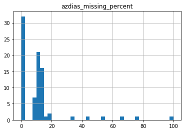

```python
azdias_missing_percent_df.hist(bins = 40)
```

```python
# Filter features missing more than 10% of data

azdias_missing_percent_g10_df = azdias_missing_percent_df[azdias_missing_percent_df['azdias_missing_percent'] > 10.0]
azdias_missing_percent_g10_sorted_df = azdias_missing_percent_g10_df.sort_values(by=['azdias_missing_percent'], inplace=False, ascending=False)

print("Length of azdias_missing_percent > 10%: ", len(azdias_missing_percent_g10_sorted_df))
display(azdias_missing_percent_g10_sorted_df)
```

```
Length of azdias_missing_percent > 10%:  46
```

|  | azdias_missing_percent |
| --- | --- |
| TITEL_KZ | 99.757636 |
| AGER_TYP | 76.955435 |
| KK_KUNDENTYP | 65.596749 |
| KBA05_BAUMAX | 53.468668 |
| GEBURTSJAHR | 44.020282 |
| ALTER_HH | 34.813699 |
| REGIOTYP | 17.735668 |
| KKK | 17.735668 |
| W_KEIT_KIND_HH | 16.605084 |
| KBA05_ANTG1 | 14.959701 |
| MOBI_REGIO | 14.959701 |
| KBA05_GBZ | 14.959701 |
| KBA05_ANTG4 | 14.959701 |
| KBA05_ANTG3 | 14.959701 |
| KBA05_ANTG2 | 14.959701 |
| PLZ8_ANTG2 | 13.073637 |
| PLZ8_ANTG3 | 13.073637 |
| PLZ8_ANTG1 | 13.073637 |
| PLZ8_ANTG4 | 13.073637 |
| PLZ8_BAUMAX | 13.073637 |
| PLZ8_HHZ | 13.073637 |
| PLZ8_GBZ | 13.073637 |
| HEALTH_TYP | 12.476816 |
| VERS_TYP | 12.476816 |
| SHOPPER_TYP | 12.476816 |
| NATIONALITAET_KZ | 12.153551 |
| PRAEGENDE_JUGENDJAHRE | 12.136608 |
| KBA13_ANZAHL_PKW | 11.871354 |
| ANZ_HAUSHALTE_AKTIV | 11.176913 |
| CAMEO_INTL_2015 | 11.147852 |
| CAMEO_DEU_2015 | 11.147852 |
| CAMEO_DEUG_2015 | 11.147852 |
| LP_LEBENSPHASE_FEIN | 10.954859 |
| ARBEIT | 10.926022 |
| RELAT_AB | 10.926022 |
| ORTSGR_KLS9 | 10.914689 |
| ANZ_HH_TITEL | 10.884842 |
| LP_LEBENSPHASE_GROB | 10.611509 |
| INNENSTADT | 10.518154 |
| EWDICHTE | 10.518154 |
| BALLRAUM | 10.518154 |
| GEBAEUDETYP_RASTER | 10.452514 |
| MIN_GEBAEUDEJAHR | 10.451729 |
| WOHNLAGE | 10.451729 |
| OST_WEST_KZ | 10.451729 |
| GEBAEUDETYP | 10.451729 |

```
<function matplotlib.pyplot.show(*args, **kw)>
```

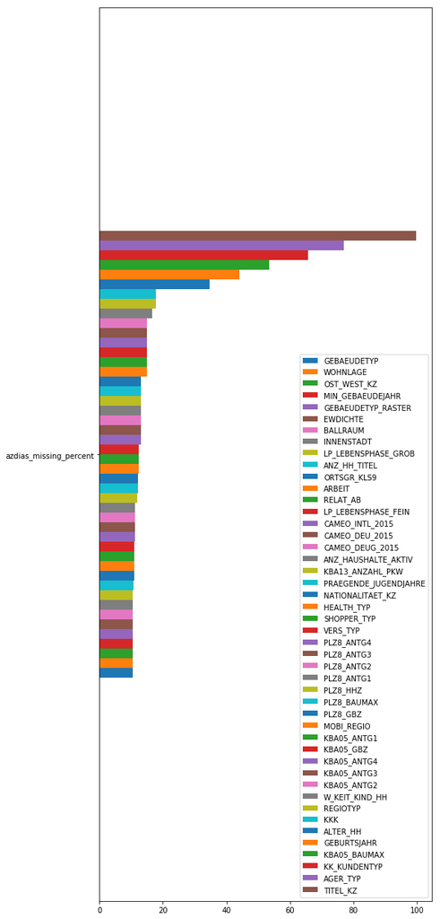

```python
# Investigate patterns in amount of missing data in each column. # cmap=plt.cm.Blues

azdias_missing_percent_g10_sorted_asc_df = azdias_missing_percent_g10_df.sort_values(by=['azdias_missing_percent'], inplace=False, ascending=True)

azdias_missing_percent_g10_sorted_asc_tr_df = azdias_missing_percent_g10_sorted_asc_df.transpose()
azdias_missing_percent_g10_sorted_asc_tr_df.plot(kind='barh', figsize = (8,22))
plt.show
```

```python
azdias_missing_percent_g20_df = azdias_missing_percent_df[azdias_missing_percent_df['azdias_missing_percent'] > 20.0]
azdias_missing_percent_g20_sorted_df = azdias_missing_percent_g20_df.sort_values(by=['azdias_missing_percent'], inplace=False, ascending=False)
display(azdias_missing_percent_g20_sorted_df)
```

|  | azdias_missing_percent |
| --- | --- |
| TITEL_KZ | 99.757636 |
| AGER_TYP | 76.955435 |
| KK_KUNDENTYP | 65.596749 |
| KBA05_BAUMAX | 53.468668 |
| GEBURTSJAHR | 44.020282 |
| ALTER_HH | 34.813699 |

As evident from the plot above, 46 features contains NaN values in more than 10% of their respective columns, within these 46 columns there are 6 outliers with well over 20% of missing values which I remove from consideration moving forward.

- `TITEL_KZ` `99.76%`
- `AGER_TYP` `76.95%`
- `KK_KUNDENTYP` `65.60%`
- `KBA05_BAUMAX` `53.47%`
- `GEBURTSJAHR` `44.02%`
- `ALTER_HH` `34.81%`

```python
azdias_missing_percent_g20_tr_df = azdias_missing_percent_g20_df.transpose()
azdias_missing_percent_g20_tr_df
```

|  | AGER_TYP | GEBURTSJAHR | TITEL_KZ | ALTER_HH | KK_KUNDENTYP | KBA05_BAUMAX |
| --- | --- | --- | --- | --- | --- | --- |
| azdias_missing_percent | 76.955435 | 44.020282 | 99.757636 | 34.813699 | 65.596749 | 53.468668 |

```python
# Remove the outlier columns from the dataset. (You'll perform other data
# engineering tasks such as re-encoding and imputation later.)

azdias_missing_percent_g20_tr_df = azdias_missing_percent_g20_df.transpose()
azdias2 = azdias.drop(azdias_missing_percent_g20_tr_df, axis = 1)

#checking if columns were eliminated
print(azdias2.shape)
display(azdias2.head(n=10))
```

```
(891221, 79)
```

|  | ALTERSKATEGORIE_GROB | ANREDE_KZ | CJT_GESAMTTYP | FINANZ_MINIMALIST | FINANZ_SPARER | FINANZ_VORSORGER | FINANZ_ANLEGER | FINANZ_UNAUFFAELLIGER | FINANZ_HAUSBAUER | FINANZTYP | GFK_URLAUBERTYP | GREEN_AVANTGARDE | HEALTH_TYP | LP_LEBENSPHASE_FEIN | LP_LEBENSPHASE_GROB | LP_FAMILIE_FEIN | LP_FAMILIE_GROB | LP_STATUS_FEIN | LP_STATUS_GROB | NATIONALITAET_KZ | PRAEGENDE_JUGENDJAHRE | RETOURTYP_BK_S | SEMIO_SOZ | SEMIO_FAM | SEMIO_REL | SEMIO_MAT | SEMIO_VERT | SEMIO_LUST | SEMIO_ERL | … |
| --- | --- | --- | --- | --- | --- | --- | --- | --- | --- | --- | --- | --- | --- | --- | --- | --- | --- | --- | --- | --- | --- | --- | --- | --- | --- | --- | --- | --- | --- | --- |
| 0 | 2.0 | 1 | 2.0 | 3 | 4 | 3 | 5 | 5 | 3 | 4 | 10.0 | 0 | NaN | 15.0 | 4.0 | 2.0 | 2.0 | 1.0 | 1.0 | NaN | NaN | 5.0 | 2 | 6 | 7 | 5 | 1 | 5 | 3 | … |
| 1 | 1.0 | 2 | 5.0 | 1 | 5 | 2 | 5 | 4 | 5 | 1 | 10.0 | 0 | 3.0 | 21.0 | 6.0 | 5.0 | 3.0 | 2.0 | 1.0 | 1.0 | 14.0 | 1.0 | 5 | 4 | 4 | 3 | 1 | 2 | 2 | … |
| 2 | 3.0 | 2 | 3.0 | 1 | 4 | 1 | 2 | 3 | 5 | 1 | 10.0 | 1 | 3.0 | 3.0 | 1.0 | 1.0 | 1.0 | 3.0 | 2.0 | 1.0 | 15.0 | 3.0 | 4 | 1 | 3 | 3 | 4 | 4 | 6 | … |
| 3 | 4.0 | 2 | 2.0 | 4 | 2 | 5 | 2 | 1 | 2 | 6 | 1.0 | 0 | 2.0 | NaN | NaN | NaN | NaN | 9.0 | 4.0 | 1.0 | 8.0 | 2.0 | 5 | 1 | 2 | 1 | 4 | 4 | 7 | … |
| 4 | 3.0 | 1 | 5.0 | 4 | 3 | 4 | 1 | 3 | 2 | 5 | 5.0 | 0 | 3.0 | 32.0 | 10.0 | 10.0 | 5.0 | 3.0 | 2.0 | 1.0 | 8.0 | 5.0 | 6 | 4 | 4 | 2 | 7 | 4 | 4 | … |
| 5 | 1.0 | 2 | 2.0 | 3 | 1 | 5 | 2 | 2 | 5 | 2 | 1.0 | 0 | 3.0 | 8.0 | 2.0 | 1.0 | 1.0 | 4.0 | 2.0 | 1.0 | 3.0 | 3.0 | 2 | 4 | 7 | 4 | 2 | 2 | 2 | … |
| 6 | 2.0 | 2 | 5.0 | 1 | 5 | 1 | 5 | 4 | 3 | 4 | 12.0 | 0 | 2.0 | 2.0 | 1.0 | 1.0 | 1.0 | 2.0 | 1.0 | 1.0 | 10.0 | 4.0 | 2 | 5 | 5 | 7 | 2 | 6 | 5 | … |
| 7 | 1.0 | 1 | 3.0 | 3 | 3 | 4 | 1 | 3 | 2 | 5 | 9.0 | 0 | 1.0 | 5.0 | 2.0 | 1.0 | 1.0 | 1.0 | 1.0 | 1.0 | 8.0 | 5.0 | 7 | 7 | 7 | 5 | 6 | 2 | 2 | … |
| 8 | 3.0 | 1 | 3.0 | 4 | 4 | 2 | 4 | 2 | 2 | 6 | 3.0 | 1 | 3.0 | 10.0 | 3.0 | 1.0 | 1.0 | 10.0 | 5.0 | 1.0 | 11.0 | 4.0 | 4 | 5 | 4 | 1 | 5 | 6 | 4 | … |
| 9 | 3.0 | 2 | 4.0 | 2 | 4 | 2 | 3 | 5 | 4 | 1 | 12.0 | 1 | 2.0 | 4.0 | 1.0 | 1.0 | 1.0 | 3.0 | 2.0 | 1.0 | 15.0 | 4.0 | 2 | 1 | 1 | 3 | 2 | 6 | 6 | … |

```python
azdias_missing_percent_g20_tr_df.columns.values.tolist()
# feat_info_drop_idx = feat_info.isin(azdias_missing_percent_g20_tr_df.columns.values.tolist())
# feat_info_drop_idx[feat_info_drop_idx.attribute == True]
```

```
['AGER_TYP',
 'GEBURTSJAHR',
 'TITEL_KZ',
 'ALTER_HH',
 'KK_KUNDENTYP',
 'KBA05_BAUMAX']
```

```python
# Removing dropped features from feat_info

# values that match dropped features names is marked as True
feat_info_drop_idx = feat_info.isin(azdias_missing_percent_g20_tr_df.columns.values.tolist())

# dropping rows from feat_info where corresponding row of feat_info_drop_idx is labelled True
feat_info2 = feat_info.drop(feat_info_drop_idx[feat_info_drop_idx.attribute == True].index)

print("Dimension of new feat_info2: ", feat_info2.shape)
display(feat_info2)
```

```
Dimension of new feat_info2:  (79, 4)
```

|  | attribute | information_level | type | missing_or_unknown |
| --- | --- | --- | --- | --- |
| 1 | ALTERSKATEGORIE_GROB | person | ordinal | [-1,0,9] |
| 2 | ANREDE_KZ | person | categorical | [-1,0] |
| 3 | CJT_GESAMTTYP | person | categorical | [0] |
| 4 | FINANZ_MINIMALIST | person | ordinal | [-1] |
| 5 | FINANZ_SPARER | person | ordinal | [-1] |
| 6 | FINANZ_VORSORGER | person | ordinal | [-1] |
| 7 | FINANZ_ANLEGER | person | ordinal | [-1] |
| 8 | FINANZ_UNAUFFAELLIGER | person | ordinal | [-1] |
| 9 | FINANZ_HAUSBAUER | person | ordinal | [-1] |
| 10 | FINANZTYP | person | categorical | [-1] |
| 12 | GFK_URLAUBERTYP | person | categorical | [] |
| 13 | GREEN_AVANTGARDE | person | categorical | [] |
| 14 | HEALTH_TYP | person | ordinal | [-1,0] |
| 15 | LP_LEBENSPHASE_FEIN | person | mixed | [0] |
| 16 | LP_LEBENSPHASE_GROB | person | mixed | [0] |
| 17 | LP_FAMILIE_FEIN | person | categorical | [0] |
| 18 | LP_FAMILIE_GROB | person | categorical | [0] |
| 19 | LP_STATUS_FEIN | person | categorical | [0] |
| 20 | LP_STATUS_GROB | person | categorical | [0] |
| 21 | NATIONALITAET_KZ | person | categorical | [-1,0] |
| 22 | PRAEGENDE_JUGENDJAHRE | person | mixed | [-1,0] |
| 23 | RETOURTYP_BK_S | person | ordinal | [0] |
| 24 | SEMIO_SOZ | person | ordinal | [-1,9] |
| 25 | SEMIO_FAM | person | ordinal | [-1,9] |
| 26 | SEMIO_REL | person | ordinal | [-1,9] |
| 27 | SEMIO_MAT | person | ordinal | [-1,9] |
| 28 | SEMIO_VERT | person | ordinal | [-1,9] |
| 29 | SEMIO_LUST | person | ordinal | [-1,9] |
| 30 | SEMIO_ERL | person | ordinal | [-1,9] |
| 31 | SEMIO_KULT | person | ordinal | [-1,9] |
| 32 | SEMIO_RAT | person | ordinal | [-1,9] |
| 33 | SEMIO_KRIT | person | ordinal | [-1,9] |
| 34 | SEMIO_DOM | person | ordinal | [-1,9] |
| 35 | SEMIO_KAEM | person | ordinal | [-1,9] |
| 36 | SEMIO_PFLICHT | person | ordinal | [-1,9] |
| 37 | SEMIO_TRADV | person | ordinal | [-1,9] |
| 38 | SHOPPER_TYP | person | categorical | [-1] |
| 39 | SOHO_KZ | person | categorical | [-1] |
| 41 | VERS_TYP | person | categorical | [-1] |
| 42 | ZABEOTYP | person | categorical | [-1,9] |
| 44 | ANZ_PERSONEN | household | numeric | [] |
| 45 | ANZ_TITEL | household | numeric | [] |
| 46 | HH_EINKOMMEN_SCORE | household | ordinal | [-1,0] |
| 48 | W_KEIT_KIND_HH | household | ordinal | [-1,0] |
| 49 | WOHNDAUER_2008 | household | ordinal | [-1,0] |
| 50 | ANZ_HAUSHALTE_AKTIV | building | numeric | [0] |
| 51 | ANZ_HH_TITEL | building | numeric | [] |
| 52 | GEBAEUDETYP | building | categorical | [-1,0] |
| 53 | KONSUMNAEHE | building | ordinal | [] |
| 54 | MIN_GEBAEUDEJAHR | building | numeric | [0] |
| 55 | OST_WEST_KZ | building | categorical | [-1] |
| 56 | WOHNLAGE | building | mixed | [-1] |
| 57 | CAMEO_DEUG_2015 | microcell_rr4 | categorical | [-1,X] |
| 58 | CAMEO_DEU_2015 | microcell_rr4 | categorical | [XX] |
| 59 | CAMEO_INTL_2015 | microcell_rr4 | mixed | [-1,XX] |
| 60 | KBA05_ANTG1 | microcell_rr3 | ordinal | [-1] |
| 61 | KBA05_ANTG2 | microcell_rr3 | ordinal | [-1] |
| 62 | KBA05_ANTG3 | microcell_rr3 | ordinal | [-1] |
| 63 | KBA05_ANTG4 | microcell_rr3 | ordinal | [-1] |
| 65 | KBA05_GBZ | microcell_rr3 | ordinal | [-1,0] |
| 66 | BALLRAUM | postcode | ordinal | [-1] |
| 67 | EWDICHTE | postcode | ordinal | [-1] |
| 68 | INNENSTADT | postcode | ordinal | [-1] |
| 69 | GEBAEUDETYP_RASTER | region_rr1 | ordinal | [] |
| 70 | KKK | region_rr1 | ordinal | [-1,0] |
| 71 | MOBI_REGIO | region_rr1 | ordinal | [] |
| 72 | ONLINE_AFFINITAET | region_rr1 | ordinal | [] |
| 73 | REGIOTYP | region_rr1 | ordinal | [-1,0] |
| 74 | KBA13_ANZAHL_PKW | macrocell_plz8 | numeric | [] |
| 75 | PLZ8_ANTG1 | macrocell_plz8 | ordinal | [-1] |
| 76 | PLZ8_ANTG2 | macrocell_plz8 | ordinal | [-1] |
| 77 | PLZ8_ANTG3 | macrocell_plz8 | ordinal | [-1] |
| 78 | PLZ8_ANTG4 | macrocell_plz8 | ordinal | [-1] |
| 79 | PLZ8_BAUMAX | macrocell_plz8 | mixed | [-1,0] |
| 80 | PLZ8_HHZ | macrocell_plz8 | ordinal | [-1] |
| 81 | PLZ8_GBZ | macrocell_plz8 | ordinal | [-1] |
| 82 | ARBEIT | community | ordinal | [-1,9] |
| 83 | ORTSGR_KLS9 | community | ordinal | [-1,0] |
| 84 | RELAT_AB | community | ordinal | [-1,9] |

For the remaining features, are there any patterns in which columns have, or share, missing data?

```python
# checking patterns for features without missing values.

azdias_missing_percent_0_df = azdias_missing_percent_df[azdias_missing_percent_df['azdias_missing_percent'] == 0]

print("Number of features without missing data: ", len(azdias_missing_percent_0_df))
display(azdias_missing_percent_0_df)
```

```
Number of features without missing data:  24
```

|  | azdias_missing_percent |
| --- | --- |
| ANREDE_KZ | 0.0 |
| FINANZ_MINIMALIST | 0.0 |
| FINANZ_SPARER | 0.0 |
| FINANZ_VORSORGER | 0.0 |
| FINANZ_ANLEGER | 0.0 |
| FINANZ_UNAUFFAELLIGER | 0.0 |
| FINANZ_HAUSBAUER | 0.0 |
| FINANZTYP | 0.0 |
| GREEN_AVANTGARDE | 0.0 |
| SEMIO_SOZ | 0.0 |
| SEMIO_FAM | 0.0 |
| SEMIO_REL | 0.0 |
| SEMIO_MAT | 0.0 |
| SEMIO_VERT | 0.0 |
| SEMIO_LUST | 0.0 |
| SEMIO_ERL | 0.0 |
| SEMIO_KULT | 0.0 |
| SEMIO_RAT | 0.0 |
| SEMIO_KRIT | 0.0 |
| SEMIO_DOM | 0.0 |
| SEMIO_KAEM | 0.0 |
| SEMIO_PFLICHT | 0.0 |
| SEMIO_TRADV | 0.0 |
| ZABEOTYP | 0.0 |

As evident from the new feature summary dataframe above, there are 24 feature attributes with no missing data!

#### Discussion 1.1.2: Assess Missing Data in Each Column

Here is the brief reporting of my observations regarding the amount of missing data in each column.  
Are there any patterns in missing values?  
Which columns were removed from the dataset?  
For the remaining features, are there any patterns in which columns have, or share, missing data?

As evident from the plots and tables above, 46 features were missing more than 10% data. And out of those 46 features there were 6 outliers with well over 30% of missing values which I removed from `AZDIAS` demographics dataset as well as `feat_info` feature summary file.

- `TITEL_KZ` `99.76 %`
- `AGER_TYP` `76.95 %`
- `KK_KUNDENTYP` `65.60 %`
- `KBA05_BAUMAX` `53.47 %`
- `GEBURTSJAHR` `44.02 %`
- `ALTER_HH` `34.81 %`

**As evident from the following sorted tables in terms of missing counts/percents per column, the following AZDIAS features have the same number of missing values due to overlapping nature of their measurement levels, in descending order of missing data counts:**

1) Both `REGIOTYP` (Neighborhood typology) and `KKK` (Purchasing power in region) features belong to `RR1 region/neighborhood features` measurement level where there is same/high proportion of missing data due to the fact that survey responders do not have idea about those higher-level information or at least not willing to provide such sensitive information publicly.

`REGIOTYP` `158064` `17.74%`  
`KKK` `158064` `17.74%`

2) `KBA05_*` (number of family houses/buildings) features fall under `RR3 micro-cell features` category and `MOBI_REGIO` (movement patterns in the neighborhood) feature falls under `RR1 region/neighborhood features` category.  
Since these questions are related to family houses/buildings and region/neighborhood where these buildings located, responders may have not enough information about that demographics and naturally leave the answers to such questions unanswered/unknown.

`KBA05_ANTG1` `133324` `14.96%`  
`KBA05_ANTG2` `133324` `14.96%`  
`KBA05_ANTG3` `133324` `14.96%`  
`KBA05_ANTG4` `133324` `14.96%`  
`KBA05_GBZ` `133324` `14.96%`  
`MOBI_REGIO` `133324` `14.96%`

3) `PLZ8_*` (Number/type of family houses/households/buildings in PLZ8 region) features belong to `PLZ8 macro-cell features` category altogether and since they all measure the same type of information, they have the same number of missing data. Unsurprisingly these are the survey questions hard to find answers for from ordinary people with no access to such residential demographics information .

`PLZ8_ANTG1` `116515` `13.07%`  
`PLZ8_ANTG2` `116515` `13.07%`  
`PLZ8_ANTG3` `116515` `13.07%`  
`PLZ8_ANTG4` `116515` `13.07%`  
`PLZ8_BAUMAX` `116515` `13.07%`  
`PLZ8_HHZ` `116515` `13.07%`  
`PLZ8_GBZ` `116515` `13.07%`

4) These typology features are all under `Person-level features` category and hence the same number of missing data comes at no surprise given the same level of privacy residing in each measurement (shopper/insurance/health typology).

`SHOPPER_TYP` `111196` `12.48%`  
`VERS_TYP` `111196` `12.48%`  
`HEALTH_TYP` `111196` `12.48%`

5) These are all `RR4 micro-cell features` category associated with Germans Wealth / Life Stage Typology on different granularity/standard levels where the similary in terms of missing data is quite expected.

`CAMEO_INTL_2015` `99352` `11.15%`  
`CAMEO_DEU_2015` `99352` `11.15%`  
`CAMEO_DEUG_2015` `99352` `11.15%`

6) These features are all `Community-level features` out of which `RELAT_AB` and `ARBEIT` contain overlapping information about share of unemployment where the identical number of missing data is anticipated.  
`ORTSGR_KLS9` imparts information about the Size of community which is naturally unknown to ordinary people.

`RELAT_AB` `97375` `10.93%`  
`ARBEIT` `97375` `10.93%`  
`ORTSGR_KLS9` `97274` `10.91%`

7) All of these features fall under `Postcode-level features` category with identical missing data owing to overlapping characteristic in terms of proximity to urbal disctrict plus density of households in specific post code.

`INNENSTADT` `93740` `10.52%`  
`EWDICHTE` `93740` `10.52%`  
`BALLRAUM` `93740` `10.52%`

8) Except `GEBAEUDETYP_RASTER` (Ratio of residential to commercial) which belongs to `RR1 region/neighborhood features` category, other following 4 features are under `Building-level features` with same measurement level and shared information since all measure building-level specifics and neighborhood quality; hence the same amount of missing data is normal.

`GEBAEUDETYP_RASTER` `93155` `10.45%`  
`MIN_GEBAEUDEJAHR` `93148` `10.45%`  
`GEBAEUDETYP` `93148` `10.45%`  
`WOHNLAGE` `93148` `10.45%`  
`OST_WEST_KZ` `93148` `10.45%`

9) These 2 are `Person-level features` that both contain family type information on different scale (fine vs. rough scale); hence overlapping information and same amount of missing data is not uncommon.

`LP_FAMILIE_FEIN` `77792` `8.73%`  
`LP_FAMILIE_GROB` `77792` `8.73%`

10) Other than `SOHO_KZ` (Small office/home office flag) feature which belongs to `Person-level features`, the rest of the 3 features gather household member & residence length information which require same level of demographics granularity when it comes to survey responders; hence same number of missing data values.

`ANZ_PERSONEN` `73499` `8.25%`  
`SOHO_KZ` `73499` `8.25%`  
`ANZ_TITEL` `73499` `8.25%`  
`WOHNDAUER_2008` `73499` `8.25%`

11) `LP_STATUS_FEIN` & `LP_STATUS_GROB` refer to Social status on fine & rough scale, respectively where the same missing data is natural due to overlapping information.

`ONLINE_AFFINITAET` (Online affinity) is under `RR1 region/neighborhood features` category, while `CJT_GESAMTTYP`, `GFK_URLAUBERTYP`, `RETOURTYP_BK_S`, all fall under the category of `Person-level features` with semantic correlation between them which make them inter-dependent so that missing data in one of them directly affects the other; therefore, same amount of missing data is organically happening!

`CJT_GESAMTTYP` `4854` `0.54%`  
`RETOURTYP_BK_S` `4854` `0.54%`  
`ONLINE_AFFINITAET` `4854` `0.54%`  
`LP_STATUS_FEIN` `4854` `0.54%`  
`LP_STATUS_GROB` `4854` `0.54%`  
`GFK_URLAUBERTYP` `4854` `0.54%`

**The following 24 AZDIAS features have no missing values and hence insights drawn from such features are more rigorous.**

The reason for such completeness of data is that all of these features are straight forward questions about financial, personality, gender, personal attitude/preference under `Person-level features` category for which answers are readily available.

`FINANZTYP`  
`GREEN_AVANTGARDE`  
`FINANZ_HAUSBAUER`  
`FINANZ_UNAUFFAELLIGER`  
`FINANZ_ANLEGER`  
`FINANZ_SPARER`  
`FINANZ_MINIMALIST`  
`ANREDE_KZ`  
`FINANZ_VORSORGER`  
`SEMIO_FAM`  
`SEMIO_SOZ`  
`SEMIO_REL`  
`SEMIO_MAT`  
`SEMIO_VERT`  
`SEMIO_LUST`  
`SEMIO_ERL`  
`SEMIO_KULT`  
`SEMIO_RAT`  
`SEMIO_KRIT`  
`SEMIO_DOM`  
`SEMIO_KAEM`  
`SEMIO_PFLICHT`  
`SEMIO_TRADV`  
`ZABEOTYP`

**Conclusion:**  
All in all, the conclusion is that some `AZDIAS` statistically-oriented features are either overlapping or unavailable information not accessible to general public; hence, corresponding questions are left unanswered.

```python
# Series.sort_values(axis=0, ascending=True, inplace=False,
# kind='quicksort', na_position='last', ignore_index=False, key=None)

# missing data count/percent per AZDIAS dataset column
print('number of azdias demographics data: ', len(azdias))

azdias_nan_count = azdias.isnull().sum()
azdias_nan_percent = (azdias.isnull().sum() / len(azdias)) * 100

s1 = pd.Series(nat_miss, name='Naturally missing')
s2 = pd.Series(azdias_nan_count, name='Missing count after NaN-conversion')
s3 = pd.Series(azdias_nan_percent, name='Missing percent after NaN-conversion')

s2_sorted = s2.sort_values(axis=0, ascending=False, inplace=False)
s3_sorted = s3.sort_values(axis=0, ascending=False, inplace=False)

display(pd.concat([s2_sorted, s3_sorted], axis=1))


# azdias_missing_number = (azdias.isnull().sum(axis=0)
# azdias_missing_percent = (azdias.isnull().sum(axis=0) / len(azdias)) * 100
# # type(azdias_missing_percent)

# azdias_missing_number_df = pd.DataFrame(azdias_missing_number, columns = ['azdias_missing_number'])
# azdias_missing_percent_df = pd.DataFrame(azdias_missing_percent, columns = ['azdias_missing_percent'])

# azdias_missing_number_sorted_df = azdias_missing_number_df.sort_values(by=['azdias_missing_number'], inplace=False, ascending=False)
# azdias_missing_percent_sorted_df = azdias_missing_percent_df.sort_values(by=['azdias_missing_percent'], inplace=False, ascending=False)


# print("Length of azdias_missing_percent: ", len(azdias_missing_percent_df))
# display(azdias_missing_percent_df)
```

```
number of azdias demographics data:  891221
```

|  | Missing count after NaN-conversion | Missing percent after NaN-conversion |
| --- | --- | --- |
| TITEL_KZ | 889061 | 99.757636 |
| AGER_TYP | 685843 | 76.955435 |
| KK_KUNDENTYP | 584612 | 65.596749 |
| KBA05_BAUMAX | 476524 | 53.468668 |
| GEBURTSJAHR | 392318 | 44.020282 |
| ALTER_HH | 310267 | 34.813699 |
| REGIOTYP | 158064 | 17.735668 |
| KKK | 158064 | 17.735668 |
| W_KEIT_KIND_HH | 147988 | 16.605084 |
| KBA05_ANTG4 | 133324 | 14.959701 |
| KBA05_GBZ | 133324 | 14.959701 |
| MOBI_REGIO | 133324 | 14.959701 |
| KBA05_ANTG1 | 133324 | 14.959701 |
| KBA05_ANTG2 | 133324 | 14.959701 |
| KBA05_ANTG3 | 133324 | 14.959701 |
| PLZ8_GBZ | 116515 | 13.073637 |
| PLZ8_HHZ | 116515 | 13.073637 |
| PLZ8_BAUMAX | 116515 | 13.073637 |
| PLZ8_ANTG4 | 116515 | 13.073637 |
| PLZ8_ANTG1 | 116515 | 13.073637 |
| PLZ8_ANTG3 | 116515 | 13.073637 |
| PLZ8_ANTG2 | 116515 | 13.073637 |
| SHOPPER_TYP | 111196 | 12.476816 |
| VERS_TYP | 111196 | 12.476816 |
| HEALTH_TYP | 111196 | 12.476816 |
| NATIONALITAET_KZ | 108315 | 12.153551 |
| PRAEGENDE_JUGENDJAHRE | 108164 | 12.136608 |
| KBA13_ANZAHL_PKW | 105800 | 11.871354 |
| ANZ_HAUSHALTE_AKTIV | 99611 | 11.176913 |
| CAMEO_INTL_2015 | 99352 | 11.147852 |

[output cut: 55 more lines]

```python
# print("Length of azdias_missing_percent > 10%: ", len(azdias_missing_percent_g10_sorted_df))
# display(azdias_missing_percent_g10_sorted_df)
```

#### Step 1.1.3: Assess Missing Data in Each Row

Now, you'll perform a similar assessment for the rows of the dataset. How much data is missing in each row? As with the columns, you should see some groups of points that have a very different numbers of missing values. Divide the data into two subsets: one for data points that are above some threshold for missing values, and a second subset for points below that threshold.

In order to know what to do with the outlier rows, we should see if the distribution of data values on columns that are not missing data (or are missing very little data) are similar or different between the two groups. Select at least five of these columns and compare the distribution of values.

- You can use seaborn's [`countplot()`](https://seaborn.pydata.org/generated/seaborn.countplot.html) function to create a bar chart of code frequencies and matplotlib's [`subplot()`](https://matplotlib.org/api/_as_gen/matplotlib.pyplot.subplot.html) function to put bar charts for the two subplots side by side.
- To reduce repeated code, you might want to write a function that can perform this comparison, taking as one of its arguments a column to be compared.

Depending on what you observe in your comparison, this will have implications on how you approach your conclusions later in the analysis. If the distributions of non-missing features look similar between the data with many missing values and the data with few or no missing values, then we could argue that simply dropping those points from the analysis won't present a major issue. On the other hand, if the data with many missing values looks very different from the data with few or no missing values, then we should make a note on those data as special. We'll revisit these data later on. **Either way, you should continue your analysis for now using just the subset of the data with few or no missing values.**

```python
# How much data is missing in each row of the dataset?

rows_mis = pd.DataFrame(azdias2.isnull().sum(axis=1), columns=['missing_in_rows'])
display(rows_mis.head(n=10))
print("Length of rows_mis dataframe: ", len(rows_mis))
```

|  | missing_in_rows |
| --- | --- |
| 0 | 43 |
| 1 | 0 |
| 2 | 0 |
| 3 | 7 |
| 4 | 0 |
| 5 | 0 |
| 6 | 0 |
| 7 | 0 |
| 8 | 0 |
| 9 | 0 |

```
Length of rows_mis dataframe:  891221
```

```python
# general statistics on AZDIAS demographics missing data by row
rows_mis.describe()
```

|  | missing_in_rows |
| --- | --- |
| count | 891221.000000 |
| mean | 5.649894 |
| std | 13.234687 |
| min | 0.000000 |
| 25% | 0.000000 |
| 50% | 0.000000 |
| 75% | 3.000000 |
| max | 49.000000 |

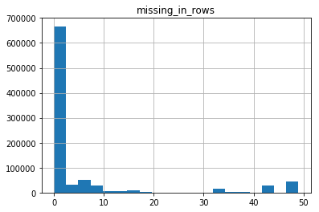

```python
rows_mis.hist(bins=20); #  rcParams["hist.bins"] (default: 10)
```

As visible from the missing-per-row data histogram above, by dividing dataset based on number of missings per row, data can be splitted into 2 subsets:

1) missing-per-row <= 20 values  
2) missing-per-row > 20 values

```python
# Write code to divide the data into two subsets based on the number of missing
# values in each row.

# Add a column to the AZDIAS demographics dataset showing number of missing values in each row

azdias2_r = azdias2.join(rows_mis)
display(azdias2_r.head(n=10))
```

|  | ALTERSKATEGORIE_GROB | ANREDE_KZ | CJT_GESAMTTYP | FINANZ_MINIMALIST | FINANZ_SPARER | FINANZ_VORSORGER | FINANZ_ANLEGER | FINANZ_UNAUFFAELLIGER | FINANZ_HAUSBAUER | FINANZTYP | GFK_URLAUBERTYP | GREEN_AVANTGARDE | HEALTH_TYP | LP_LEBENSPHASE_FEIN | LP_LEBENSPHASE_GROB | LP_FAMILIE_FEIN | LP_FAMILIE_GROB | LP_STATUS_FEIN | LP_STATUS_GROB | NATIONALITAET_KZ | PRAEGENDE_JUGENDJAHRE | RETOURTYP_BK_S | SEMIO_SOZ | SEMIO_FAM | SEMIO_REL | SEMIO_MAT | SEMIO_VERT | SEMIO_LUST | SEMIO_ERL | … |
| --- | --- | --- | --- | --- | --- | --- | --- | --- | --- | --- | --- | --- | --- | --- | --- | --- | --- | --- | --- | --- | --- | --- | --- | --- | --- | --- | --- | --- | --- | --- |
| 0 | 2.0 | 1 | 2.0 | 3 | 4 | 3 | 5 | 5 | 3 | 4 | 10.0 | 0 | NaN | 15.0 | 4.0 | 2.0 | 2.0 | 1.0 | 1.0 | NaN | NaN | 5.0 | 2 | 6 | 7 | 5 | 1 | 5 | 3 | … |
| 1 | 1.0 | 2 | 5.0 | 1 | 5 | 2 | 5 | 4 | 5 | 1 | 10.0 | 0 | 3.0 | 21.0 | 6.0 | 5.0 | 3.0 | 2.0 | 1.0 | 1.0 | 14.0 | 1.0 | 5 | 4 | 4 | 3 | 1 | 2 | 2 | … |
| 2 | 3.0 | 2 | 3.0 | 1 | 4 | 1 | 2 | 3 | 5 | 1 | 10.0 | 1 | 3.0 | 3.0 | 1.0 | 1.0 | 1.0 | 3.0 | 2.0 | 1.0 | 15.0 | 3.0 | 4 | 1 | 3 | 3 | 4 | 4 | 6 | … |
| 3 | 4.0 | 2 | 2.0 | 4 | 2 | 5 | 2 | 1 | 2 | 6 | 1.0 | 0 | 2.0 | NaN | NaN | NaN | NaN | 9.0 | 4.0 | 1.0 | 8.0 | 2.0 | 5 | 1 | 2 | 1 | 4 | 4 | 7 | … |
| 4 | 3.0 | 1 | 5.0 | 4 | 3 | 4 | 1 | 3 | 2 | 5 | 5.0 | 0 | 3.0 | 32.0 | 10.0 | 10.0 | 5.0 | 3.0 | 2.0 | 1.0 | 8.0 | 5.0 | 6 | 4 | 4 | 2 | 7 | 4 | 4 | … |
| 5 | 1.0 | 2 | 2.0 | 3 | 1 | 5 | 2 | 2 | 5 | 2 | 1.0 | 0 | 3.0 | 8.0 | 2.0 | 1.0 | 1.0 | 4.0 | 2.0 | 1.0 | 3.0 | 3.0 | 2 | 4 | 7 | 4 | 2 | 2 | 2 | … |
| 6 | 2.0 | 2 | 5.0 | 1 | 5 | 1 | 5 | 4 | 3 | 4 | 12.0 | 0 | 2.0 | 2.0 | 1.0 | 1.0 | 1.0 | 2.0 | 1.0 | 1.0 | 10.0 | 4.0 | 2 | 5 | 5 | 7 | 2 | 6 | 5 | … |
| 7 | 1.0 | 1 | 3.0 | 3 | 3 | 4 | 1 | 3 | 2 | 5 | 9.0 | 0 | 1.0 | 5.0 | 2.0 | 1.0 | 1.0 | 1.0 | 1.0 | 1.0 | 8.0 | 5.0 | 7 | 7 | 7 | 5 | 6 | 2 | 2 | … |
| 8 | 3.0 | 1 | 3.0 | 4 | 4 | 2 | 4 | 2 | 2 | 6 | 3.0 | 1 | 3.0 | 10.0 | 3.0 | 1.0 | 1.0 | 10.0 | 5.0 | 1.0 | 11.0 | 4.0 | 4 | 5 | 4 | 1 | 5 | 6 | 4 | … |
| 9 | 3.0 | 2 | 4.0 | 2 | 4 | 2 | 3 | 5 | 4 | 1 | 12.0 | 1 | 2.0 | 4.0 | 1.0 | 1.0 | 1.0 | 3.0 | 2.0 | 1.0 | 15.0 | 4.0 | 2 | 1 | 1 | 3 | 2 | 6 | 6 | … |

```python
azdias2_r_nomissing = azdias2_r[azdias2_r['missing_in_rows']==0]
print("azdias no-missing-rows dimensions: ", azdias2_r_nomissing.shape)
print("azdias dimensions: ", azdias.shape)
percentage_missing_rows = (azdias2_r_nomissing.shape[0] / azdias.shape[0]) * 100
print("azdias missing rows percentage: {}%".format(round(percentage_missing_rows, 2)))
```

```
azdias no-missing-rows dimensions:  (623209, 80)
azdias dimensions:  (891221, 85)
azdias missing rows percentage: 69.93%
```

```python
azdias2_r_le20 = azdias2_r[azdias2_r['missing_in_rows']<=20]
azdias2_r_g20 = azdias2_r[azdias2_r['missing_in_rows']>20]
```

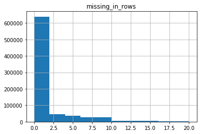

```python
# histogram with number of missing values <=20
azdias2_r_le20.hist(column='missing_in_rows');
```

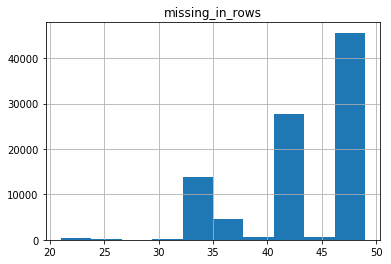

```python
# histogram with number of missing values >20
azdias2_r_g20.hist(column='missing_in_rows');
```

```python
def compare_per_col(row_few_missing_df, row_many_missing_df, col):

    fig, ax = plt.subplots(1, 2, figsize=(14, 6)) # default value is [8.0, 6.0]
    sns.countplot(row_few_missing_df[col], ax=ax[0]).set(title='Few or no missing values')
    sns.countplot(row_many_missing_df[col], ax=ax[1]).set(title='Many missing values')
    plt.subplots_adjust(wspace=1)
    fig.show()
    return

# Create a bar plot visualization
# fig, ax = plt.subplots(figsize = (14,8))
```

```
Length of azdias_missing_percent < 10%:  39
```

|  | azdias_missing_percent |
| --- | --- |
| LP_FAMILIE_FEIN | 8.728699 |
| LP_FAMILIE_GROB | 8.728699 |
| KONSUMNAEHE | 8.299737 |
| WOHNDAUER_2008 | 8.247000 |
| ANZ_TITEL | 8.247000 |
| ANZ_PERSONEN | 8.247000 |
| SOHO_KZ | 8.247000 |
| HH_EINKOMMEN_SCORE | 2.058749 |
| ONLINE_AFFINITAET | 0.544646 |
| LP_STATUS_FEIN | 0.544646 |
| CJT_GESAMTTYP | 0.544646 |
| RETOURTYP_BK_S | 0.544646 |
| GFK_URLAUBERTYP | 0.544646 |
| LP_STATUS_GROB | 0.544646 |
| ALTERSKATEGORIE_GROB | 0.323264 |
| GREEN_AVANTGARDE | 0.000000 |
| FINANZTYP | 0.000000 |
| FINANZ_MINIMALIST | 0.000000 |
| FINANZ_SPARER | 0.000000 |
| FINANZ_VORSORGER | 0.000000 |
| FINANZ_ANLEGER | 0.000000 |
| FINANZ_UNAUFFAELLIGER | 0.000000 |
| ZABEOTYP | 0.000000 |
| FINANZ_HAUSBAUER | 0.000000 |
| SEMIO_TRADV | 0.000000 |
| SEMIO_PFLICHT | 0.000000 |
| SEMIO_KAEM | 0.000000 |
| SEMIO_DOM | 0.000000 |
| SEMIO_KRIT | 0.000000 |
| SEMIO_RAT | 0.000000 |
| SEMIO_KULT | 0.000000 |
| SEMIO_ERL | 0.000000 |
| SEMIO_LUST | 0.000000 |
| SEMIO_VERT | 0.000000 |
| SEMIO_MAT | 0.000000 |
| ANREDE_KZ | 0.000000 |
| SEMIO_FAM | 0.000000 |
| SEMIO_SOZ | 0.000000 |
| SEMIO_REL | 0.000000 |

```
<function matplotlib.pyplot.show(*args, **kw)>
```

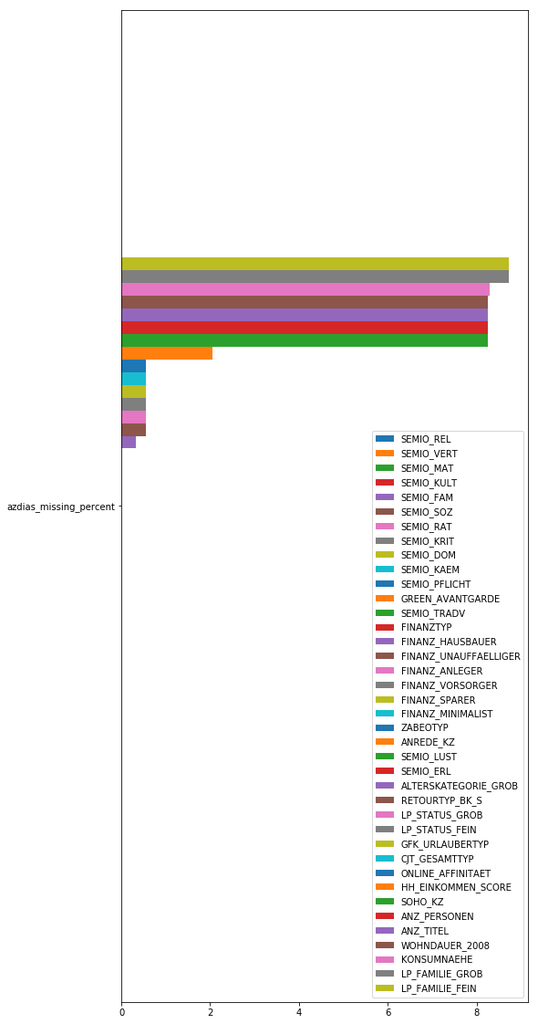

```python
# Filter features no or few missing values (<10%)

azdias_missing_percent_l10_df = azdias_missing_percent_df[azdias_missing_percent_df['azdias_missing_percent'] < 10.0]
azdias_missing_percent_l10_sorted_df = azdias_missing_percent_l10_df.sort_values(by=['azdias_missing_percent'], inplace=False, ascending=False)

print("Length of azdias_missing_percent < 10%: ", len(azdias_missing_percent_l10_sorted_df))
display(azdias_missing_percent_l10_sorted_df)

azdias_missing_percent_l10_sorted_asc_df = azdias_missing_percent_l10_df.sort_values(by=['azdias_missing_percent'], inplace=False, ascending=True)
azdias_missing_percent_l10_sorted_asc_tr_df = azdias_missing_percent_l10_sorted_asc_df.transpose()
azdias_missing_percent_l10_sorted_asc_tr_df.plot(kind='barh', figsize = (8,20))
plt.show
```

```python
letters = ['a', 'b', 'c', 'd', 'e', 'f']
random_index = random.randint(0, len(letters)-1)

print(letters[random_index])
```

```
d
```

```python
# Filter features no or few missing values (<1%)
azdias_missing_percent_l1_df = azdias_missing_percent_df[azdias_missing_percent_df['azdias_missing_percent'] < 1.0]
azdias_missing_percent_l1_sorted_df = azdias_missing_percent_l1_df.sort_values(by=['azdias_missing_percent'], inplace=False, ascending=False)
# display(azdias_missing_percent_l1_sorted_df)

azdias_missing_percent_l1_sorted_tr_df = azdias_missing_percent_l1_sorted_df.transpose()
few_no_missing_cols = azdias_missing_percent_l1_sorted_tr_df.columns.values.tolist()
print("length of few_no_missing_cols(<1%): ", len(few_no_missing_cols))
few_no_missing_cols
```

```
length of few_no_missing_cols(<1%):  31
```

```
['ONLINE_AFFINITAET',
 'GFK_URLAUBERTYP',
 'CJT_GESAMTTYP',
 'RETOURTYP_BK_S',
 'LP_STATUS_GROB',
 'LP_STATUS_FEIN',
 'ALTERSKATEGORIE_GROB',
 'FINANZ_UNAUFFAELLIGER',
 'FINANZ_HAUSBAUER',
 'ZABEOTYP',
 'SEMIO_TRADV',
 'SEMIO_PFLICHT',
 'SEMIO_KAEM',
 'SEMIO_DOM',
 'SEMIO_KRIT',
 'SEMIO_RAT',
 'SEMIO_KULT',
 'SEMIO_ERL',
 'SEMIO_LUST',
 'SEMIO_VERT',
 'SEMIO_MAT',
 'SEMIO_REL',
 'SEMIO_FAM',
 'ANREDE_KZ',
 'FINANZ_MINIMALIST',
 'FINANZ_SPARER',
 'FINANZ_VORSORGER',
 'GREEN_AVANTGARDE',
 'FINANZ_ANLEGER',
 'FINANZTYP',
 'SEMIO_SOZ']
```

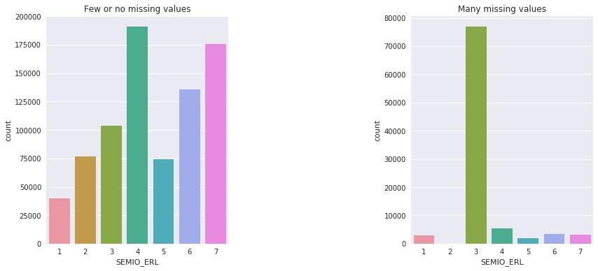

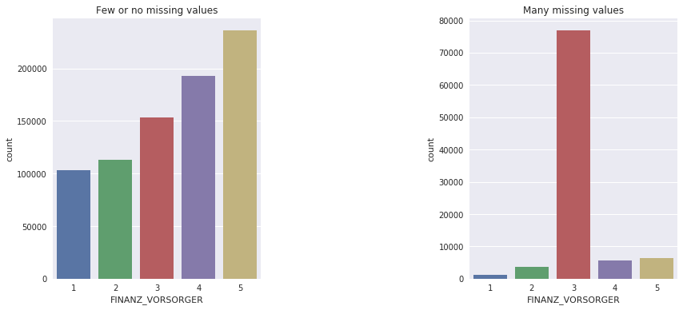

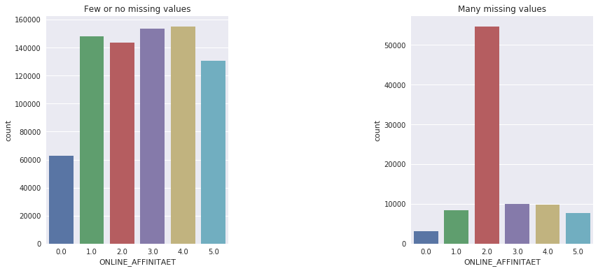

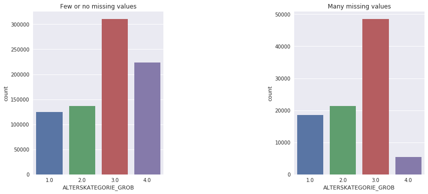

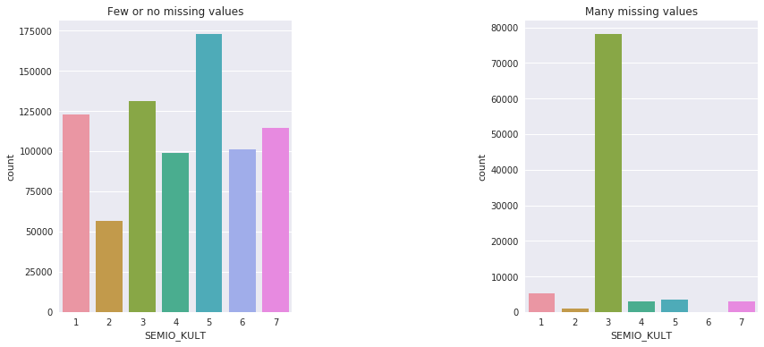

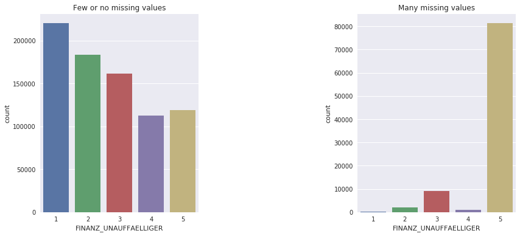

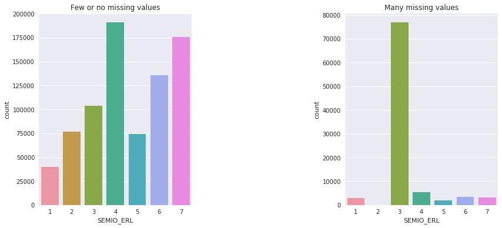

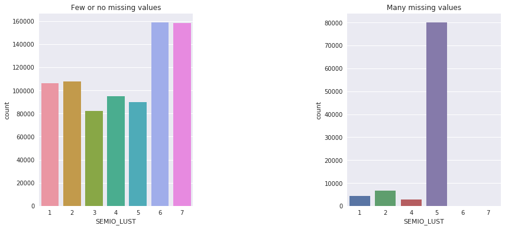

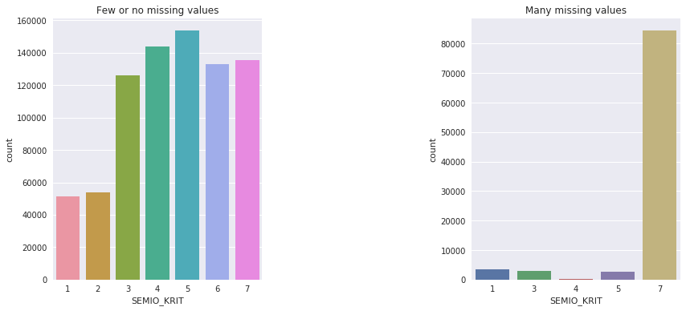

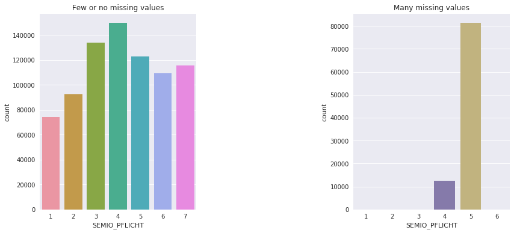

```python
# Compare the distribution of values for at least five columns where there are
# no or few missing values, between the two subsets.

sns.set(style="darkgrid")
for i in range(10):
    random_index = random.randint(0, len(few_no_missing_cols)-1)
    compare_per_col(azdias2_r_le20, azdias2_r_g20, few_no_missing_cols[random_index])


# compare_per_col(azdias2_r_le20, azdias2_r_g20, 'ALTERSKATEGORIE_GROB')
```

```python
# dropping rows that contains > 10 missing values
azdias3 = azdias2_r[azdias2_r['missing_in_rows']<=10]

azdias3 = azdias3.drop('missing_in_rows', axis = 1)

print("AZDIAS size after dropping missing_in_rows>10: " , azdias3.shape)
display(azdias3.head(n=10))
```

```
AZDIAS size after dropping missing_in_rows>10:  (780153, 79)
```

|  | ALTERSKATEGORIE_GROB | ANREDE_KZ | CJT_GESAMTTYP | FINANZ_MINIMALIST | FINANZ_SPARER | FINANZ_VORSORGER | FINANZ_ANLEGER | FINANZ_UNAUFFAELLIGER | FINANZ_HAUSBAUER | FINANZTYP | GFK_URLAUBERTYP | GREEN_AVANTGARDE | HEALTH_TYP | LP_LEBENSPHASE_FEIN | LP_LEBENSPHASE_GROB | LP_FAMILIE_FEIN | LP_FAMILIE_GROB | LP_STATUS_FEIN | LP_STATUS_GROB | NATIONALITAET_KZ | PRAEGENDE_JUGENDJAHRE | RETOURTYP_BK_S | SEMIO_SOZ | SEMIO_FAM | SEMIO_REL | SEMIO_MAT | SEMIO_VERT | SEMIO_LUST | SEMIO_ERL | … |
| --- | --- | --- | --- | --- | --- | --- | --- | --- | --- | --- | --- | --- | --- | --- | --- | --- | --- | --- | --- | --- | --- | --- | --- | --- | --- | --- | --- | --- | --- | --- |
| 1 | 1.0 | 2 | 5.0 | 1 | 5 | 2 | 5 | 4 | 5 | 1 | 10.0 | 0 | 3.0 | 21.0 | 6.0 | 5.0 | 3.0 | 2.0 | 1.0 | 1.0 | 14.0 | 1.0 | 5 | 4 | 4 | 3 | 1 | 2 | 2 | … |
| 2 | 3.0 | 2 | 3.0 | 1 | 4 | 1 | 2 | 3 | 5 | 1 | 10.0 | 1 | 3.0 | 3.0 | 1.0 | 1.0 | 1.0 | 3.0 | 2.0 | 1.0 | 15.0 | 3.0 | 4 | 1 | 3 | 3 | 4 | 4 | 6 | … |
| 3 | 4.0 | 2 | 2.0 | 4 | 2 | 5 | 2 | 1 | 2 | 6 | 1.0 | 0 | 2.0 | NaN | NaN | NaN | NaN | 9.0 | 4.0 | 1.0 | 8.0 | 2.0 | 5 | 1 | 2 | 1 | 4 | 4 | 7 | … |
| 4 | 3.0 | 1 | 5.0 | 4 | 3 | 4 | 1 | 3 | 2 | 5 | 5.0 | 0 | 3.0 | 32.0 | 10.0 | 10.0 | 5.0 | 3.0 | 2.0 | 1.0 | 8.0 | 5.0 | 6 | 4 | 4 | 2 | 7 | 4 | 4 | … |
| 5 | 1.0 | 2 | 2.0 | 3 | 1 | 5 | 2 | 2 | 5 | 2 | 1.0 | 0 | 3.0 | 8.0 | 2.0 | 1.0 | 1.0 | 4.0 | 2.0 | 1.0 | 3.0 | 3.0 | 2 | 4 | 7 | 4 | 2 | 2 | 2 | … |
| 6 | 2.0 | 2 | 5.0 | 1 | 5 | 1 | 5 | 4 | 3 | 4 | 12.0 | 0 | 2.0 | 2.0 | 1.0 | 1.0 | 1.0 | 2.0 | 1.0 | 1.0 | 10.0 | 4.0 | 2 | 5 | 5 | 7 | 2 | 6 | 5 | … |
| 7 | 1.0 | 1 | 3.0 | 3 | 3 | 4 | 1 | 3 | 2 | 5 | 9.0 | 0 | 1.0 | 5.0 | 2.0 | 1.0 | 1.0 | 1.0 | 1.0 | 1.0 | 8.0 | 5.0 | 7 | 7 | 7 | 5 | 6 | 2 | 2 | … |
| 8 | 3.0 | 1 | 3.0 | 4 | 4 | 2 | 4 | 2 | 2 | 6 | 3.0 | 1 | 3.0 | 10.0 | 3.0 | 1.0 | 1.0 | 10.0 | 5.0 | 1.0 | 11.0 | 4.0 | 4 | 5 | 4 | 1 | 5 | 6 | 4 | … |
| 9 | 3.0 | 2 | 4.0 | 2 | 4 | 2 | 3 | 5 | 4 | 1 | 12.0 | 1 | 2.0 | 4.0 | 1.0 | 1.0 | 1.0 | 3.0 | 2.0 | 1.0 | 15.0 | 4.0 | 2 | 1 | 1 | 3 | 2 | 6 | 6 | … |
| 10 | 3.0 | 2 | 1.0 | 2 | 2 | 5 | 3 | 1 | 5 | 6 | 8.0 | 0 | 2.0 | 6.0 | 2.0 | 1.0 | 1.0 | 1.0 | 1.0 | 1.0 | 3.0 | 5.0 | 5 | 2 | 3 | 5 | 5 | 6 | 6 | … |

```python
display(azdias3.head(n=10))
```

|  | ALTERSKATEGORIE_GROB | ANREDE_KZ | CJT_GESAMTTYP | FINANZ_MINIMALIST | FINANZ_SPARER | FINANZ_VORSORGER | FINANZ_ANLEGER | FINANZ_UNAUFFAELLIGER | FINANZ_HAUSBAUER | FINANZTYP | GFK_URLAUBERTYP | GREEN_AVANTGARDE | HEALTH_TYP | LP_LEBENSPHASE_FEIN | LP_LEBENSPHASE_GROB | LP_FAMILIE_FEIN | LP_FAMILIE_GROB | LP_STATUS_FEIN | LP_STATUS_GROB | NATIONALITAET_KZ | PRAEGENDE_JUGENDJAHRE | RETOURTYP_BK_S | SEMIO_SOZ | SEMIO_FAM | SEMIO_REL | SEMIO_MAT | SEMIO_VERT | SEMIO_LUST | SEMIO_ERL | … |
| --- | --- | --- | --- | --- | --- | --- | --- | --- | --- | --- | --- | --- | --- | --- | --- | --- | --- | --- | --- | --- | --- | --- | --- | --- | --- | --- | --- | --- | --- | --- |
| 1 | 1.0 | 2 | 5.0 | 1 | 5 | 2 | 5 | 4 | 5 | 1 | 10.0 | 0 | 3.0 | 21.0 | 6.0 | 5.0 | 3.0 | 2.0 | 1.0 | 1.0 | 14.0 | 1.0 | 5 | 4 | 4 | 3 | 1 | 2 | 2 | … |
| 2 | 3.0 | 2 | 3.0 | 1 | 4 | 1 | 2 | 3 | 5 | 1 | 10.0 | 1 | 3.0 | 3.0 | 1.0 | 1.0 | 1.0 | 3.0 | 2.0 | 1.0 | 15.0 | 3.0 | 4 | 1 | 3 | 3 | 4 | 4 | 6 | … |
| 3 | 4.0 | 2 | 2.0 | 4 | 2 | 5 | 2 | 1 | 2 | 6 | 1.0 | 0 | 2.0 | NaN | NaN | NaN | NaN | 9.0 | 4.0 | 1.0 | 8.0 | 2.0 | 5 | 1 | 2 | 1 | 4 | 4 | 7 | … |
| 4 | 3.0 | 1 | 5.0 | 4 | 3 | 4 | 1 | 3 | 2 | 5 | 5.0 | 0 | 3.0 | 32.0 | 10.0 | 10.0 | 5.0 | 3.0 | 2.0 | 1.0 | 8.0 | 5.0 | 6 | 4 | 4 | 2 | 7 | 4 | 4 | … |
| 5 | 1.0 | 2 | 2.0 | 3 | 1 | 5 | 2 | 2 | 5 | 2 | 1.0 | 0 | 3.0 | 8.0 | 2.0 | 1.0 | 1.0 | 4.0 | 2.0 | 1.0 | 3.0 | 3.0 | 2 | 4 | 7 | 4 | 2 | 2 | 2 | … |
| 6 | 2.0 | 2 | 5.0 | 1 | 5 | 1 | 5 | 4 | 3 | 4 | 12.0 | 0 | 2.0 | 2.0 | 1.0 | 1.0 | 1.0 | 2.0 | 1.0 | 1.0 | 10.0 | 4.0 | 2 | 5 | 5 | 7 | 2 | 6 | 5 | … |
| 7 | 1.0 | 1 | 3.0 | 3 | 3 | 4 | 1 | 3 | 2 | 5 | 9.0 | 0 | 1.0 | 5.0 | 2.0 | 1.0 | 1.0 | 1.0 | 1.0 | 1.0 | 8.0 | 5.0 | 7 | 7 | 7 | 5 | 6 | 2 | 2 | … |
| 8 | 3.0 | 1 | 3.0 | 4 | 4 | 2 | 4 | 2 | 2 | 6 | 3.0 | 1 | 3.0 | 10.0 | 3.0 | 1.0 | 1.0 | 10.0 | 5.0 | 1.0 | 11.0 | 4.0 | 4 | 5 | 4 | 1 | 5 | 6 | 4 | … |
| 9 | 3.0 | 2 | 4.0 | 2 | 4 | 2 | 3 | 5 | 4 | 1 | 12.0 | 1 | 2.0 | 4.0 | 1.0 | 1.0 | 1.0 | 3.0 | 2.0 | 1.0 | 15.0 | 4.0 | 2 | 1 | 1 | 3 | 2 | 6 | 6 | … |
| 10 | 3.0 | 2 | 1.0 | 2 | 2 | 5 | 3 | 1 | 5 | 6 | 8.0 | 0 | 2.0 | 6.0 | 2.0 | 1.0 | 1.0 | 1.0 | 1.0 | 1.0 | 3.0 | 5.0 | 5 | 2 | 3 | 5 | 5 | 6 | 6 | … |

#### Discussion 1.1.3: Assess Missing Data in Each Row

`Question: Are the data with lots of missing values are qualitatively different from data with few or no missing values?)`

Based on the results of the missing-per-row data histogram, I splitted AZDIAS dataset based on the number of missings per row into 2 subsets:

1) missing-per-row <= 20 values  
2) missing-per-row > 20 values

where according to the histogram the majority of rows miss values <= 20.

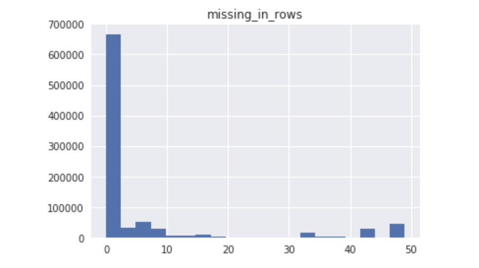

As seen in the preceding statement, I plotted distributions of the non-missing features for comparison between the data with many missing values (>20) and the data with few/no missing values (<=20). Here are some of the findings to illustrate my points.

I qualitatively compare the resultant distribution curves (compare the relative heights of the corresponding bars in each plot to see if they follow the same pattern) between the 2 subsets after splitting, and if they follow the same pattern, it is safe to drop the subset with many missing vales altogether from the analysis, and keep both subsets otherwise.

[figure not shown]

In contrast, in case of `RETOURTYP_BK_S` feature, the distributions of data values between the 2 subsets follow different patterns. In simpler words, relative heights of the corresponding categories are not the same (For instance highest bar is in different category between the 2 subsets). Hence, in this case we make a note on these data as special and revisit such data later on.

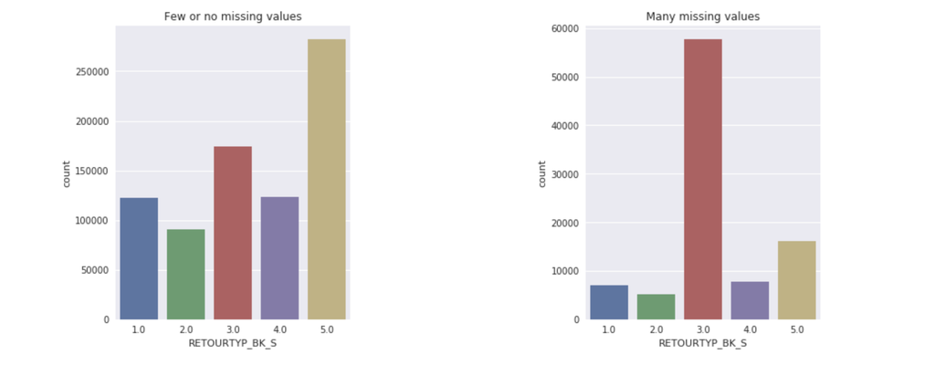

Either way, I continue my analysis for now using just the subset of the data with few or no missing values.

As per the histogram visualization, the range of [10 30] looks suitable for splitting the AZDIAS data based on the missing values across the rows.

To be more on the conservative side, I have decided that only rows with missing values <=10 will be furtherly used in the analysis as more than that thresold might bring false result and bias, since anyhow missing values should be imputed with other values not from the original data source.

### Step 1.2: Select and Re-Encode Features

Checking for missing data isn't the only way in which you can prepare a dataset for analysis. Since the unsupervised learning techniques to be used will only work on data that is encoded numerically, you need to make a few encoding changes or additional assumptions to be able to make progress. In addition, while almost all of the values in the dataset are encoded using numbers, not all of them represent numeric values. Check the third column of the feature summary (`feat_info`) for a summary of types of measurement.

- For numeric and interval data, these features can be kept without changes.
- Most of the variables in the dataset are ordinal in nature. While ordinal values may technically be non-linear in spacing, make the simplifying assumption that the ordinal variables can be treated as being interval in nature (that is, kept without any changes).
- Special handling may be necessary for the remaining two variable types: categorical, and 'mixed'.

In the first two parts of this sub-step, you will perform an investigation of the categorical and mixed-type features and make a decision on each of them, whether you will keep, drop, or re-encode each. Then, in the last part, you will create a new data frame with only the selected and engineered columns.

Data wrangling is often the trickiest part of the data analysis process, and there's a lot of it to be done here. But stick with it: once you're done with this step, you'll be ready to get to the machine learning parts of the project!

```python
feat_info2
```

|  | attribute | information_level | type | missing_or_unknown |
| --- | --- | --- | --- | --- |
| 1 | ALTERSKATEGORIE_GROB | person | ordinal | [-1,0,9] |
| 2 | ANREDE_KZ | person | categorical | [-1,0] |
| 3 | CJT_GESAMTTYP | person | categorical | [0] |
| 4 | FINANZ_MINIMALIST | person | ordinal | [-1] |
| 5 | FINANZ_SPARER | person | ordinal | [-1] |
| 6 | FINANZ_VORSORGER | person | ordinal | [-1] |
| 7 | FINANZ_ANLEGER | person | ordinal | [-1] |
| 8 | FINANZ_UNAUFFAELLIGER | person | ordinal | [-1] |
| 9 | FINANZ_HAUSBAUER | person | ordinal | [-1] |
| 10 | FINANZTYP | person | categorical | [-1] |
| 12 | GFK_URLAUBERTYP | person | categorical | [] |
| 13 | GREEN_AVANTGARDE | person | categorical | [] |
| 14 | HEALTH_TYP | person | ordinal | [-1,0] |
| 15 | LP_LEBENSPHASE_FEIN | person | mixed | [0] |
| 16 | LP_LEBENSPHASE_GROB | person | mixed | [0] |
| 17 | LP_FAMILIE_FEIN | person | categorical | [0] |
| 18 | LP_FAMILIE_GROB | person | categorical | [0] |
| 19 | LP_STATUS_FEIN | person | categorical | [0] |
| 20 | LP_STATUS_GROB | person | categorical | [0] |
| 21 | NATIONALITAET_KZ | person | categorical | [-1,0] |
| 22 | PRAEGENDE_JUGENDJAHRE | person | mixed | [-1,0] |
| 23 | RETOURTYP_BK_S | person | ordinal | [0] |
| 24 | SEMIO_SOZ | person | ordinal | [-1,9] |
| 25 | SEMIO_FAM | person | ordinal | [-1,9] |
| 26 | SEMIO_REL | person | ordinal | [-1,9] |
| 27 | SEMIO_MAT | person | ordinal | [-1,9] |
| 28 | SEMIO_VERT | person | ordinal | [-1,9] |
| 29 | SEMIO_LUST | person | ordinal | [-1,9] |
| 30 | SEMIO_ERL | person | ordinal | [-1,9] |
| 31 | SEMIO_KULT | person | ordinal | [-1,9] |
| 32 | SEMIO_RAT | person | ordinal | [-1,9] |
| 33 | SEMIO_KRIT | person | ordinal | [-1,9] |
| 34 | SEMIO_DOM | person | ordinal | [-1,9] |
| 35 | SEMIO_KAEM | person | ordinal | [-1,9] |
| 36 | SEMIO_PFLICHT | person | ordinal | [-1,9] |
| 37 | SEMIO_TRADV | person | ordinal | [-1,9] |
| 38 | SHOPPER_TYP | person | categorical | [-1] |
| 39 | SOHO_KZ | person | categorical | [-1] |
| 41 | VERS_TYP | person | categorical | [-1] |
| 42 | ZABEOTYP | person | categorical | [-1,9] |
| 44 | ANZ_PERSONEN | household | numeric | [] |
| 45 | ANZ_TITEL | household | numeric | [] |
| 46 | HH_EINKOMMEN_SCORE | household | ordinal | [-1,0] |
| 48 | W_KEIT_KIND_HH | household | ordinal | [-1,0] |
| 49 | WOHNDAUER_2008 | household | ordinal | [-1,0] |
| 50 | ANZ_HAUSHALTE_AKTIV | building | numeric | [0] |
| 51 | ANZ_HH_TITEL | building | numeric | [] |
| 52 | GEBAEUDETYP | building | categorical | [-1,0] |
| 53 | KONSUMNAEHE | building | ordinal | [] |
| 54 | MIN_GEBAEUDEJAHR | building | numeric | [0] |
| 55 | OST_WEST_KZ | building | categorical | [-1] |
| 56 | WOHNLAGE | building | mixed | [-1] |
| 57 | CAMEO_DEUG_2015 | microcell_rr4 | categorical | [-1,X] |
| 58 | CAMEO_DEU_2015 | microcell_rr4 | categorical | [XX] |
| 59 | CAMEO_INTL_2015 | microcell_rr4 | mixed | [-1,XX] |
| 60 | KBA05_ANTG1 | microcell_rr3 | ordinal | [-1] |
| 61 | KBA05_ANTG2 | microcell_rr3 | ordinal | [-1] |
| 62 | KBA05_ANTG3 | microcell_rr3 | ordinal | [-1] |
| 63 | KBA05_ANTG4 | microcell_rr3 | ordinal | [-1] |
| 65 | KBA05_GBZ | microcell_rr3 | ordinal | [-1,0] |
| 66 | BALLRAUM | postcode | ordinal | [-1] |
| 67 | EWDICHTE | postcode | ordinal | [-1] |
| 68 | INNENSTADT | postcode | ordinal | [-1] |
| 69 | GEBAEUDETYP_RASTER | region_rr1 | ordinal | [] |
| 70 | KKK | region_rr1 | ordinal | [-1,0] |
| 71 | MOBI_REGIO | region_rr1 | ordinal | [] |
| 72 | ONLINE_AFFINITAET | region_rr1 | ordinal | [] |
| 73 | REGIOTYP | region_rr1 | ordinal | [-1,0] |
| 74 | KBA13_ANZAHL_PKW | macrocell_plz8 | numeric | [] |
| 75 | PLZ8_ANTG1 | macrocell_plz8 | ordinal | [-1] |
| 76 | PLZ8_ANTG2 | macrocell_plz8 | ordinal | [-1] |
| 77 | PLZ8_ANTG3 | macrocell_plz8 | ordinal | [-1] |
| 78 | PLZ8_ANTG4 | macrocell_plz8 | ordinal | [-1] |
| 79 | PLZ8_BAUMAX | macrocell_plz8 | mixed | [-1,0] |
| 80 | PLZ8_HHZ | macrocell_plz8 | ordinal | [-1] |
| 81 | PLZ8_GBZ | macrocell_plz8 | ordinal | [-1] |
| 82 | ARBEIT | community | ordinal | [-1,9] |
| 83 | ORTSGR_KLS9 | community | ordinal | [-1,0] |
| 84 | RELAT_AB | community | ordinal | [-1,9] |

```python
# How many features are there of each data type?

num_feat = feat_info2.type.value_counts()
display(num_feat)
```

```
ordinal        49
categorical    18
numeric         6
mixed           6
Name: type, dtype: int64
```

As visible above, there are 18 categorical features!

#### Step 1.2.1: Re-Encode Categorical Features

For categorical data, you would ordinarily need to encode the levels as dummy variables. Depending on the number of categories, perform one of the following:

- For binary (two-level) categoricals that take numeric values, you can keep them without needing to do anything.
- There is one binary variable that takes on non-numeric values. For this one, you need to re-encode the values as numbers or create a dummy variable.
- For multi-level categoricals (three or more values), you can choose to encode the values using multiple dummy variables (e.g. via [OneHotEncoder](http://scikit-learn.org/stable/modules/generated/sklearn.preprocessing.OneHotEncoder.html)), or (to keep things straightforward) just drop them from the analysis. As always, document your choices in the Discussion section.

```python
# Assess categorical variables: which are binary, which are multi-level, and
# which one needs to be re-encoded?

cat_feat = feat_info2[feat_info2['type']=='categorical']
display(cat_feat)
```

|  | attribute | information_level | type | missing_or_unknown |
| --- | --- | --- | --- | --- |
| 2 | ANREDE_KZ | person | categorical | [-1,0] |
| 3 | CJT_GESAMTTYP | person | categorical | [0] |
| 10 | FINANZTYP | person | categorical | [-1] |
| 12 | GFK_URLAUBERTYP | person | categorical | [] |
| 13 | GREEN_AVANTGARDE | person | categorical | [] |
| 17 | LP_FAMILIE_FEIN | person | categorical | [0] |
| 18 | LP_FAMILIE_GROB | person | categorical | [0] |
| 19 | LP_STATUS_FEIN | person | categorical | [0] |
| 20 | LP_STATUS_GROB | person | categorical | [0] |
| 21 | NATIONALITAET_KZ | person | categorical | [-1,0] |
| 38 | SHOPPER_TYP | person | categorical | [-1] |
| 39 | SOHO_KZ | person | categorical | [-1] |
| 41 | VERS_TYP | person | categorical | [-1] |
| 42 | ZABEOTYP | person | categorical | [-1,9] |
| 52 | GEBAEUDETYP | building | categorical | [-1,0] |
| 55 | OST_WEST_KZ | building | categorical | [-1] |
| 57 | CAMEO_DEUG_2015 | microcell_rr4 | categorical | [-1,X] |
| 58 | CAMEO_DEU_2015 | microcell_rr4 | categorical | [XX] |

```python
cat_feat.info()
```

```
<class 'pandas.core.frame.DataFrame'>
Int64Index: 18 entries, 2 to 58
Data columns (total 4 columns):
attribute             18 non-null object
information_level     18 non-null object
type                  18 non-null object
missing_or_unknown    18 non-null object
dtypes: object(4)
memory usage: 720.0+ bytes
```

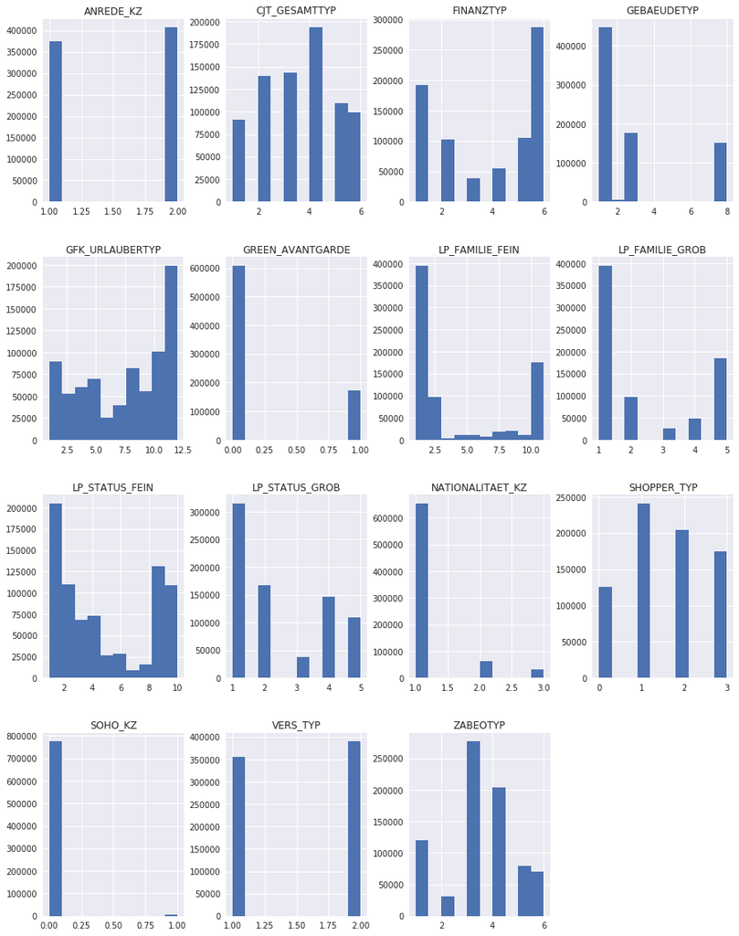

```python
# identifying numeric & non-numeric categorical features
# warnings.filterwarnings("ignore", category = UserWarning, module = "matplotlib")
fig = plt.figure(figsize=(15, 20))
ax = fig.gca()
azdias3[cat_feat['attribute']].hist(ax = ax);
```

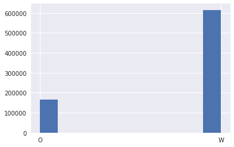

```python
# "OST_WEST_KZ" feature contains non-numeric categorical values
azdias3['OST_WEST_KZ'].hist();
```

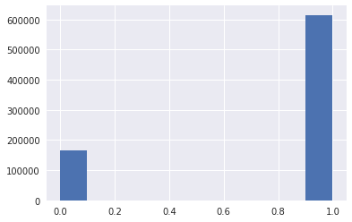

```python
# replacing str 'O' and 'W' with 0 and 1, respectively

azdias3.OST_WEST_KZ = azdias3.OST_WEST_KZ.replace({'O': 0.0,'W': 1.0})

# plot histogram
azdias3['OST_WEST_KZ'].hist();
```

```python
# filtering list of categorical features for one-hot encoding via pandas.get_dummies
multi_cat_list = []

for column in cat_feat['attribute']:
    # print(column) # feature name
    cat_unique_value = azdias3[column].unique() # returns list of unique values
    print(column, ": ", cat_unique_value)
    if cat_unique_value.size > 2: # we only need features containing more than 2 possible values
        multi_cat_list.append(column)
```

```
ANREDE_KZ :  [2 1]
CJT_GESAMTTYP :  [  5.   3.   2.   4.   1.   6.  nan]
FINANZTYP :  [1 6 5 2 4 3]
GFK_URLAUBERTYP :  [ 10.   1.   5.  12.   9.   3.   8.  11.   4.   7.   2.   6.  nan]
GREEN_AVANTGARDE :  [0 1]
LP_FAMILIE_FEIN :  [  5.   1.  nan  10.   2.   7.  11.   8.   4.   6.   9.   3.]
LP_FAMILIE_GROB :  [  3.   1.  nan   5.   2.   4.]
LP_STATUS_FEIN :  [  2.   3.   9.   4.   1.  10.   5.   8.   6.   7.  nan]
LP_STATUS_GROB :  [  1.   2.   4.   5.   3.  nan]
NATIONALITAET_KZ :  [  1.   3.   2.  nan]
SHOPPER_TYP :  [  3.   2.   1.   0.  nan]
SOHO_KZ :  [ 1.  0.]
VERS_TYP :  [  2.   1.  nan]
ZABEOTYP :  [5 3 4 1 6 2]
GEBAEUDETYP :  [ 8.  1.  3.  2.  6.  4.  5.]
OST_WEST_KZ :  [ 1.  0.]
CAMEO_DEUG_2015 :  ['8' '4' '2' '6' '1' '9' '5' '7' '3' nan]
CAMEO_DEU_2015 :  ['8A' '4C' '2A' '6B' '8C' '4A' '2D' '1A' '1E' '9D' '5C' '8B' '7A' '5D' '9E'
 '9B' '1B' '3D' nan '4E' '4B' '3C' '5A' '7B' '9A' '6D' '6E' '2C' '7C' '9C'
 '7D' '5E' '1D' '8D' '6C' '6A' '5B' '4D' '3A' '2B' '7E' '3B' '6F' '5F' '1C']
```

```python
# print(azdias3['OST_WEST_KZ'].unique().size)
print(multi_cat_list) # for these features we need to apply one-hot encoding via pandas.get_dummies
```

```
['CJT_GESAMTTYP', 'FINANZTYP', 'GFK_URLAUBERTYP', 'LP_FAMILIE_FEIN', 'LP_FAMILIE_GROB', 'LP_STATUS_FEIN', 'LP_STATUS_GROB', 'NATIONALITAET_KZ', 'SHOPPER_TYP', 'VERS_TYP', 'ZABEOTYP', 'GEBAEUDETYP', 'CAMEO_DEUG_2015', 'CAMEO_DEU_2015']
```

```python
# Re-encode categorical variable(s) to be kept in the analysis.

azdias4 = pd.get_dummies(azdias3, columns=multi_cat_list)
print(azdias4.shape)
display(list(azdias4.columns))
```

```
(780153, 195)
```

```
['ALTERSKATEGORIE_GROB',
 'ANREDE_KZ',
 'FINANZ_MINIMALIST',
 'FINANZ_SPARER',
 'FINANZ_VORSORGER',
 'FINANZ_ANLEGER',
 'FINANZ_UNAUFFAELLIGER',
 'FINANZ_HAUSBAUER',
 'GREEN_AVANTGARDE',
 'HEALTH_TYP',
 'LP_LEBENSPHASE_FEIN',
 'LP_LEBENSPHASE_GROB',
 'PRAEGENDE_JUGENDJAHRE',
 'RETOURTYP_BK_S',
 'SEMIO_SOZ',
 'SEMIO_FAM',
 'SEMIO_REL',
 'SEMIO_MAT',
 'SEMIO_VERT',
 'SEMIO_LUST',
 'SEMIO_ERL',
 'SEMIO_KULT',
 'SEMIO_RAT',
 'SEMIO_KRIT',
 'SEMIO_DOM',
 'SEMIO_KAEM',
 'SEMIO_PFLICHT',
 'SEMIO_TRADV',
 'SOHO_KZ',
 'ANZ_PERSONEN',
 'ANZ_TITEL',
 'HH_EINKOMMEN_SCORE',
 'W_KEIT_KIND_HH',
 'WOHNDAUER_2008',
 'ANZ_HAUSHALTE_AKTIV',
 'ANZ_HH_TITEL',
 'KONSUMNAEHE',
 'MIN_GEBAEUDEJAHR',
 'OST_WEST_KZ',
 'WOHNLAGE',
```

[output cut: 140 more lines]

```
 'CAMEO_DEU_2015_6F',
 'CAMEO_DEU_2015_7A',
 'CAMEO_DEU_2015_7B',
 'CAMEO_DEU_2015_7C',
 'CAMEO_DEU_2015_7D',
 'CAMEO_DEU_2015_7E',
 'CAMEO_DEU_2015_8A',
 'CAMEO_DEU_2015_8B',
 'CAMEO_DEU_2015_8C',
 'CAMEO_DEU_2015_8D',
 'CAMEO_DEU_2015_9A',
 'CAMEO_DEU_2015_9B',
 'CAMEO_DEU_2015_9C',
 'CAMEO_DEU_2015_9D',
 'CAMEO_DEU_2015_9E']
```

```python
display(azdias4.head(n=10))
```

|  | ALTERSKATEGORIE_GROB | ANREDE_KZ | FINANZ_MINIMALIST | FINANZ_SPARER | FINANZ_VORSORGER | FINANZ_ANLEGER | FINANZ_UNAUFFAELLIGER | FINANZ_HAUSBAUER | GREEN_AVANTGARDE | HEALTH_TYP | LP_LEBENSPHASE_FEIN | LP_LEBENSPHASE_GROB | PRAEGENDE_JUGENDJAHRE | RETOURTYP_BK_S | SEMIO_SOZ | SEMIO_FAM | SEMIO_REL | SEMIO_MAT | SEMIO_VERT | SEMIO_LUST | SEMIO_ERL | SEMIO_KULT | SEMIO_RAT | SEMIO_KRIT | SEMIO_DOM | SEMIO_KAEM | SEMIO_PFLICHT | SEMIO_TRADV | SOHO_KZ | … |
| --- | --- | --- | --- | --- | --- | --- | --- | --- | --- | --- | --- | --- | --- | --- | --- | --- | --- | --- | --- | --- | --- | --- | --- | --- | --- | --- | --- | --- | --- | --- |
| 1 | 1.0 | 2 | 1 | 5 | 2 | 5 | 4 | 5 | 0 | 3.0 | 21.0 | 6.0 | 14.0 | 1.0 | 5 | 4 | 4 | 3 | 1 | 2 | 2 | 3 | 6 | 4 | 7 | 4 | 7 | 6 | 1.0 | … |
| 2 | 3.0 | 2 | 1 | 4 | 1 | 2 | 3 | 5 | 1 | 3.0 | 3.0 | 1.0 | 15.0 | 3.0 | 4 | 1 | 3 | 3 | 4 | 4 | 6 | 3 | 4 | 7 | 7 | 7 | 3 | 3 | 0.0 | … |
| 3 | 4.0 | 2 | 4 | 2 | 5 | 2 | 1 | 2 | 0 | 2.0 | NaN | NaN | 8.0 | 2.0 | 5 | 1 | 2 | 1 | 4 | 4 | 7 | 4 | 3 | 4 | 4 | 5 | 4 | 4 | 0.0 | … |
| 4 | 3.0 | 1 | 4 | 3 | 4 | 1 | 3 | 2 | 0 | 3.0 | 32.0 | 10.0 | 8.0 | 5.0 | 6 | 4 | 4 | 2 | 7 | 4 | 4 | 6 | 2 | 3 | 2 | 2 | 4 | 2 | 0.0 | … |
| 5 | 1.0 | 2 | 3 | 1 | 5 | 2 | 2 | 5 | 0 | 3.0 | 8.0 | 2.0 | 3.0 | 3.0 | 2 | 4 | 7 | 4 | 2 | 2 | 2 | 5 | 7 | 4 | 4 | 4 | 7 | 6 | 0.0 | … |
| 6 | 2.0 | 2 | 1 | 5 | 1 | 5 | 4 | 3 | 0 | 2.0 | 2.0 | 1.0 | 10.0 | 4.0 | 2 | 5 | 5 | 7 | 2 | 6 | 5 | 5 | 7 | 7 | 4 | 7 | 7 | 7 | 0.0 | … |
| 7 | 1.0 | 1 | 3 | 3 | 4 | 1 | 3 | 2 | 0 | 1.0 | 5.0 | 2.0 | 8.0 | 5.0 | 7 | 7 | 7 | 5 | 6 | 2 | 2 | 7 | 5 | 1 | 1 | 2 | 5 | 5 | 0.0 | … |
| 8 | 3.0 | 1 | 4 | 4 | 2 | 4 | 2 | 2 | 1 | 3.0 | 10.0 | 3.0 | 11.0 | 4.0 | 4 | 5 | 4 | 1 | 5 | 6 | 4 | 5 | 2 | 5 | 5 | 3 | 1 | 4 | 0.0 | … |
| 9 | 3.0 | 2 | 2 | 4 | 2 | 3 | 5 | 4 | 1 | 2.0 | 4.0 | 1.0 | 15.0 | 4.0 | 2 | 1 | 1 | 3 | 2 | 6 | 6 | 3 | 4 | 7 | 6 | 7 | 1 | 3 | 0.0 | … |
| 10 | 3.0 | 2 | 2 | 2 | 5 | 3 | 1 | 5 | 0 | 2.0 | 6.0 | 2.0 | 3.0 | 5.0 | 5 | 2 | 3 | 5 | 5 | 6 | 6 | 1 | 4 | 7 | 4 | 7 | 5 | 3 | 0.0 | … |

#### Discussion 1.2.1: Re-Encode Categorical Features

`Question: Which ones did you keep, which did you drop, and what engineering steps did you perform?`

I keep binary categoricals of numeric type as is.  
For one binary variable of non-numeric type `OST_WEST_KZ`, I replaced `O` and `W` characters with numeric values of `0` and `1`, respectively.  
For multi-level categorical features (>2 levels), I have used `pandas.get_dummies` converter (Convert categorical variable into dummy/indicator variables) without dropping the features so as not to miss any potential highly-predictive variable.

#### Step 1.2.2: Engineer Mixed-Type Features

There are a handful of features that are marked as "mixed" in the feature summary that require special treatment in order to be included in the analysis. There are two in particular that deserve attention; the handling of the rest are up to your own choices:

- "PRAEGENDE_JUGENDJAHRE" combines information on three dimensions: generation by decade, movement (mainstream vs. avantgarde), and nation (east vs. west). While there aren't enough levels to disentangle east from west, you should create two new variables to capture the other two dimensions: an interval-type variable for decade, and a binary variable for movement.
- "CAMEO_INTL_2015" combines information on two axes: wealth and life stage. Break up the two-digit codes by their 'tens'-place and 'ones'-place digits into two new ordinal variables (which, for the purposes of this project, is equivalent to just treating them as their raw numeric values).
- If you decide to keep or engineer new features around the other mixed-type features, make sure you note your steps in the Discussion section.

Be sure to check `Data_Dictionary.md` for the details needed to finish these tasks.

```python
# 6 mixed type features

cat_feat_mix = feat_info2[feat_info2['type']=='mixed']
display(cat_feat_mix)
```

|  | attribute | information_level | type | missing_or_unknown |
| --- | --- | --- | --- | --- |
| 15 | LP_LEBENSPHASE_FEIN | person | mixed | [0] |
| 16 | LP_LEBENSPHASE_GROB | person | mixed | [0] |
| 22 | PRAEGENDE_JUGENDJAHRE | person | mixed | [-1,0] |
| 56 | WOHNLAGE | building | mixed | [-1] |
| 59 | CAMEO_INTL_2015 | microcell_rr4 | mixed | [-1,XX] |
| 79 | PLZ8_BAUMAX | macrocell_plz8 | mixed | [-1,0] |

```python
# review unique valies of mixed-type features

for column in cat_feat_mix['attribute']:
    mixed_cat_unique_value = azdias4[column].unique() # mixed type feature unique values
    print(column, ": ", mixed_cat_unique_value, "\n")
```

```
LP_LEBENSPHASE_FEIN :  [ 21.   3.  nan  32.   8.   2.   5.  10.   4.   6.  23.  12.  20.   1.  25.
  13.  18.  31.  38.  35.  30.   7.  22.  14.  29.  24.  28.  37.  26.  39.
  27.  36.   9.  34.  33.  15.  11.  40.  16.  19.  17.]

LP_LEBENSPHASE_GROB :  [  6.   1.  nan  10.   2.   3.   5.   7.  12.  11.   9.   4.   8.]

PRAEGENDE_JUGENDJAHRE :  [ 14.  15.   8.   3.  10.  11.   5.   9.   6.   4.  nan   2.   1.  12.  13.
   7.]

WOHNLAGE :  [ 4.  2.  7.  3.  5.  1.  8.  0.]

CAMEO_INTL_2015 :  ['51' '24' '12' '43' '54' '22' '14' '13' '15' '33' '41' '34' '55' '25' nan
 '23' '31' '52' '35' '45' '44' '32']

PLZ8_BAUMAX :  [  1.   2.  nan   4.   5.   3.]
```

```python
# Investigate "PRAEGENDE_JUGENDJAHRE" and engineer two new variables.

# Divide "PRAEGENDE_JUGENDJAHRE" into 2 variables:
# 1) an interval-type variable for decade: (40s, 50s, ..., 90s)
# 2) binary variable for movement: Avantgarde vs. Mainstream

# copy column "PRAEGENDE_JUGENDJAHRE" to 2 new columns:
# 1) PRAEGENDE_JUGENDJAHRE_DEC (Decades)
# 2) PRAEGENDE_JUGENDJAHRE_MOV (Avantgarde vs. Mainstream)

# Original PRAEGENDE_JUGENDJAHRE values will be dropped

azdias4['PRAEGENDE_JUGENDJAHRE_DEC'] = azdias4['PRAEGENDE_JUGENDJAHRE']
azdias4['PRAEGENDE_JUGENDJAHRE_MOV'] = azdias4['PRAEGENDE_JUGENDJAHRE']
```

```python
# Mapping PRAEGENDE_JUGENDJAHRE_DEC and PRAEGENDE_JUGENDJAHRE_MOV

dict_dec =  {1: 40.0, 2: 40.0,
             3: 50.0, 4: 50.0,
             5: 60.0, 6: 60.0, 7: 60.0,
             8: 70.0, 9: 70.0,
             10: 80.0, 11: 80.0, 12: 80.0, 13: 80.0,
             14: 90.0, 15: 90.0}


# replacing with decade values
azdias4.PRAEGENDE_JUGENDJAHRE_DEC = azdias4.PRAEGENDE_JUGENDJAHRE_DEC.replace(dict_dec)


# encoding Mainstream & Avantgarde as 0 & 1, respectively
dict_mov =  {1: 0.0, 2: 1.0,
             3: 0.0, 4: 1.0,
             5: 0.0, 6: 1.0, 7: 1.0,
             8: 0.0, 9: 1.0,
             10: 0.0, 11: 1.0,
             12: 0.0, 13: 1.0,
             14: 0.0, 15: 1.0}



azdias4.PRAEGENDE_JUGENDJAHRE_MOV = azdias4.PRAEGENDE_JUGENDJAHRE_MOV.replace(dict_mov)
```

```python
cat_feat_mix[cat_feat_mix['attribute']=='PRAEGENDE_JUGENDJAHRE']['attribute']
```

```
22    PRAEGENDE_JUGENDJAHRE
Name: attribute, dtype: object
```

```python
# display(azdias4[cat_feat_mix['attribute']].head(n=10))
azdias4[ cat_feat_mix[cat_feat_mix['attribute']=='PRAEGENDE_JUGENDJAHRE']['attribute'] ].head(n=10)
```

|  | PRAEGENDE_JUGENDJAHRE |
| --- | --- |
| 1 | 14.0 |
| 2 | 15.0 |
| 3 | 8.0 |
| 4 | 8.0 |
| 5 | 3.0 |
| 6 | 10.0 |
| 7 | 8.0 |
| 8 | 11.0 |
| 9 | 15.0 |
| 10 | 3.0 |

```python
# Investigate "CAMEO_INTL_2015" and engineer two new variables.

# Divide "CAMEO_INTL_2015" into 2 new engineered features:
# 1) Wealth stage: CAMEO_INTL_2015_W

# Wealthy Households: 1
# Prosperous Households: 2
# Comfortable Households: 3
# Less Affluent Households: 4
# Poorer Households: 5


# 2) Life stage: CAMEO_INTL_2015_L

# Pre-Family: 1
# Young Couples: 2
# Families: 3
# Older Families: 4
# Elders: 5

# copy "CAMEO_INTL_2015" to 2 new columns: CAMEO_INTL_2015_W & CAMEO_INTL_2015_L
azdias4['CAMEO_INTL_2015_W'] = azdias4['CAMEO_INTL_2015']
azdias4['CAMEO_INTL_2015_L'] = azdias4['CAMEO_INTL_2015']
```

```python
azdias4[0: 10]['CAMEO_INTL_2015'].values
```

```
array(['51', '24', '12', '43', '54', '22', '14', '13', '15', '51'], dtype=object)
```

```python
# Encoding CAMEO_INTL_2015_W and CAMEO_INTL_2015_L

# CAMEO_INTL_2015 values are all object type

# mapping Wealth stage codes
dict_wealth = {'11': 1.0, '12': 1.0, '13': 1.0, '14': 1.0, '15': 1.0,
               '21': 2.0, '22': 2.0, '23': 2.0, '24': 2.0, '25': 2.0,
               '31': 3.0, '32': 3.0, '33': 3.0, '34': 3.0, '35': 3.0,
               '41': 4.0, '42': 4.0, '43': 4.0, '44': 4.0, '45': 4.0,
               '51': 5.0, '52': 5.0, '53': 5.0, '54': 5.0, '55': 5.0}

azdias4.CAMEO_INTL_2015_W = azdias4.CAMEO_INTL_2015_W.replace(dict_wealth)


# mapping Life Stage codes
dict_life = {'11': 1.0, '12': 2.0, '13': 3.0, '14': 4.0, '15': 5.0,
             '21': 1.0, '22': 2.0, '23': 3.0, '24': 4.0, '25': 5.0,
             '31': 1.0, '32': 2.0, '33': 3.0, '34': 4.0, '35': 5.0,
             '41': 1.0, '42': 2.0, '43': 3.0, '44': 4.0, '45': 5.0,
             '51': 1.0, '52': 2.0, '53': 3.0, '54': 4.0, '55': 5.0}

azdias4.CAMEO_INTL_2015_L = azdias4.CAMEO_INTL_2015_L.replace(dict_life)
```

```python
cat_feat_mix
```

|  | attribute | information_level | type | missing_or_unknown |
| --- | --- | --- | --- | --- |
| 15 | LP_LEBENSPHASE_FEIN | person | mixed | [0] |
| 16 | LP_LEBENSPHASE_GROB | person | mixed | [0] |
| 22 | PRAEGENDE_JUGENDJAHRE | person | mixed | [-1,0] |
| 56 | WOHNLAGE | building | mixed | [-1] |
| 59 | CAMEO_INTL_2015 | microcell_rr4 | mixed | [-1,XX] |
| 79 | PLZ8_BAUMAX | macrocell_plz8 | mixed | [-1,0] |

```python
azdias4[ cat_feat_mix[cat_feat_mix['attribute']=='CAMEO_INTL_2015']['attribute'] ].head(n=10)
```

|  | CAMEO_INTL_2015 |
| --- | --- |
| 1 | 51 |
| 2 | 24 |
| 3 | 12 |
| 4 | 43 |
| 5 | 54 |
| 6 | 22 |
| 7 | 14 |
| 8 | 13 |
| 9 | 15 |
| 10 | 51 |

#### Discussion 1.2.2: Engineer Mixed-Type Features

`Reporting my findings and decisions regarding mixed-value features. Which ones did I keep, which did I drop, and what engineering steps did I perform?`

- `PRAEGENDE_JUGENDJAHRE` - re-encoded to 2 new features:

1) `PRAEGENDE_JUGENDJAHRE_DEC`: an interval-type variable for decade: (40s, 50s, ..., 90s)  
2) `PRAEGENDE_JUGENDJAHRE_MOV`: binary variable for movement: Avantgarde vs. Mainstream

- `CAMEO_INTL_2015` - re-encoded to 2 new Wealth & Life stage features:

1) Wealth stage: `CAMEO_INTL_2015_W` = {Wealthy Households: 1, Prosperous Households: 2, Comfortable Households: 3, Less Affluent Households: 4, Poorer Households: 5}  
2) Life stage: `CAMEO_INTL_2015_L` = {Pre-Family: 1, Young Couples: 2, Families: 3, Older Families: 4, Elders: 5}

- `LP_LEBENSPHASE_FEIN` (Life stage, fine scale): contains multiple phases of Person-level life/socioeconomic status as: single/couple/family, age, income, homeowners, single parent. Due to high number of mixed granularity, I do not see any value in creating new dummy variables for each and every aspect of this mixed feature other than unnecessarily complicating the cluster analysis process; hence, I keep this feature as is, to avoid losing predictive power of life/socioeconomic status with respect to customer data clustering.
- `LP_LEBENSPHASE_GROB` (Life stage, rough scale): similar to `LP_LEBENSPHASE_FEIN` but in a rough granular scale, this mixed feature contains multiple phases of Person-level life/socioeconomic status as: single/couple/family, age, income, homeowners, single parent. Again, Due to high number of mixed granularity, I do not see any value in creating new dummy variables for each and every aspect of this mixed feature other than unnecessarily complicating the cluster analysis process; hence, I keep this feature as is, to avoid losing predictive power of life/socioeconomic status with respect to customer data clustering.
- `WOHNLAGE` (Neighborhood quality (or rural flag)):
- -1: unknown
- 0: no score calculated
- 1: very good neighborhood
- 2: good neighborhood
- 3: average neighborhood
- 4: poor neighborhood
- 5: very poor neighborhood
- 7: rural neighborhood
- 8: new building in rural neighborhood

Since there is no clear boundary between the subjective qualitative levels (e.g. good vs. very good) of this feature, it does not lend itself well to PCA analysis which is a category-oriented process; therefore, `WOHNLAGE` is dropped from analysis moving forward.

- `PLZ8_BAUMAX` (Most common building type within the PLZ8 region):
- -1: unknown
- 0: unknown
- 1: mainly 1-2 family homes --> `PLZ8_ANTG1`
- 2: mainly 3-5 family homes --> `PLZ8_ANTG2`
- 3: mainly 6-10 family homes --> `PLZ8_ANTG3`
- 4: mainly 10+ family homes --> `PLZ8_ANTG4`
- 5: mainly business buildings

Again, there is a vague breakdown for this feature where "mainly" interpretation is open for debate; moreover, the quantitative measurement of this feature with corresponding levels of granularity (except business buildings) is already present as 4 separate features of `PLZ8_ANTG1`, `PLZ8_ANTG2`, `PLZ8_ANTG3`, `PLZ8_ANTG4` in the same `PLZ8 macro-cell features` category.

Hence, due to qualitative nature of this mixed feature besides overlapping with other already-present quantitative features, I drop `PLZ8_BAUMAX` feature without detracting from quality of PCA clustering analysis.

#### Step 1.2.3: Complete Feature Selection

In order to finish this step up, you need to make sure that your data frame now only has the columns that you want to keep. To summarize, the dataframe should consist of the following:

- All numeric, interval, and ordinal type columns from the original dataset.
- Binary categorical features (all numerically-encoded).
- Engineered features from other multi-level categorical features and mixed features.

Make sure that for any new columns that you have engineered, that you've excluded the original columns from the final dataset. Otherwise, their values will interfere with the analysis later on the project. For example, you should not keep "PRAEGENDE_JUGENDJAHRE", since its values won't be useful for the algorithm: only the values derived from it in the engineered features you created should be retained. As a reminder, your data should only be from **the subset with few or no missing values**.

```python
# If there are other re-engineering tasks you need to perform, make sure you
# take care of them here. (Dealing with missing data will come in step 2.1.)

## All eligible features are already re-engineered.
```

```python
# Do whatever you need to in order to ensure that the dataframe only contains
# the columns that should be passed to the algorithm functions.

# dropping original columns substituted by engineered features and irrelevant/overlapping features
azdias4.drop(['PRAEGENDE_JUGENDJAHRE', 'CAMEO_INTL_2015', 'WOHNLAGE', 'PLZ8_BAUMAX'], axis=1, inplace=True)

display(azdias4.head(n=10))
```

|  | ALTERSKATEGORIE_GROB | ANREDE_KZ | FINANZ_MINIMALIST | FINANZ_SPARER | FINANZ_VORSORGER | FINANZ_ANLEGER | FINANZ_UNAUFFAELLIGER | FINANZ_HAUSBAUER | GREEN_AVANTGARDE | HEALTH_TYP | LP_LEBENSPHASE_FEIN | LP_LEBENSPHASE_GROB | RETOURTYP_BK_S | SEMIO_SOZ | SEMIO_FAM | SEMIO_REL | SEMIO_MAT | SEMIO_VERT | SEMIO_LUST | SEMIO_ERL | SEMIO_KULT | SEMIO_RAT | SEMIO_KRIT | SEMIO_DOM | SEMIO_KAEM | SEMIO_PFLICHT | SEMIO_TRADV | SOHO_KZ | ANZ_PERSONEN | … |
| --- | --- | --- | --- | --- | --- | --- | --- | --- | --- | --- | --- | --- | --- | --- | --- | --- | --- | --- | --- | --- | --- | --- | --- | --- | --- | --- | --- | --- | --- | --- |
| 1 | 1.0 | 2 | 1 | 5 | 2 | 5 | 4 | 5 | 0 | 3.0 | 21.0 | 6.0 | 1.0 | 5 | 4 | 4 | 3 | 1 | 2 | 2 | 3 | 6 | 4 | 7 | 4 | 7 | 6 | 1.0 | 2.0 | … |
| 2 | 3.0 | 2 | 1 | 4 | 1 | 2 | 3 | 5 | 1 | 3.0 | 3.0 | 1.0 | 3.0 | 4 | 1 | 3 | 3 | 4 | 4 | 6 | 3 | 4 | 7 | 7 | 7 | 3 | 3 | 0.0 | 1.0 | … |
| 3 | 4.0 | 2 | 4 | 2 | 5 | 2 | 1 | 2 | 0 | 2.0 | NaN | NaN | 2.0 | 5 | 1 | 2 | 1 | 4 | 4 | 7 | 4 | 3 | 4 | 4 | 5 | 4 | 4 | 0.0 | 0.0 | … |
| 4 | 3.0 | 1 | 4 | 3 | 4 | 1 | 3 | 2 | 0 | 3.0 | 32.0 | 10.0 | 5.0 | 6 | 4 | 4 | 2 | 7 | 4 | 4 | 6 | 2 | 3 | 2 | 2 | 4 | 2 | 0.0 | 4.0 | … |
| 5 | 1.0 | 2 | 3 | 1 | 5 | 2 | 2 | 5 | 0 | 3.0 | 8.0 | 2.0 | 3.0 | 2 | 4 | 7 | 4 | 2 | 2 | 2 | 5 | 7 | 4 | 4 | 4 | 7 | 6 | 0.0 | 1.0 | … |
| 6 | 2.0 | 2 | 1 | 5 | 1 | 5 | 4 | 3 | 0 | 2.0 | 2.0 | 1.0 | 4.0 | 2 | 5 | 5 | 7 | 2 | 6 | 5 | 5 | 7 | 7 | 4 | 7 | 7 | 7 | 0.0 | 1.0 | … |
| 7 | 1.0 | 1 | 3 | 3 | 4 | 1 | 3 | 2 | 0 | 1.0 | 5.0 | 2.0 | 5.0 | 7 | 7 | 7 | 5 | 6 | 2 | 2 | 7 | 5 | 1 | 1 | 2 | 5 | 5 | 0.0 | 1.0 | … |
| 8 | 3.0 | 1 | 4 | 4 | 2 | 4 | 2 | 2 | 1 | 3.0 | 10.0 | 3.0 | 4.0 | 4 | 5 | 4 | 1 | 5 | 6 | 4 | 5 | 2 | 5 | 5 | 3 | 1 | 4 | 0.0 | 1.0 | … |
| 9 | 3.0 | 2 | 2 | 4 | 2 | 3 | 5 | 4 | 1 | 2.0 | 4.0 | 1.0 | 4.0 | 2 | 1 | 1 | 3 | 2 | 6 | 6 | 3 | 4 | 7 | 6 | 7 | 1 | 3 | 0.0 | 1.0 | … |
| 10 | 3.0 | 2 | 2 | 2 | 5 | 3 | 1 | 5 | 0 | 2.0 | 6.0 | 2.0 | 5.0 | 5 | 2 | 3 | 5 | 5 | 6 | 6 | 1 | 4 | 7 | 4 | 7 | 5 | 3 | 0.0 | 1.0 | … |

```python
print("dataframe selected/re-encoded dimensions: ", azdias4.shape)
```

```
dataframe selected/re-encoded dimensions:  (780153, 195)
```

### Step 1.3: Create a Cleaning Function

Even though you've finished cleaning up the general population demographics data, it's important to look ahead to the future and realize that you'll need to perform the same cleaning steps on the customer demographics data. In this substep, complete the function below to execute the main feature selection, encoding, and re-engineering steps you performed above. Then, when it comes to looking at the customer data in Step 3, you can just run this function on that DataFrame to get the trimmed dataset in a single step.

```python
def clean_data(df):
    """
    Perform feature trimming, re-encoding, and engineering for demographics
    data

    INPUT: Demographics DataFrame
    OUTPUT: Trimmed and cleaned demographics DataFrame
    """

    cldf = df

    # Put in code here to execute all main cleaning steps:
    # convert missing value codes into NaNs, ...

    # Identify missing or unknown data values and convert them to NaNs.
    for indx in range(len(feat_info)):
        missing_or_unknown = feat_info.iloc[indx]['missing_or_unknown']
        missing_or_unknown = missing_or_unknown.strip('[')
        missing_or_unknown = missing_or_unknown.strip(']')
        missing_or_unknown = missing_or_unknown.split(sep=',')
        missing_or_unknown = [int(value) if (value!='X' and value!='XX' and value!='') else value for value in missing_or_unknown]
        if missing_or_unknown != ['']:
            cldf = cldf.replace({feat_info.iloc[indx]['attribute']: missing_or_unknown}, np.nan)

    print("customer data after converting missing/unknown values to NaNs: ")
    display(cldf.head(n=10))
    # remove selected columns and rows, ...
    cldf_missing_percent = (cldf.isnull().sum(axis=0) / len(cldf)) * 100
    cldf_missing_percent_df = pd.DataFrame(cldf_missing_percent, columns = ['cldf_missing_percent'])
    # Remove the outlier columns from the dataset (perform other data engineering tasks such as imputation later)
    cldf_missing_percent_g30_df = cldf_missing_percent_df[cldf_missing_percent_df['cldf_missing_percent'] > 30.0]
    cldf_missing_percent_g30_tr_df = cldf_missing_percent_g30_df.transpose()

    # display(cldf_missing_percent_g20_tr_df.head(n=10))

    cldf2 = cldf.drop(cldf_missing_percent_g30_tr_df, axis = 1)
    print("customer data after removing col>30% missings: ")
    display(cldf2.head(n=10))

    # How much data is missing in each row of the dataset?
    rows_mis = pd.DataFrame(cldf2.isnull().sum(axis=1), columns=['missing_in_rows'])
    cldf2_r = cldf2.join(rows_mis)

    # dropping rows that contains > 10 missing values
    cldf3 = cldf2_r[cldf2_r['missing_in_rows']<=10]

    cldf3 = cldf3.drop('missing_in_rows', axis = 1)

    # select, re-encode, and engineer column values.
    # Re-Encode Categorical Features
    cat_feat = feat_info2[feat_info2['type']=='categorical']

    cldf3.OST_WEST_KZ = cldf3.OST_WEST_KZ.replace({'O': 0.0,'W': 1.0})
    # filtering list of categorical features for one-hot encoding via pandas.get_dummies
    multi_cat_list = []

    for column in cat_feat['attribute']:
        cat_unique_value = cldf3[column].unique() # returns list of unique values
        if cat_unique_value.size > 2: # we only need features containing more than 2 possible values
            multi_cat_list.append(column)

    # Re-encode categorical variable(s) to be kept in the analysis.
    cldf4 = pd.get_dummies(cldf3, columns=multi_cat_list)

    # Engineer Mixed-Type Features
    cat_feat_mix = feat_info2[feat_info2['type']=='mixed']
    for column in cat_feat_mix['attribute']:
        mixed_cat_unique_value = cldf4[column].unique() # mixed type feature unique values

    cldf4['PRAEGENDE_JUGENDJAHRE_DEC'] = cldf4['PRAEGENDE_JUGENDJAHRE']
    cldf4['PRAEGENDE_JUGENDJAHRE_MOV'] = cldf4['PRAEGENDE_JUGENDJAHRE']

    # Mapping PRAEGENDE_JUGENDJAHRE_DEC and PRAEGENDE_JUGENDJAHRE_MOV
    dict_dec =  {1: 40.0, 2: 40.0,
                 3: 50.0, 4: 50.0,
                 5: 60.0, 6: 60.0, 7: 60.0,
                 8: 70.0, 9: 70.0,
                 10: 80.0, 11: 80.0, 12: 80.0, 13: 80.0,
                 14: 90.0, 15: 90.0}


    # replacing with decade values
    cldf4.PRAEGENDE_JUGENDJAHRE_DEC = cldf4.PRAEGENDE_JUGENDJAHRE_DEC.replace(dict_dec)


    # encoding Mainstream & Avantgarde as 0 & 1, respectively
    dict_mov =  {1: 0.0, 2: 1.0,
                 3: 0.0, 4: 1.0,
                 5: 0.0, 6: 1.0, 7: 1.0,
                 8: 0.0, 9: 1.0,
                 10: 0.0, 11: 1.0,
                 12: 0.0, 13: 1.0,
                 14: 0.0, 15: 1.0}

    cldf4.PRAEGENDE_JUGENDJAHRE_MOV = cldf4.PRAEGENDE_JUGENDJAHRE_MOV.replace(dict_mov)

    # copy "CAMEO_INTL_2015" to 2 new columns: CAMEO_INTL_2015_W & CAMEO_INTL_2015_L
    cldf4['CAMEO_INTL_2015_W'] = cldf4['CAMEO_INTL_2015']
    cldf4['CAMEO_INTL_2015_L'] = cldf4['CAMEO_INTL_2015']

    # Encoding CAMEO_INTL_2015_W and CAMEO_INTL_2015_L
    # mapping Wealth stage codes
    dict_wealth = {'11': 1.0, '12': 1.0, '13': 1.0, '14': 1.0, '15': 1.0,
                   '21': 2.0, '22': 2.0, '23': 2.0, '24': 2.0, '25': 2.0,
                   '31': 3.0, '32': 3.0, '33': 3.0, '34': 3.0, '35': 3.0,
                   '41': 4.0, '42': 4.0, '43': 4.0, '44': 4.0, '45': 4.0,
                   '51': 5.0, '52': 5.0, '53': 5.0, '54': 5.0, '55': 5.0}

    cldf4.CAMEO_INTL_2015_W = cldf4.CAMEO_INTL_2015_W.replace(dict_wealth)

    # mapping Life Stage codes
    dict_life = {'11': 1.0, '12': 2.0, '13': 3.0, '14': 4.0, '15': 5.0,
                 '21': 1.0, '22': 2.0, '23': 3.0, '24': 4.0, '25': 5.0,
                 '31': 1.0, '32': 2.0, '33': 3.0, '34': 4.0, '35': 5.0,
                 '41': 1.0, '42': 2.0, '43': 3.0, '44': 4.0, '45': 5.0,
                 '51': 1.0, '52': 2.0, '53': 3.0, '54': 4.0, '55': 5.0}

    cldf4.CAMEO_INTL_2015_L = cldf4.CAMEO_INTL_2015_L.replace(dict_life)

    # dropping original columns substituted by engineered features and irrelevant/overlapping features
    cldf4.drop(['PRAEGENDE_JUGENDJAHRE', 'CAMEO_INTL_2015', 'WOHNLAGE', 'PLZ8_BAUMAX'], axis=1, inplace=True)

    # Return the cleaned dataframe.
    return cldf4
```

## Step 2: Feature Transformation

### Step 2.1: Apply Feature Scaling

Before we apply dimensionality reduction techniques to the data, we need to perform feature scaling so that the principal component vectors are not influenced by the natural differences in scale for features. Starting from this part of the project, you'll want to keep an eye on the [API reference page for sklearn](http://scikit-learn.org/stable/modules/classes.html) to help you navigate to all of the classes and functions that you'll need. In this substep, you'll need to check the following:

- sklearn requires that data not have missing values in order for its estimators to work properly. So, before applying the scaler to your data, make sure that you've cleaned the DataFrame of the remaining missing values. This can be as simple as just removing all data points with missing data, or applying an [Imputer](https://scikit-learn.org/0.16/modules/generated/sklearn.preprocessing.Imputer.html) to replace all missing values. You might also try a more complicated procedure where you temporarily remove missing values in order to compute the scaling parameters before re-introducing those missing values and applying imputation. Think about how much missing data you have and what possible effects each approach might have on your analysis, and justify your decision in the discussion section below.
- For the actual scaling function, a [StandardScaler](http://scikit-learn.org/stable/modules/generated/sklearn.preprocessing.StandardScaler.html) instance is suggested, scaling each feature to mean 0 and standard deviation 1.
- For these classes, you can make use of the `.fit_transform()` method to both fit a procedure to the data as well as apply the transformation to the data at the same time. Don't forget to keep the fit sklearn objects handy, since you'll be applying them to the customer demographics data towards the end of the project.

```python
# If you've not yet cleaned the dataset of all NaN values, then investigate and
# do that now.

imputer = Imputer(missing_values=np.nan, strategy='median', axis = 0)
azdias4_imp = pd.DataFrame(imputer.fit_transform(azdias4))
```

```python
azdias4_imp.columns = azdias4.columns # restoring original column names
azdias4_imp.index = azdias4.index # restoring original indices
```

```python
azdias4_imp.shape
```

```
(780153, 195)
```

```python
azdias4_imp.head(n=10)
```

|  | ALTERSKATEGORIE_GROB | ANREDE_KZ | FINANZ_MINIMALIST | FINANZ_SPARER | FINANZ_VORSORGER | FINANZ_ANLEGER | FINANZ_UNAUFFAELLIGER | FINANZ_HAUSBAUER | GREEN_AVANTGARDE | HEALTH_TYP | LP_LEBENSPHASE_FEIN | LP_LEBENSPHASE_GROB | RETOURTYP_BK_S | SEMIO_SOZ | SEMIO_FAM | SEMIO_REL | SEMIO_MAT | SEMIO_VERT | SEMIO_LUST | SEMIO_ERL | SEMIO_KULT | SEMIO_RAT | SEMIO_KRIT | SEMIO_DOM | SEMIO_KAEM | SEMIO_PFLICHT | SEMIO_TRADV | SOHO_KZ | ANZ_PERSONEN | … |
| --- | --- | --- | --- | --- | --- | --- | --- | --- | --- | --- | --- | --- | --- | --- | --- | --- | --- | --- | --- | --- | --- | --- | --- | --- | --- | --- | --- | --- | --- | --- |
| 1 | 1.0 | 2.0 | 1.0 | 5.0 | 2.0 | 5.0 | 4.0 | 5.0 | 0.0 | 3.0 | 21.0 | 6.0 | 1.0 | 5.0 | 4.0 | 4.0 | 3.0 | 1.0 | 2.0 | 2.0 | 3.0 | 6.0 | 4.0 | 7.0 | 4.0 | 7.0 | 6.0 | 1.0 | 2.0 | … |
| 2 | 3.0 | 2.0 | 1.0 | 4.0 | 1.0 | 2.0 | 3.0 | 5.0 | 1.0 | 3.0 | 3.0 | 1.0 | 3.0 | 4.0 | 1.0 | 3.0 | 3.0 | 4.0 | 4.0 | 6.0 | 3.0 | 4.0 | 7.0 | 7.0 | 7.0 | 3.0 | 3.0 | 0.0 | 1.0 | … |
| 3 | 4.0 | 2.0 | 4.0 | 2.0 | 5.0 | 2.0 | 1.0 | 2.0 | 0.0 | 2.0 | 13.0 | 3.0 | 2.0 | 5.0 | 1.0 | 2.0 | 1.0 | 4.0 | 4.0 | 7.0 | 4.0 | 3.0 | 4.0 | 4.0 | 5.0 | 4.0 | 4.0 | 0.0 | 0.0 | … |
| 4 | 3.0 | 1.0 | 4.0 | 3.0 | 4.0 | 1.0 | 3.0 | 2.0 | 0.0 | 3.0 | 32.0 | 10.0 | 5.0 | 6.0 | 4.0 | 4.0 | 2.0 | 7.0 | 4.0 | 4.0 | 6.0 | 2.0 | 3.0 | 2.0 | 2.0 | 4.0 | 2.0 | 0.0 | 4.0 | … |
| 5 | 1.0 | 2.0 | 3.0 | 1.0 | 5.0 | 2.0 | 2.0 | 5.0 | 0.0 | 3.0 | 8.0 | 2.0 | 3.0 | 2.0 | 4.0 | 7.0 | 4.0 | 2.0 | 2.0 | 2.0 | 5.0 | 7.0 | 4.0 | 4.0 | 4.0 | 7.0 | 6.0 | 0.0 | 1.0 | … |
| 6 | 2.0 | 2.0 | 1.0 | 5.0 | 1.0 | 5.0 | 4.0 | 3.0 | 0.0 | 2.0 | 2.0 | 1.0 | 4.0 | 2.0 | 5.0 | 5.0 | 7.0 | 2.0 | 6.0 | 5.0 | 5.0 | 7.0 | 7.0 | 4.0 | 7.0 | 7.0 | 7.0 | 0.0 | 1.0 | … |
| 7 | 1.0 | 1.0 | 3.0 | 3.0 | 4.0 | 1.0 | 3.0 | 2.0 | 0.0 | 1.0 | 5.0 | 2.0 | 5.0 | 7.0 | 7.0 | 7.0 | 5.0 | 6.0 | 2.0 | 2.0 | 7.0 | 5.0 | 1.0 | 1.0 | 2.0 | 5.0 | 5.0 | 0.0 | 1.0 | … |
| 8 | 3.0 | 1.0 | 4.0 | 4.0 | 2.0 | 4.0 | 2.0 | 2.0 | 1.0 | 3.0 | 10.0 | 3.0 | 4.0 | 4.0 | 5.0 | 4.0 | 1.0 | 5.0 | 6.0 | 4.0 | 5.0 | 2.0 | 5.0 | 5.0 | 3.0 | 1.0 | 4.0 | 0.0 | 1.0 | … |
| 9 | 3.0 | 2.0 | 2.0 | 4.0 | 2.0 | 3.0 | 5.0 | 4.0 | 1.0 | 2.0 | 4.0 | 1.0 | 4.0 | 2.0 | 1.0 | 1.0 | 3.0 | 2.0 | 6.0 | 6.0 | 3.0 | 4.0 | 7.0 | 6.0 | 7.0 | 1.0 | 3.0 | 0.0 | 1.0 | … |
| 10 | 3.0 | 2.0 | 2.0 | 2.0 | 5.0 | 3.0 | 1.0 | 5.0 | 0.0 | 2.0 | 6.0 | 2.0 | 5.0 | 5.0 | 2.0 | 3.0 | 5.0 | 5.0 | 6.0 | 6.0 | 1.0 | 4.0 | 7.0 | 4.0 | 7.0 | 5.0 | 3.0 | 0.0 | 1.0 | … |

```python
azdias4_imp.isnull().sum(axis=0) # columnar nan checking
```

```
ALTERSKATEGORIE_GROB         0
ANREDE_KZ                    0
FINANZ_MINIMALIST            0
FINANZ_SPARER                0
FINANZ_VORSORGER             0
FINANZ_ANLEGER               0
FINANZ_UNAUFFAELLIGER        0
FINANZ_HAUSBAUER             0
GREEN_AVANTGARDE             0
HEALTH_TYP                   0
LP_LEBENSPHASE_FEIN          0
LP_LEBENSPHASE_GROB          0
RETOURTYP_BK_S               0
SEMIO_SOZ                    0
SEMIO_FAM                    0
SEMIO_REL                    0
SEMIO_MAT                    0
SEMIO_VERT                   0
SEMIO_LUST                   0
SEMIO_ERL                    0
SEMIO_KULT                   0
SEMIO_RAT                    0
SEMIO_KRIT                   0
SEMIO_DOM                    0
SEMIO_KAEM                   0
SEMIO_PFLICHT                0
SEMIO_TRADV                  0
SOHO_KZ                      0
ANZ_PERSONEN                 0
ANZ_TITEL                    0
HH_EINKOMMEN_SCORE           0
W_KEIT_KIND_HH               0
WOHNDAUER_2008               0
ANZ_HAUSHALTE_AKTIV          0
ANZ_HH_TITEL                 0
KONSUMNAEHE                  0
MIN_GEBAEUDEJAHR             0
OST_WEST_KZ                  0
KBA05_ANTG1                  0
KBA05_ANTG2                  0
```

[output cut: 141 more lines]

```
CAMEO_DEU_2015_7E            0
CAMEO_DEU_2015_8A            0
CAMEO_DEU_2015_8B            0
CAMEO_DEU_2015_8C            0
CAMEO_DEU_2015_8D            0
CAMEO_DEU_2015_9A            0
CAMEO_DEU_2015_9B            0
CAMEO_DEU_2015_9C            0
CAMEO_DEU_2015_9D            0
CAMEO_DEU_2015_9E            0
PRAEGENDE_JUGENDJAHRE_DEC    0
PRAEGENDE_JUGENDJAHRE_MOV    0
CAMEO_INTL_2015_W            0
CAMEO_INTL_2015_L            0
dtype: int64
```

```python
# total nan checking after imputation
print("total nan after imputation: ", azdias4_imp.isnull().sum(axis=0).sum())
```

```
total nan after imputation:  0
```

```python
# azdias4_imp.isnull().sum(axis=1) # row-wise nan checking
```

```python
# Apply feature scaling to the general population demographics data.

scaler = StandardScaler()
azdias4_scaled = pd.DataFrame(scaler.fit_transform(azdias4_imp))

azdias4_scaled.columns = azdias4_imp.columns # restoring original column names
azdias4_scaled.index = azdias4_imp.index # restoring original indices

display(azdias4_scaled.head(n=10)) # verifying result
```

|  | ALTERSKATEGORIE_GROB | ANREDE_KZ | FINANZ_MINIMALIST | FINANZ_SPARER | FINANZ_VORSORGER | FINANZ_ANLEGER | FINANZ_UNAUFFAELLIGER | FINANZ_HAUSBAUER | GREEN_AVANTGARDE | HEALTH_TYP | LP_LEBENSPHASE_FEIN | LP_LEBENSPHASE_GROB | RETOURTYP_BK_S | SEMIO_SOZ | SEMIO_FAM | SEMIO_REL | SEMIO_MAT | SEMIO_VERT | SEMIO_LUST | SEMIO_ERL | SEMIO_KULT | SEMIO_RAT | SEMIO_KRIT | SEMIO_DOM | SEMIO_KAEM | SEMIO_PFLICHT | SEMIO_TRADV | SOHO_KZ | ANZ_PERSONEN | … |
| --- | --- | --- | --- | --- | --- | --- | --- | --- | --- | --- | --- | --- | --- | --- | --- | --- | --- | --- | --- | --- | --- | --- | --- | --- | --- | --- | --- | --- | --- | --- |
| 1 | -1.767651 | 0.958395 | -1.488140 | 1.539080 | -1.045251 | 1.467273 | 0.980071 | 1.326876 | -0.531199 | 1.088920 | 0.412206 | 0.317534 | -1.682495 | 0.434451 | -0.057434 | 0.005086 | -0.454614 | -1.685168 | -1.120989 | -1.436709 | -0.583197 | 1.277558 | -0.306355 | 1.336372 | -0.157888 | 1.505994 | 1.290984 | 10.871068 | 0.229631 | … |
| 2 | 0.198089 | 0.958395 | -1.488140 | 0.866538 | -1.771610 | -0.569041 | 0.262544 | 1.326876 | 1.882535 | 1.088920 | -1.099137 | -1.043720 | -0.306527 | -0.080370 | -1.629542 | -0.518465 | -0.454614 | -0.137103 | -0.168867 | 0.751916 | -0.583197 | 0.068660 | 1.408802 | 1.336372 | 1.446598 | -0.632808 | -0.410671 | -0.091987 | -0.633119 | … |
| 3 | 1.180959 | 0.958395 | 0.688928 | -0.478545 | 1.133828 | -0.569041 | -1.172510 | -0.817895 | -0.531199 | -0.263472 | -0.259502 | -0.499219 | -0.994511 | 0.434451 | -1.629542 | -1.042017 | -1.499833 | -0.137103 | -0.168867 | 1.299072 | -0.072196 | -0.535788 | -0.306355 | -0.309004 | 0.376940 | -0.098107 | 0.156547 | -0.091987 | -1.495869 | … |
| 4 | 0.198089 | -1.043411 | 0.688928 | 0.193996 | 0.407468 | -1.247812 | 0.262544 | -0.817895 | -0.531199 | 1.088920 | 1.335805 | 1.406536 | 1.069442 | 0.949272 | -0.057434 | 0.005086 | -0.977223 | 1.410963 | -0.168867 | -0.342397 | 0.949807 | -1.140237 | -0.878074 | -1.405922 | -1.227545 | -0.098107 | -0.977890 | -0.091987 | 1.955131 | … |
| 5 | -1.767651 | 0.958395 | -0.036761 | -1.151087 | 1.133828 | -0.569041 | -0.454983 | 1.326876 | -0.531199 | 1.088920 | -0.679320 | -0.771469 | -0.306527 | -1.110013 | -0.057434 | 1.575741 | 0.067996 | -1.169146 | -1.120989 | -1.436709 | 0.438806 | 1.882007 | -0.306355 | -0.309004 | -0.157888 | 1.505994 | 1.290984 | -0.091987 | -0.633119 | … |
| 6 | -0.784781 | 0.958395 | -1.488140 | 1.539080 | -1.771610 | 1.467273 | 0.980071 | -0.102971 | -0.531199 | -0.263472 | -1.183101 | -1.043720 | 0.381457 | -1.110013 | 0.466601 | 0.528638 | 1.635824 | -1.169146 | 0.783255 | 0.204760 | 0.438806 | 1.882007 | 1.408802 | -0.309004 | 1.446598 | 1.505994 | 1.858202 | -0.091987 | -0.633119 | … |
| 7 | -1.767651 | -1.043411 | -0.036761 | 0.193996 | 0.407468 | -1.247812 | 0.262544 | -0.817895 | -0.531199 | -1.615864 | -0.931210 | -0.771469 | 1.069442 | 1.464094 | 1.514673 | 1.575741 | 0.590605 | 0.894941 | -1.120989 | -1.436709 | 1.460808 | 0.673109 | -2.021512 | -1.954380 | -1.227545 | 0.436593 | 0.723765 | -0.091987 | -0.633119 | … |
| 8 | 0.198089 | -1.043411 | 0.688928 | 0.866538 | -1.045251 | 0.788502 | -0.454983 | -0.817895 | 1.882535 | 1.088920 | -0.511393 | -0.499219 | 0.381457 | -0.080370 | 0.466601 | 0.005086 | -1.499833 | 0.378919 | 0.783255 | -0.342397 | 0.438806 | -1.140237 | 0.265364 | 0.239454 | -0.692717 | -1.702209 | 0.156547 | -0.091987 | -0.633119 | … |
| 9 | 0.198089 | 0.958395 | -0.762450 | 0.866538 | -1.045251 | 0.109731 | 1.697599 | 0.611953 | 1.882535 | -0.263472 | -1.015174 | -1.043720 | 0.381457 | -1.110013 | -1.629542 | -1.565568 | -0.454614 | -1.169146 | 0.783255 | 0.751916 | -0.583197 | 0.068660 | 1.408802 | 0.787913 | 1.446598 | -1.702209 | -0.410671 | -0.091987 | -0.633119 | … |
| 10 | 0.198089 | 0.958395 | -0.762450 | -0.478545 | 1.133828 | 0.109731 | -1.172510 | 1.326876 | -0.531199 | -0.263472 | -0.847247 | -0.771469 | 1.069442 | 0.434451 | -1.105506 | -0.518465 | 0.590605 | 0.378919 | 0.783255 | 0.751916 | -1.605199 | 0.068660 | 1.408802 | -0.309004 | 1.446598 | 0.436593 | -0.410671 | -0.091987 | -0.633119 | … |

```python
print("azdias4_scaled dimensions: ", azdias4_scaled.shape)
print("azdias dimensions: ", azdias.shape)
transformed_rows_percentage = (azdias4_scaled.shape[0] / azdias.shape[0]) * 100
print("azdias_transformed rows percentage: {}%".format(round(transformed_rows_percentage, 2)))
```

```
azdias4_scaled dimensions:  (780153, 195)
azdias dimensions:  (891221, 85)
azdias_transformed rows percentage: 87.54%
```

```python
azdias2_r_nomissing = azdias2_r[azdias2_r['missing_in_rows']==0]
print("azdias no-missing-rows dimensions: ", azdias2_r_nomissing.shape)
print("azdias dimensions: ", azdias.shape)
percentage_nomissing_rows = (azdias2_r_nomissing.shape[0] / azdias.shape[0]) * 100
print("azdias no-missing rows percentage: {}%".format(round(percentage_nomissing_rows, 2)))
```

```
azdias no-missing-rows dimensions:  (623209, 80)
azdias dimensions:  (891221, 85)
azdias no-missing rows percentage: 69.93%
```

### Step 2.2: Perform Dimensionality Reduction

On your scaled data, you are now ready to apply dimensionality reduction techniques.

- Use sklearn's [PCA](http://scikit-learn.org/stable/modules/generated/sklearn.decomposition.PCA.html) class to apply principal component analysis on the data, thus finding the vectors of maximal variance in the data. To start, you should not set any parameters (so all components are computed) or set a number of components that is at least half the number of features (so there's enough features to see the general trend in variability).
- Check out the ratio of variance explained by each principal component as well as the cumulative variance explained. Try plotting the cumulative or sequential values using matplotlib's [`plot()`](https://matplotlib.org/api/_as_gen/matplotlib.pyplot.plot.html) function. Based on what you find, select a value for the number of transformed features you'll retain for the clustering part of the project.
- Once you've made a choice for the number of components to keep, make sure you re-fit a PCA instance to perform the decided-on transformation.

```python
# defining helper functions of scree_plot(pca) & do_pca(n_components, data)

def scree_plot(pca):
    '''
    Creates a scree plot associated with the principal components

    INPUT: pca - the result of instantian of PCA in scikit learn

    OUTPUT:
            None
    '''
    num_components=len(pca.explained_variance_ratio_)
    ind = np.arange(num_components)
    vals = pca.explained_variance_ratio_

    plt.figure(figsize=(10, 6))
    ax = plt.subplot(111)
    cumvals = np.cumsum(vals)
    ax.bar(ind, vals)
    ax.plot(ind, cumvals)
    for i in range(num_components):
        ax.annotate(r"%s%%" % ((str(vals[i]*100)[:4])), (ind[i]+0.2, vals[i]), va="bottom", ha="center", fontsize=12)

    ax.xaxis.set_tick_params(width=0)
    ax.yaxis.set_tick_params(width=2, length=12)

    ax.set_xlabel("Principal Component")
    ax.set_ylabel("Variance Explained (%)")
    plt.title('Explained Variance Per Principal Component')


def pca_results(full_dataset, pca):
	'''
	Create a DataFrame of the PCA results
	Includes dimension feature weights and explained variance
	Visualizes the PCA results
	'''

	# Dimension indexing
	dimensions = dimensions = ['Dimension {}'.format(i) for i in range(1,len(pca.components_)+1)]

	# PCA components
	components = pd.DataFrame(np.round(pca.components_, 4), columns = full_dataset.keys())
	components.index = dimensions

	# PCA explained variance
	ratios = pca.explained_variance_ratio_.reshape(len(pca.components_), 1)
	variance_ratios = pd.DataFrame(np.round(ratios, 4), columns = ['Explained Variance'])
	variance_ratios.index = dimensions

	# Create a bar plot visualization
	fig, ax = plt.subplots(figsize = (14,8))

	# Plot the feature weights as a function of the components
	components.plot(ax = ax, kind = 'bar');
	ax.set_ylabel("Feature Weights")
	ax.set_xticklabels(dimensions, rotation=0)


	# Display the explained variance ratios
	for i, ev in enumerate(pca.explained_variance_ratio_):
		ax.text(i-0.40, ax.get_ylim()[1] + 0.05, "Explained Variance\n          %.4f"%(ev))

	# Return a concatenated DataFrame
	return pd.concat([variance_ratios, components], axis = 1)
```

```python
azdias4_scaled.shape[1] // 2
```

```
97
```

```python
# Apply PCA to the data.

# To start, I do not set any parameters (so all components are computed)
# or set a number of components that is at least half the number of features
# (so there's enough features to see the general trend in variability).

n_pca_components = azdias4_scaled.shape[1] // 2
pca = PCA(n_components=n_pca_components)
azdias4_pca = pca.fit_transform(azdias4_scaled)
```

```python
type(azdias4_pca)
```

```
numpy.ndarray
```

|  | Explained Variance | ALTERSKATEGORIE_GROB | ANREDE_KZ | FINANZ_MINIMALIST | FINANZ_SPARER | FINANZ_VORSORGER | FINANZ_ANLEGER | FINANZ_UNAUFFAELLIGER | FINANZ_HAUSBAUER | GREEN_AVANTGARDE | HEALTH_TYP | LP_LEBENSPHASE_FEIN | LP_LEBENSPHASE_GROB | RETOURTYP_BK_S | SEMIO_SOZ | SEMIO_FAM | SEMIO_REL | SEMIO_MAT | SEMIO_VERT | SEMIO_LUST | SEMIO_ERL | SEMIO_KULT | SEMIO_RAT | SEMIO_KRIT | SEMIO_DOM | SEMIO_KAEM | SEMIO_PFLICHT | SEMIO_TRADV | SOHO_KZ | … |
| --- | --- | --- | --- | --- | --- | --- | --- | --- | --- | --- | --- | --- | --- | --- | --- | --- | --- | --- | --- | --- | --- | --- | --- | --- | --- | --- | --- | --- | --- | --- |
| Dimension 1 | 0.0814 | -0.0776 | 0.0143 | -0.1860 | 0.1082 | -0.0783 | 0.0501 | 0.0479 | 0.1486 | -0.1058 | 0.0221 | -0.1469 | -0.1338 | -0.0058 | 0.0220 | 0.0493 | 0.0732 | 0.0521 | -0.0420 | -0.0474 | -0.0435 | 0.0409 | 0.0643 | 0.0188 | 0.0236 | 0.0379 | 0.0775 | 0.0543 | -0.0024 | … |
| Dimension 2 | 0.0573 | 0.2350 | 0.0382 | 0.0945 | -0.2295 | 0.2205 | -0.2045 | -0.2149 | 0.0799 | -0.0049 | -0.0510 | -0.0479 | -0.0547 | 0.1559 | -0.0633 | -0.1346 | -0.2165 | -0.1314 | -0.0207 | 0.1638 | 0.1811 | -0.1666 | -0.1706 | 0.0746 | 0.0253 | 0.0548 | -0.2084 | -0.2092 | -0.0019 | … |
| Dimension 3 | 0.0350 | 0.0154 | -0.3441 | 0.1287 | -0.0552 | 0.0468 | -0.1541 | -0.0461 | -0.0618 | 0.0787 | -0.0027 | 0.0084 | 0.0088 | 0.0755 | 0.2574 | 0.2590 | 0.1123 | 0.0867 | 0.3184 | 0.0225 | -0.2065 | 0.2491 | -0.1543 | -0.2647 | -0.2808 | -0.3134 | -0.0246 | -0.0171 | 0.0002 | … |
| Dimension 4 | 0.0293 | -0.0004 | 0.0752 | -0.0107 | -0.0003 | 0.0043 | -0.0445 | 0.0097 | 0.0014 | 0.1835 | -0.0112 | 0.2560 | 0.2597 | 0.0047 | -0.0285 | -0.0636 | -0.0396 | -0.0293 | -0.0555 | 0.0205 | 0.0427 | -0.0629 | 0.0297 | 0.0201 | 0.1045 | 0.1077 | -0.0073 | 0.0003 | 0.0048 | … |
| Dimension 5 | 0.0237 | 0.0524 | -0.0602 | 0.0184 | -0.0261 | 0.0394 | 0.0492 | -0.1085 | 0.0134 | -0.2574 | -0.0002 | 0.1995 | 0.2122 | 0.0156 | 0.0248 | 0.0223 | -0.0102 | -0.0329 | 0.0492 | 0.0061 | 0.0174 | 0.0427 | -0.0674 | -0.0670 | -0.0865 | -0.0575 | -0.0299 | -0.0718 | 0.0014 | … |
| Dimension 6 | 0.0159 | 0.0058 | 0.0060 | -0.1288 | 0.0079 | 0.0314 | 0.0171 | 0.0260 | 0.1986 | -0.0280 | -0.0911 | 0.0611 | 0.0660 | -0.0095 | 0.0115 | 0.0150 | 0.0101 | 0.0288 | 0.0109 | 0.0650 | -0.0165 | -0.0247 | -0.0108 | -0.0593 | -0.0528 | -0.0622 | -0.0200 | -0.0015 | 0.0021 | … |
| Dimension 7 | 0.0149 | 0.0149 | 0.0042 | 0.0669 | -0.0150 | -0.0390 | -0.0137 | -0.0241 | -0.1165 | -0.0535 | 0.0737 | -0.0189 | 0.0015 | 0.0123 | -0.0211 | -0.0085 | -0.0357 | 0.0084 | -0.0099 | -0.0104 | 0.0270 | -0.0290 | 0.0083 | 0.0566 | 0.0399 | 0.0214 | -0.0158 | 0.0111 | 0.0097 | … |
| Dimension 8 | 0.0133 | 0.0043 | -0.0106 | 0.0454 | -0.0367 | -0.0340 | -0.0301 | -0.0422 | -0.0410 | -0.0064 | 0.0211 | -0.0404 | -0.0723 | -0.0008 | -0.0041 | -0.0050 | -0.0263 | 0.0429 | 0.0273 | -0.0250 | -0.0055 | -0.0021 | 0.0000 | 0.0307 | 0.0191 | 0.0037 | -0.0227 | 0.0224 | 0.0053 | … |
| Dimension 9 | 0.0130 | -0.0345 | 0.0506 | -0.0353 | 0.0171 | -0.0652 | 0.0824 | -0.0417 | 0.1110 | 0.0167 | -0.1399 | -0.0194 | -0.0165 | -0.0598 | 0.0074 | -0.0043 | 0.0524 | 0.0465 | -0.0189 | 0.0170 | -0.0204 | 0.0093 | 0.0660 | -0.0524 | -0.0311 | 0.0054 | 0.0311 | 0.0528 | 0.0054 | … |
| Dimension 10 | 0.0127 | 0.0251 | 0.0094 | -0.0364 | -0.0102 | 0.0686 | -0.0280 | 0.0380 | 0.0497 | -0.0502 | -0.1094 | -0.0247 | -0.0561 | 0.0049 | -0.0104 | 0.0183 | 0.0316 | 0.0504 | 0.0089 | 0.0493 | 0.0080 | 0.0025 | 0.0249 | -0.0159 | -0.0430 | -0.0093 | 0.0056 | 0.0073 | 0.0016 | … |
| Dimension 11 | 0.0120 | 0.0387 | -0.0622 | -0.0830 | 0.0452 | 0.0005 | 0.0745 | -0.0169 | 0.0755 | 0.0356 | 0.0883 | -0.0242 | -0.0368 | -0.0282 | 0.0739 | -0.0150 | -0.0734 | -0.2059 | 0.0383 | 0.0031 | -0.0036 | -0.0271 | -0.1599 | -0.0386 | -0.0622 | -0.0737 | -0.0931 | -0.1188 | -0.0033 | … |
| Dimension 12 | 0.0119 | -0.0711 | -0.0154 | 0.0181 | 0.0089 | 0.0315 | -0.0189 | 0.0067 | -0.0311 | -0.0639 | 0.1722 | -0.0106 | -0.0000 | 0.0281 | -0.0091 | 0.0006 | 0.0345 | -0.0809 | -0.0469 | -0.0544 | -0.0521 | 0.0288 | 0.0126 | 0.0633 | 0.0639 | 0.0289 | 0.0611 | 0.0157 | 0.0075 | … |
| Dimension 13 | 0.0118 | -0.0165 | -0.0226 | -0.0129 | 0.0280 | -0.0048 | 0.0566 | -0.0212 | 0.0292 | 0.0549 | 0.1324 | -0.0392 | -0.0492 | -0.0402 | 0.0172 | -0.0175 | -0.0203 | -0.1335 | -0.0171 | -0.0434 | -0.0091 | 0.0045 | -0.0560 | 0.0121 | 0.0074 | -0.0227 | -0.0089 | -0.0456 | 0.0046 | … |
| Dimension 14 | 0.0115 | 0.0217 | -0.0026 | -0.0156 | 0.0084 | 0.0044 | 0.0071 | 0.0142 | -0.0109 | -0.0161 | -0.0487 | -0.0102 | 0.0048 | -0.0170 | 0.0005 | -0.0023 | -0.0123 | 0.0058 | 0.0148 | 0.0063 | -0.0077 | -0.0076 | -0.0201 | -0.0273 | -0.0150 | -0.0113 | -0.0200 | -0.0148 | 0.0070 | … |
| Dimension 15 | 0.0113 | 0.0398 | 0.0103 | 0.0041 | -0.0011 | 0.0140 | -0.0188 | 0.0357 | -0.0027 | 0.0280 | -0.1360 | -0.0076 | -0.0103 | -0.0227 | -0.0063 | 0.0004 | 0.0038 | 0.0316 | 0.0151 | 0.0327 | 0.0225 | 0.0007 | 0.0009 | -0.0393 | -0.0329 | -0.0091 | -0.0105 | -0.0184 | 0.0008 | … |
| Dimension 16 | 0.0112 | 0.0336 | -0.0062 | 0.0066 | 0.0089 | -0.0361 | 0.0510 | -0.0449 | -0.0193 | 0.0472 | -0.0144 | -0.0184 | -0.0125 | -0.0351 | 0.0019 | -0.0060 | -0.0289 | 0.0176 | 0.0194 | 0.0104 | 0.0203 | -0.0040 | -0.0243 | -0.0205 | -0.0136 | -0.0160 | -0.0302 | -0.0209 | 0.0072 | … |
| Dimension 17 | 0.0110 | -0.0343 | 0.0017 | 0.0174 | -0.0291 | 0.0311 | -0.0360 | -0.0342 | -0.0144 | -0.0498 | 0.0600 | 0.0145 | 0.0113 | 0.0434 | -0.0110 | 0.0103 | 0.0203 | 0.0204 | -0.0163 | -0.0383 | -0.0257 | 0.0088 | 0.0303 | 0.0263 | 0.0327 | 0.0123 | 0.0268 | 0.0513 | -0.0025 | … |
| Dimension 18 | 0.0107 | 0.0549 | -0.0305 | -0.0327 | 0.0523 | -0.0128 | 0.0362 | 0.0908 | 0.0373 | -0.0002 | -0.0759 | 0.0019 | 0.0034 | -0.0864 | 0.0400 | -0.0226 | -0.0471 | -0.1493 | 0.0383 | 0.0640 | -0.0011 | -0.0322 | -0.1125 | -0.0626 | -0.0774 | -0.0442 | -0.0827 | -0.1039 | -0.0055 | … |
| Dimension 19 | 0.0106 | -0.0356 | -0.0100 | 0.0500 | -0.0625 | 0.0275 | -0.0350 | -0.1563 | -0.0364 | -0.0126 | 0.0930 | 0.0235 | 0.0181 | 0.0696 | -0.0154 | 0.0332 | 0.0229 | 0.1232 | -0.0073 | -0.0756 | -0.0199 | 0.0358 | 0.0706 | 0.0284 | 0.0546 | -0.0017 | 0.0405 | 0.0898 | -0.0012 | … |
| Dimension 20 | 0.0104 | -0.0323 | 0.0009 | -0.0333 | 0.0038 | -0.0083 | -0.0178 | 0.0268 | 0.0347 | -0.1197 | -0.0059 | 0.0102 | 0.0151 | -0.0034 | 0.0347 | -0.0023 | 0.0014 | -0.0269 | 0.0024 | -0.0175 | -0.0247 | -0.0152 | 0.0047 | -0.0016 | 0.0042 | 0.0021 | -0.0090 | 0.0274 | -0.0087 | … |
| Dimension 21 | 0.0103 | 0.0160 | -0.0027 | -0.0145 | 0.0181 | -0.0094 | 0.0599 | -0.0336 | 0.0180 | 0.0071 | 0.0136 | -0.0024 | 0.0021 | -0.0131 | 0.0026 | 0.0039 | -0.0185 | 0.0139 | 0.0001 | -0.0016 | 0.0095 | -0.0147 | -0.0153 | -0.0034 | -0.0086 | -0.0206 | -0.0253 | -0.0177 | 0.0066 | … |
| Dimension 22 | 0.0100 | 0.0141 | -0.0007 | -0.0141 | -0.0247 | 0.0863 | -0.0189 | 0.0228 | 0.0623 | -0.0645 | -0.0844 | -0.0019 | -0.0085 | 0.0586 | -0.0191 | 0.0053 | 0.0414 | 0.0071 | -0.0051 | 0.0639 | 0.0059 | 0.0204 | 0.0055 | -0.0098 | -0.0396 | -0.0003 | 0.0164 | -0.0248 | 0.0056 | … |
| Dimension 23 | 0.0094 | -0.0886 | 0.0265 | 0.0129 | -0.0764 | 0.1618 | -0.0428 | -0.1355 | 0.0608 | 0.0237 | -0.0060 | -0.0001 | -0.0072 | 0.0943 | -0.0351 | 0.0266 | 0.1259 | 0.0479 | -0.0663 | -0.0416 | -0.0556 | 0.0610 | 0.1209 | -0.0139 | 0.0360 | 0.0121 | 0.1289 | 0.1029 | -0.0072 | … |
| Dimension 24 | 0.0091 | -0.0165 | -0.0112 | -0.0376 | -0.0105 | 0.0085 | 0.0171 | -0.0557 | 0.0439 | -0.0363 | -0.0114 | -0.0224 | -0.0039 | 0.0009 | 0.0102 | 0.0010 | 0.0001 | 0.0398 | 0.0305 | -0.0631 | -0.0035 | 0.0301 | 0.0218 | -0.0345 | 0.0030 | 0.0095 | -0.0029 | 0.0247 | 0.0144 | … |
| Dimension 25 | 0.0085 | 0.0101 | -0.0185 | -0.0220 | 0.0012 | -0.0049 | -0.0371 | 0.1144 | -0.0993 | 0.0155 | 0.0362 | -0.0225 | -0.0134 | 0.0408 | 0.0068 | 0.0033 | -0.0089 | 0.0570 | 0.0367 | -0.0014 | 0.0399 | 0.0337 | 0.0068 | 0.0692 | -0.0150 | 0.0196 | 0.0165 | -0.0016 | 0.0192 | … |
| Dimension 26 | 0.0084 | -0.0602 | 0.0303 | 0.0727 | -0.0141 | -0.0154 | 0.0596 | -0.0111 | -0.0197 | 0.0923 | -0.0400 | 0.0114 | -0.0058 | -0.0179 | 0.0162 | 0.0088 | 0.0581 | -0.0238 | -0.0313 | 0.0064 | -0.0127 | 0.0272 | 0.0440 | 0.0155 | -0.0099 | 0.0245 | 0.0621 | 0.0260 | 0.0009 | … |
| Dimension 27 | 0.0083 | 0.0938 | -0.0361 | -0.0122 | 0.0385 | -0.1037 | -0.0117 | 0.0906 | -0.0063 | 0.0143 | -0.0181 | 0.0278 | 0.0264 | -0.0057 | 0.0481 | 0.0242 | -0.0568 | 0.0354 | 0.0453 | 0.0761 | 0.0820 | -0.0396 | -0.0873 | 0.0772 | -0.0207 | -0.0362 | -0.0884 | -0.0810 | 0.0002 | … |
| Dimension 28 | 0.0081 | -0.0302 | 0.0145 | -0.0219 | -0.0129 | 0.0617 | -0.0559 | 0.0152 | 0.0401 | 0.0064 | 0.0235 | 0.0128 | 0.0146 | -0.0192 | -0.0322 | 0.0062 | -0.0222 | 0.0681 | -0.0226 | -0.0410 | -0.0484 | -0.0659 | 0.0403 | 0.0064 | 0.0415 | -0.0295 | -0.0405 | 0.0763 | 0.0001 | … |
| Dimension 29 | 0.0077 | 0.0573 | -0.0317 | 0.0050 | 0.0364 | -0.0363 | 0.0161 | -0.0158 | -0.0653 | 0.0391 | 0.0797 | -0.0182 | -0.0154 | 0.0164 | 0.0093 | -0.0177 | -0.0311 | -0.1221 | 0.0210 | -0.0166 | 0.0161 | 0.0202 | -0.0980 | -0.0400 | 0.0045 | -0.0046 | -0.0020 | -0.1043 | -0.0249 | … |
| Dimension 30 | 0.0073 | -0.0322 | 0.0125 | 0.0355 | -0.0541 | 0.0118 | -0.0580 | -0.0215 | 0.0583 | -0.0003 | -0.0366 | 0.0665 | 0.0590 | -0.0285 | -0.0244 | 0.0237 | 0.0613 | 0.1008 | -0.0228 | 0.0173 | -0.0079 | 0.0603 | 0.0887 | 0.0287 | 0.0104 | 0.0151 | 0.0693 | 0.0944 | -0.0107 | … |

[output cut: 67 more lines]

[figure not shown]

```python
# Investigate the variance accounted for by each principal component.

pca_results(azdias4_scaled, pca) # pca_results(full_dataset, pca):
```

|  | Explained Variance | ALTERSKATEGORIE_GROB | ANREDE_KZ | FINANZ_MINIMALIST | FINANZ_SPARER | FINANZ_VORSORGER | FINANZ_ANLEGER | FINANZ_UNAUFFAELLIGER | FINANZ_HAUSBAUER | GREEN_AVANTGARDE | HEALTH_TYP | LP_LEBENSPHASE_FEIN | LP_LEBENSPHASE_GROB | RETOURTYP_BK_S | SEMIO_SOZ | SEMIO_FAM | SEMIO_REL | SEMIO_MAT | SEMIO_VERT | SEMIO_LUST | SEMIO_ERL | SEMIO_KULT | SEMIO_RAT | SEMIO_KRIT | SEMIO_DOM | SEMIO_KAEM | SEMIO_PFLICHT | SEMIO_TRADV | SOHO_KZ | … |
| --- | --- | --- | --- | --- | --- | --- | --- | --- | --- | --- | --- | --- | --- | --- | --- | --- | --- | --- | --- | --- | --- | --- | --- | --- | --- | --- | --- | --- | --- | --- |
| Dimension 1 | 0.0814 | -0.0776 | 0.0143 | -0.1860 | 0.1082 | -0.0783 | 0.0501 | 0.0479 | 0.1486 | -0.1058 | 0.0221 | -0.1469 | -0.1338 | -0.0058 | 0.0220 | 0.0493 | 0.0732 | 0.0521 | -0.0420 | -0.0474 | -0.0435 | 0.0409 | 0.0643 | 0.0188 | 0.0236 | 0.0379 | 0.0775 | 0.0543 | -0.0024 | … |
| Dimension 2 | 0.0573 | 0.2350 | 0.0382 | 0.0945 | -0.2295 | 0.2205 | -0.2045 | -0.2149 | 0.0799 | -0.0049 | -0.0510 | -0.0479 | -0.0547 | 0.1559 | -0.0632 | -0.1346 | -0.2165 | -0.1314 | -0.0207 | 0.1638 | 0.1811 | -0.1666 | -0.1706 | 0.0746 | 0.0253 | 0.0548 | -0.2084 | -0.2092 | -0.0019 | … |
| Dimension 3 | 0.0350 | 0.0154 | -0.3441 | 0.1287 | -0.0552 | 0.0468 | -0.1540 | -0.0461 | -0.0618 | 0.0787 | -0.0027 | 0.0084 | 0.0088 | 0.0756 | 0.2574 | 0.2590 | 0.1123 | 0.0867 | 0.3184 | 0.0226 | -0.2065 | 0.2491 | -0.1543 | -0.2647 | -0.2808 | -0.3134 | -0.0246 | -0.0172 | 0.0002 | … |
| Dimension 4 | 0.0293 | -0.0004 | 0.0752 | -0.0108 | -0.0003 | 0.0043 | -0.0445 | 0.0098 | 0.0015 | 0.1835 | -0.0113 | 0.2560 | 0.2597 | 0.0047 | -0.0285 | -0.0636 | -0.0396 | -0.0294 | -0.0555 | 0.0206 | 0.0427 | -0.0629 | 0.0296 | 0.0202 | 0.1044 | 0.1077 | -0.0073 | 0.0002 | 0.0046 | … |
| Dimension 5 | 0.0237 | 0.0522 | -0.0602 | 0.0186 | -0.0262 | 0.0394 | 0.0492 | -0.1089 | 0.0134 | -0.2574 | 0.0002 | 0.1996 | 0.2123 | 0.0156 | 0.0248 | 0.0224 | -0.0102 | -0.0329 | 0.0493 | 0.0056 | 0.0172 | 0.0427 | -0.0674 | -0.0671 | -0.0863 | -0.0574 | -0.0299 | -0.0717 | 0.0018 | … |
| Dimension 6 | 0.0159 | 0.0075 | 0.0052 | -0.1305 | 0.0091 | 0.0300 | 0.0179 | 0.0276 | 0.2000 | -0.0275 | -0.0932 | 0.0612 | 0.0658 | -0.0100 | 0.0121 | 0.0150 | 0.0089 | 0.0275 | 0.0120 | 0.0662 | -0.0161 | -0.0255 | -0.0135 | -0.0596 | -0.0549 | -0.0636 | -0.0225 | -0.0041 | -0.0003 | … |
| Dimension 7 | 0.0148 | 0.0188 | 0.0030 | 0.0657 | -0.0143 | -0.0422 | -0.0140 | -0.0224 | -0.1155 | -0.0525 | 0.0711 | -0.0189 | 0.0006 | 0.0120 | -0.0204 | -0.0088 | -0.0392 | 0.0072 | -0.0074 | -0.0100 | 0.0287 | -0.0310 | 0.0034 | 0.0556 | 0.0373 | 0.0193 | -0.0210 | 0.0072 | 0.0056 | … |
| Dimension 8 | 0.0132 | 0.0085 | -0.0012 | -0.0350 | 0.0315 | 0.0406 | 0.0142 | 0.0413 | 0.0184 | 0.0076 | 0.0064 | 0.0450 | 0.0763 | 0.0114 | 0.0038 | 0.0044 | 0.0066 | -0.0537 | -0.0185 | 0.0143 | 0.0111 | -0.0050 | -0.0204 | -0.0258 | -0.0137 | -0.0084 | 0.0048 | -0.0364 | -0.0026 | … |
| Dimension 9 | 0.0130 | -0.0371 | 0.0541 | -0.0361 | 0.0176 | -0.0590 | 0.0801 | -0.0392 | 0.1128 | 0.0215 | -0.1383 | -0.0063 | 0.0045 | -0.0562 | 0.0035 | -0.0024 | 0.0540 | 0.0503 | -0.0241 | 0.0099 | -0.0208 | 0.0065 | 0.0715 | -0.0555 | -0.0275 | 0.0053 | 0.0330 | 0.0584 | 0.0068 | … |
| Dimension 10 | 0.0126 | 0.0279 | 0.0145 | -0.0370 | -0.0105 | 0.0681 | -0.0250 | 0.0335 | 0.0561 | -0.0452 | -0.1271 | -0.0214 | -0.0520 | 0.0018 | -0.0150 | 0.0189 | 0.0337 | 0.0621 | 0.0071 | 0.0509 | 0.0102 | 0.0002 | 0.0303 | -0.0235 | -0.0453 | -0.0104 | 0.0047 | 0.0105 | 0.0057 | … |
| Dimension 11 | 0.0119 | 0.0125 | -0.0535 | -0.0710 | 0.0309 | 0.0138 | 0.0588 | -0.0305 | 0.0697 | 0.0183 | 0.1068 | -0.0150 | -0.0265 | -0.0156 | 0.0648 | -0.0103 | -0.0563 | -0.1791 | 0.0241 | -0.0136 | -0.0203 | -0.0214 | -0.1265 | -0.0253 | -0.0404 | -0.0635 | -0.0700 | -0.0815 | 0.0064 | … |
| Dimension 12 | 0.0118 | -0.0614 | 0.0050 | 0.0366 | -0.0106 | 0.0344 | -0.0535 | 0.0173 | -0.0459 | -0.0815 | 0.0916 | 0.0089 | 0.0207 | 0.0508 | -0.0286 | 0.0113 | 0.0509 | 0.0062 | -0.0447 | -0.0320 | -0.0410 | 0.0263 | 0.0566 | 0.0559 | 0.0643 | 0.0437 | 0.0719 | 0.0498 | 0.0007 | … |
| Dimension 13 | 0.0117 | 0.0447 | 0.0285 | 0.0089 | -0.0281 | -0.0135 | -0.0463 | 0.0203 | -0.0250 | -0.0287 | -0.1970 | 0.0381 | 0.0458 | 0.0197 | -0.0134 | 0.0142 | 0.0063 | 0.1607 | 0.0354 | 0.0665 | 0.0310 | -0.0117 | 0.0491 | -0.0342 | -0.0315 | 0.0157 | -0.0116 | 0.0328 | -0.0052 | … |
| Dimension 14 | 0.0115 | -0.0124 | 0.0014 | 0.0114 | -0.0052 | -0.0163 | -0.0016 | -0.0140 | 0.0129 | 0.0227 | 0.0343 | 0.0127 | -0.0021 | 0.0067 | 0.0054 | 0.0015 | 0.0021 | -0.0010 | -0.0061 | -0.0036 | 0.0133 | 0.0026 | 0.0125 | 0.0188 | 0.0072 | 0.0043 | 0.0076 | 0.0080 | -0.0107 | … |
| Dimension 15 | 0.0111 | -0.0257 | -0.0026 | -0.0106 | 0.0036 | 0.0055 | -0.0282 | 0.0401 | 0.0166 | -0.0445 | 0.0466 | 0.0230 | 0.0190 | 0.0184 | 0.0013 | -0.0006 | 0.0077 | -0.0352 | -0.0154 | 0.0061 | -0.0181 | -0.0063 | -0.0003 | 0.0301 | 0.0095 | 0.0088 | 0.0089 | 0.0015 | -0.0078 | … |
| Dimension 16 | 0.0109 | 0.0155 | 0.0143 | -0.0169 | 0.0050 | 0.0267 | -0.0490 | 0.1130 | 0.0072 | 0.0026 | -0.1143 | -0.0069 | -0.0140 | -0.0103 | 0.0045 | -0.0064 | 0.0144 | -0.0166 | 0.0025 | 0.0377 | 0.0129 | -0.0020 | -0.0010 | -0.0151 | -0.0284 | 0.0042 | 0.0072 | -0.0161 | 0.0031 | … |
| Dimension 17 | 0.0108 | 0.0139 | 0.0068 | 0.0042 | 0.0023 | -0.0148 | 0.0205 | -0.0173 | -0.0039 | 0.0590 | -0.0143 | -0.0138 | -0.0126 | -0.0054 | -0.0118 | 0.0020 | -0.0034 | 0.0404 | -0.0016 | -0.0022 | 0.0200 | 0.0042 | 0.0102 | -0.0018 | 0.0016 | -0.0047 | 0.0041 | -0.0082 | 0.0188 | … |
| Dimension 18 | 0.0106 | 0.0679 | -0.0284 | -0.0408 | 0.0607 | -0.0166 | 0.0541 | 0.0903 | 0.0470 | 0.0295 | -0.0883 | -0.0092 | -0.0051 | -0.1096 | 0.0399 | -0.0265 | -0.0570 | -0.1467 | 0.0428 | 0.0609 | 0.0091 | -0.0375 | -0.1202 | -0.0782 | -0.0815 | -0.0494 | -0.0937 | -0.1157 | -0.0061 | … |
| Dimension 19 | 0.0105 | 0.0350 | 0.0067 | -0.0411 | 0.0653 | -0.0462 | 0.0679 | 0.1042 | 0.0300 | 0.0246 | -0.0418 | -0.0215 | -0.0131 | -0.0610 | 0.0109 | -0.0299 | -0.0333 | -0.1059 | 0.0049 | 0.0540 | 0.0228 | -0.0356 | -0.0698 | -0.0216 | -0.0399 | -0.0009 | -0.0459 | -0.0896 | -0.0017 | … |
| Dimension 20 | 0.0101 | -0.0087 | 0.0039 | -0.0341 | -0.0007 | 0.0185 | -0.0022 | 0.0179 | 0.0490 | -0.1398 | -0.0375 | 0.0052 | 0.0084 | 0.0243 | 0.0145 | -0.0008 | 0.0072 | 0.0020 | -0.0061 | 0.0304 | -0.0072 | -0.0140 | 0.0042 | 0.0011 | -0.0110 | 0.0027 | -0.0107 | 0.0080 | -0.0070 | … |

[figure not shown]

```python
# Re-apply PCA to the data while selecting for number of components to retain.

pca2 = PCA(n_components=20)
azdias4_pca2 = pca2.fit_transform(azdias4_scaled)
pca_results(azdias4_scaled, pca2)
```

```python
# cumulative variance
print("PCA cumulative variance ratio: %.4f" %(pca2.explained_variance_ratio_.sum()))
```

```
PCA cumulative variance ratio: 0.4070
```

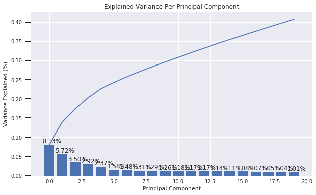

```python
# scree plot associated with the principal components
#     INPUT: pca - the result of instantian of PCA in scikit learn
#     OUTPUT: None

scree_plot(pca2)
```

### Discussion 2.2: Perform Dimensionality Reduction

Reporting my findings and decisions regarding dimensionality reduction. How many principal components / transformed features I am retaining for the next step of the analysis?

### Step 2.3: Interpret Principal Components

Now that we have our transformed principal components, it's a nice idea to check out the weight of each variable on the first few components to see if they can be interpreted in some fashion.

As a reminder, each principal component is a unit vector that points in the direction of highest variance (after accounting for the variance captured by earlier principal components). The further a weight is from zero, the more the principal component is in the direction of the corresponding feature. If two features have large weights of the same sign (both positive or both negative), then increases in one trend expect to be associated with increases in the other. To contrast, features with different signs can be expected to show a negative correlation: increases in one variable should result in a decrease in the other.

- To investigate the features, you should map each weight to their corresponding feature name, then sort the features according to weight. The most interesting features for each principal component, then, will be those at the beginning and end of the sorted list. Use the data dictionary document to help you understand these most prominent features, their relationships, and what a positive or negative value on the principal component might indicate.
- You should investigate and interpret feature associations from the first three principal components in this substep. To help facilitate this, you should write a function that you can call at any time to print the sorted list of feature weights, for the *i*-th principal component. This might come in handy in the next step of the project, when you interpret the tendencies of the discovered clusters.

```python
pca2_comp_df = pd.DataFrame(pca2.components_)
pca2_comp_df.columns = azdias4_scaled.columns
display(pca2_comp_df)
```

|  | ALTERSKATEGORIE_GROB | ANREDE_KZ | FINANZ_MINIMALIST | FINANZ_SPARER | FINANZ_VORSORGER | FINANZ_ANLEGER | FINANZ_UNAUFFAELLIGER | FINANZ_HAUSBAUER | GREEN_AVANTGARDE | HEALTH_TYP | LP_LEBENSPHASE_FEIN | LP_LEBENSPHASE_GROB | RETOURTYP_BK_S | SEMIO_SOZ | SEMIO_FAM | SEMIO_REL | SEMIO_MAT | SEMIO_VERT | SEMIO_LUST | SEMIO_ERL | SEMIO_KULT | SEMIO_RAT | SEMIO_KRIT | SEMIO_DOM | SEMIO_KAEM | SEMIO_PFLICHT | SEMIO_TRADV | SOHO_KZ | ANZ_PERSONEN | … |
| --- | --- | --- | --- | --- | --- | --- | --- | --- | --- | --- | --- | --- | --- | --- | --- | --- | --- | --- | --- | --- | --- | --- | --- | --- | --- | --- | --- | --- | --- | --- |
| 0 | -0.077574 | 0.014292 | -0.186043 | 0.108213 | -0.078343 | 0.050058 | 0.047857 | 0.148583 | -0.105834 | 0.022086 | -0.146902 | -0.133774 | -0.005806 | 0.022016 | 0.049275 | 0.073224 | 0.052142 | -0.042045 | -0.047378 | -0.043505 | 0.040905 | 0.064265 | 0.018804 | 0.023613 | 0.037890 | 0.077460 | 0.054333 | -0.002406 | -0.097154 | … |
| 1 | 0.235019 | 0.038181 | 0.094522 | -0.229502 | 0.220512 | -0.204492 | -0.214900 | 0.079860 | -0.004915 | -0.050961 | -0.047941 | -0.054721 | 0.155890 | -0.063249 | -0.134593 | -0.216521 | -0.131380 | -0.020682 | 0.163841 | 0.181079 | -0.166557 | -0.170575 | 0.074607 | 0.025313 | 0.054832 | -0.208378 | -0.209180 | -0.001889 | -0.069863 | … |
| 2 | 0.015378 | -0.344072 | 0.128712 | -0.055173 | 0.046805 | -0.154036 | -0.046078 | -0.061771 | 0.078656 | -0.002700 | 0.008361 | 0.008764 | 0.075564 | 0.257360 | 0.258998 | 0.112305 | 0.086670 | 0.318380 | 0.022552 | -0.206462 | 0.249090 | -0.154302 | -0.264651 | -0.280813 | -0.313446 | -0.024630 | -0.017159 | 0.000237 | 0.009436 | … |
| 3 | -0.000368 | 0.075189 | -0.010805 | -0.000279 | 0.004317 | -0.044482 | 0.009763 | 0.001472 | 0.183487 | -0.011261 | 0.255976 | 0.259733 | 0.004735 | -0.028470 | -0.063571 | -0.039622 | -0.029412 | -0.055487 | 0.020591 | 0.042725 | -0.062935 | 0.029642 | 0.020197 | 0.104400 | 0.107678 | -0.007336 | 0.000213 | 0.004568 | 0.227461 | … |
| 4 | 0.052239 | -0.060215 | 0.018559 | -0.026227 | 0.039434 | 0.049157 | -0.108931 | 0.013428 | -0.257352 | 0.000229 | 0.199582 | 0.212264 | 0.015614 | 0.024839 | 0.022352 | -0.010235 | -0.032891 | 0.049286 | 0.005582 | 0.017199 | 0.042735 | -0.067362 | -0.067093 | -0.086325 | -0.057448 | -0.029898 | -0.071663 | 0.001752 | 0.173942 | … |
| 5 | 0.007526 | 0.005219 | -0.130493 | 0.009104 | 0.030016 | 0.017875 | 0.027644 | 0.200001 | -0.027490 | -0.093227 | 0.061182 | 0.065771 | -0.010047 | 0.012118 | 0.015002 | 0.008929 | 0.027527 | 0.012048 | 0.066154 | -0.016061 | -0.025541 | -0.013529 | -0.059592 | -0.054930 | -0.063580 | -0.022460 | -0.004098 | -0.000346 | 0.084045 | … |
| 6 | 0.018848 | 0.002971 | 0.065724 | -0.014342 | -0.042186 | -0.014005 | -0.022376 | -0.115468 | -0.052509 | 0.071144 | -0.018925 | 0.000623 | 0.011973 | -0.020380 | -0.008845 | -0.039242 | 0.007225 | -0.007368 | -0.009999 | 0.028689 | -0.030952 | 0.003417 | 0.055612 | 0.037313 | 0.019274 | -0.021035 | 0.007189 | 0.005575 | -0.024566 | … |
| 7 | 0.008498 | -0.001183 | -0.034988 | 0.031488 | 0.040576 | 0.014188 | 0.041287 | 0.018442 | 0.007579 | 0.006443 | 0.044999 | 0.076328 | 0.011417 | 0.003789 | 0.004435 | 0.006604 | -0.053686 | -0.018492 | 0.014284 | 0.011119 | -0.005034 | -0.020426 | -0.025752 | -0.013663 | -0.008378 | 0.004812 | -0.036364 | -0.002645 | 0.048932 | … |
| 8 | -0.037119 | 0.054073 | -0.036127 | 0.017615 | -0.058976 | 0.080119 | -0.039168 | 0.112788 | 0.021485 | -0.138262 | -0.006317 | 0.004493 | -0.056201 | 0.003488 | -0.002427 | 0.054002 | 0.050253 | -0.024123 | 0.009871 | -0.020787 | 0.006541 | 0.071536 | -0.055509 | -0.027533 | 0.005265 | 0.032990 | 0.058385 | 0.006847 | 0.010723 | … |
| 9 | 0.027860 | 0.014504 | -0.037013 | -0.010540 | 0.068061 | -0.025033 | 0.033518 | 0.056133 | -0.045196 | -0.127089 | -0.021405 | -0.051996 | 0.001839 | -0.015008 | 0.018878 | 0.033701 | 0.062076 | 0.007134 | 0.050863 | 0.010192 | 0.000181 | 0.030341 | -0.023464 | -0.045317 | -0.010398 | 0.004675 | 0.010508 | 0.005682 | -0.004280 | … |
| 10 | 0.012462 | -0.053512 | -0.070953 | 0.030911 | 0.013769 | 0.058784 | -0.030549 | 0.069654 | 0.018269 | 0.106767 | -0.014983 | -0.026462 | -0.015628 | 0.064812 | -0.010259 | -0.056278 | -0.179135 | 0.024128 | -0.013575 | -0.020276 | -0.021363 | -0.126487 | -0.025308 | -0.040429 | -0.063510 | -0.070020 | -0.081502 | 0.006357 | -0.004754 | … |
| 11 | -0.061400 | 0.005010 | 0.036622 | -0.010604 | 0.034440 | -0.053538 | 0.017344 | -0.045937 | -0.081507 | 0.091589 | 0.008859 | 0.020699 | 0.050807 | -0.028612 | 0.011291 | 0.050909 | 0.006204 | -0.044657 | -0.031979 | -0.041019 | 0.026284 | 0.056560 | 0.055874 | 0.064255 | 0.043696 | 0.071880 | 0.049751 | 0.000737 | 0.013730 | … |
| 12 | 0.044749 | 0.028491 | 0.008862 | -0.028136 | -0.013544 | -0.046339 | 0.020331 | -0.024963 | -0.028741 | -0.196976 | 0.038128 | 0.045798 | 0.019723 | -0.013352 | 0.014197 | 0.006300 | 0.160707 | 0.035437 | 0.066519 | 0.031022 | -0.011684 | 0.049104 | -0.034250 | -0.031547 | 0.015685 | -0.011649 | 0.032783 | -0.005200 | -0.007223 | … |
| 13 | -0.012401 | 0.001433 | 0.011402 | -0.005204 | -0.016268 | -0.001601 | -0.014010 | 0.012868 | 0.022696 | 0.034251 | 0.012683 | -0.002070 | 0.006728 | 0.005372 | 0.001521 | 0.002129 | -0.000985 | -0.006084 | -0.003615 | 0.013308 | 0.002594 | 0.012532 | 0.018770 | 0.007155 | 0.004345 | 0.007552 | 0.007959 | -0.010742 | 0.005035 | … |
| 14 | -0.025736 | -0.002576 | -0.010649 | 0.003646 | 0.005491 | -0.028211 | 0.040108 | 0.016612 | -0.044542 | 0.046577 | 0.023037 | 0.019021 | 0.018368 | 0.001288 | -0.000620 | 0.007708 | -0.035176 | -0.015357 | 0.006140 | -0.018149 | -0.006282 | -0.000260 | 0.030085 | 0.009533 | 0.008772 | 0.008861 | 0.001516 | -0.007826 | 0.018194 | … |
| 15 | 0.015509 | 0.014336 | -0.016910 | 0.005013 | 0.026659 | -0.049007 | 0.112966 | 0.007184 | 0.002559 | -0.114253 | -0.006886 | -0.014012 | -0.010297 | 0.004503 | -0.006420 | 0.014433 | -0.016624 | 0.002519 | 0.037712 | 0.012889 | -0.002015 | -0.000958 | -0.015140 | -0.028353 | 0.004212 | 0.007244 | -0.016116 | 0.003123 | -0.003935 | … |
| 16 | 0.013883 | 0.006773 | 0.004155 | 0.002278 | -0.014794 | 0.020454 | -0.017277 | -0.003906 | 0.059048 | -0.014279 | -0.013814 | -0.012642 | -0.005351 | -0.011842 | 0.001984 | -0.003446 | 0.040408 | -0.001594 | -0.002212 | 0.019961 | 0.004226 | 0.010213 | -0.001789 | 0.001646 | -0.004738 | 0.004082 | -0.008219 | 0.018780 | 0.024468 | … |
| 17 | 0.067923 | -0.028385 | -0.040763 | 0.060717 | -0.016604 | 0.054131 | 0.090299 | 0.047006 | 0.029469 | -0.088252 | -0.009249 | -0.005113 | -0.109594 | 0.039935 | -0.026461 | -0.056998 | -0.146747 | 0.042787 | 0.060901 | 0.009140 | -0.037508 | -0.120151 | -0.078215 | -0.081450 | -0.049419 | -0.093697 | -0.115686 | -0.006140 | -0.043136 | … |
| 18 | 0.034960 | 0.006680 | -0.041149 | 0.065295 | -0.046180 | 0.067879 | 0.104158 | 0.030010 | 0.024579 | -0.041776 | -0.021526 | -0.013125 | -0.061047 | 0.010936 | -0.029895 | -0.033296 | -0.105910 | 0.004852 | 0.053969 | 0.022847 | -0.035569 | -0.069831 | -0.021607 | -0.039924 | -0.000865 | -0.045880 | -0.089643 | -0.001706 | 0.060428 | … |
| 19 | -0.008687 | 0.003886 | -0.034136 | -0.000746 | 0.018532 | -0.002187 | 0.017916 | 0.048961 | -0.139768 | -0.037535 | 0.005206 | 0.008361 | 0.024299 | 0.014542 | -0.000809 | 0.007234 | 0.001981 | -0.006120 | 0.030397 | -0.007151 | -0.013982 | 0.004236 | 0.001081 | -0.010976 | 0.002663 | -0.010746 | 0.007963 | -0.007028 | 0.037875 | … |

```python
def pc_features(rank, df):
    df_sorted = df.sort_values(df.index[rank], axis=1)

    return df_sorted.iloc[[rank]]
```

```python
# Map weights for the first principal component to corresponding feature names
# and then print the linked values, sorted by weight.
# HINT: Try defining a function here or in a new cell that you can reuse in the
# other cells.

display(pc_features(0, pca2_comp_df))
```

|  | MOBI_REGIO | KBA05_ANTG1 | FINANZ_MINIMALIST | PLZ8_ANTG1 | KBA05_GBZ | LP_LEBENSPHASE_FEIN | LP_LEBENSPHASE_GROB | KONSUMNAEHE | PLZ8_GBZ | INNENSTADT | LP_STATUS_FEIN_10.0 | LP_STATUS_GROB_5.0 | LP_STATUS_GROB_4.0 | LP_STATUS_FEIN_9.0 | CAMEO_INTL_2015_L | GREEN_AVANTGARDE | PRAEGENDE_JUGENDJAHRE_MOV | ZABEOTYP_1 | ANZ_PERSONEN | GEBAEUDETYP_RASTER | BALLRAUM | CAMEO_DEUG_2015_2 | GEBAEUDETYP_1.0 | LP_FAMILIE_GROB_5.0 | FINANZ_VORSORGER | ALTERSKATEGORIE_GROB | FINANZTYP_2 | CAMEO_DEUG_2015_4 | CAMEO_DEUG_2015_3 | … |
| --- | --- | --- | --- | --- | --- | --- | --- | --- | --- | --- | --- | --- | --- | --- | --- | --- | --- | --- | --- | --- | --- | --- | --- | --- | --- | --- | --- | --- | --- | --- |
| 0 | -0.20112 | -0.186057 | -0.186043 | -0.178026 | -0.177381 | -0.146902 | -0.133774 | -0.132839 | -0.129513 | -0.122972 | -0.115382 | -0.115382 | -0.108834 | -0.10756 | -0.107499 | -0.105834 | -0.105834 | -0.097557 | -0.097154 | -0.094589 | -0.09276 | -0.087529 | -0.086831 | -0.08151 | -0.078343 | -0.077574 | -0.074062 | -0.071097 | -0.063992 | … |

```python
# Map weights for the second principal component to corresponding feature names
# and then print the linked values, sorted by weight.

display(pc_features(1, pca2_comp_df))
```

|  | PRAEGENDE_JUGENDJAHRE_DEC | FINANZ_SPARER | SEMIO_REL | FINANZ_UNAUFFAELLIGER | SEMIO_TRADV | SEMIO_PFLICHT | FINANZ_ANLEGER | SEMIO_RAT | SEMIO_KULT | ONLINE_AFFINITAET | FINANZTYP_1 | SEMIO_FAM | SEMIO_MAT | ZABEOTYP_4 | LP_STATUS_FEIN_2.0 | ZABEOTYP_5 | FINANZTYP_4 | LP_STATUS_FEIN_5.0 | GFK_URLAUBERTYP_9.0 | FINANZTYP_3 | ANZ_PERSONEN | LP_FAMILIE_GROB_4.0 | SEMIO_SOZ | PLZ8_ANTG1 | ZABEOTYP_1 | MOBI_REGIO | CJT_GESAMTTYP_4.0 | LP_LEBENSPHASE_GROB | KBA05_GBZ | … |
| --- | --- | --- | --- | --- | --- | --- | --- | --- | --- | --- | --- | --- | --- | --- | --- | --- | --- | --- | --- | --- | --- | --- | --- | --- | --- | --- | --- | --- | --- | --- |
| 1 | -0.239505 | -0.229502 | -0.216521 | -0.2149 | -0.20918 | -0.208378 | -0.204492 | -0.170575 | -0.166557 | -0.162246 | -0.135675 | -0.134593 | -0.13138 | -0.108638 | -0.098232 | -0.091985 | -0.088569 | -0.080123 | -0.074246 | -0.072274 | -0.069863 | -0.069393 | -0.063249 | -0.05608 | -0.056079 | -0.054828 | -0.05482 | -0.054721 | -0.054255 | … |

```python
# Map weights for the third principal component to corresponding feature names
# and then print the linked values, sorted by weight.

display(pc_features(2, pca2_comp_df))
```

|  | ANREDE_KZ | SEMIO_KAEM | SEMIO_DOM | SEMIO_KRIT | SEMIO_ERL | SEMIO_RAT | FINANZ_ANLEGER | FINANZTYP_1 | SHOPPER_TYP_2.0 | LP_STATUS_FEIN_2.0 | LP_STATUS_FEIN_4.0 | ZABEOTYP_4 | FINANZ_HAUSBAUER | INNENSTADT | LP_FAMILIE_GROB_3.0 | FINANZ_SPARER | BALLRAUM | KONSUMNAEHE | SHOPPER_TYP_3.0 | PLZ8_ANTG1 | PRAEGENDE_JUGENDJAHRE_DEC | FINANZ_UNAUFFAELLIGER | GEBAEUDETYP_RASTER | KKK | LP_FAMILIE_FEIN_4.0 | HH_EINKOMMEN_SCORE | ZABEOTYP_3 | PLZ8_GBZ | LP_STATUS_GROB_2.0 | … |
| --- | --- | --- | --- | --- | --- | --- | --- | --- | --- | --- | --- | --- | --- | --- | --- | --- | --- | --- | --- | --- | --- | --- | --- | --- | --- | --- | --- | --- | --- | --- |
| 2 | -0.344072 | -0.313446 | -0.280813 | -0.264651 | -0.206462 | -0.154302 | -0.154036 | -0.100144 | -0.093142 | -0.080167 | -0.073933 | -0.063194 | -0.061771 | -0.059841 | -0.055241 | -0.055173 | -0.053091 | -0.050613 | -0.050099 | -0.048997 | -0.048487 | -0.046078 | -0.041852 | -0.039819 | -0.039809 | -0.038373 | -0.037572 | -0.036006 | -0.031748 | … |

```python
def map_comp_weights(df, pca, comp):
    '''
    INPUT:
        df: DataFrame
        pca: Fitted PCA instance
        comp: component index

    RETURN:
        DataFrame: Mapped features to their weights in corresponding component
    '''
    comp_weights = pd.DataFrame(pca.components_, columns=list(df.columns)).iloc[comp]
    comp_weights.sort_values(inplace=True, ascending=False)

    return comp_weights

def plot_comp_weights(df, pca, comp, n_features):
    comp_weights = map_comp_weights(df, pca, comp)
    comp_weights = pd.concat([comp_weights.head(n_features), comp_weights.tail(n_features)])

    comp_weights.plot(kind='bar')
    plt.title('Component {}'.format(comp+1))
    plt.ylabel('Weight')
    ax = plt.gca()
    ax.grid(linewidth='0.5', alpha=0.5)
    ax.set_axisbelow(True)
    plt.show()

    return comp_weights
```

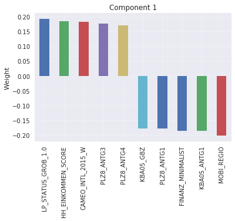

```
LP_STATUS_GROB_1.0    0.191648
HH_EINKOMMEN_SCORE    0.184567
CAMEO_INTL_2015_W     0.181526
PLZ8_ANTG3            0.177253
PLZ8_ANTG4            0.171286
KBA05_GBZ            -0.177381
PLZ8_ANTG1           -0.178026
FINANZ_MINIMALIST    -0.186043
KBA05_ANTG1          -0.186057
MOBI_REGIO           -0.201120
Name: 0, dtype: float64
```

```python
# PCA1 - mapping weights to feature names + printing linked values sorted by weight:

comp1_weights = plot_comp_weights(azdias4_scaled, pca2, 0, 5)
comp1_weights
```

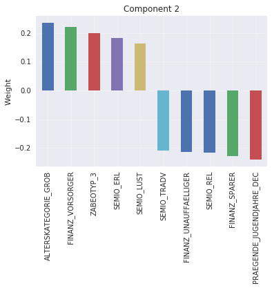

```
ALTERSKATEGORIE_GROB         0.235019
FINANZ_VORSORGER             0.220512
ZABEOTYP_3                   0.199880
SEMIO_ERL                    0.181079
SEMIO_LUST                   0.163841
SEMIO_TRADV                 -0.209180
FINANZ_UNAUFFAELLIGER       -0.214900
SEMIO_REL                   -0.216521
FINANZ_SPARER               -0.229502
PRAEGENDE_JUGENDJAHRE_DEC   -0.239505
Name: 1, dtype: float64
```

```python
# PCA2 - mapping weights to feature names + printing linked values sorted by weight:

comp2_weights = plot_comp_weights(azdias4_scaled, pca2, 1, 5)
comp2_weights
```

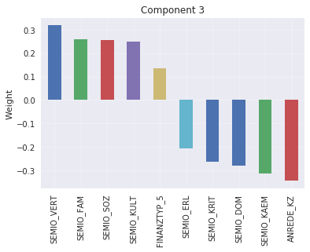

```
SEMIO_VERT     0.318380
SEMIO_FAM      0.258998
SEMIO_SOZ      0.257360
SEMIO_KULT     0.249090
FINANZTYP_5    0.136803
SEMIO_ERL     -0.206462
SEMIO_KRIT    -0.264651
SEMIO_DOM     -0.280813
SEMIO_KAEM    -0.313446
ANREDE_KZ     -0.344072
Name: 2, dtype: float64
```

```python
# PCA3 - mapping weights to feature names + printing linked values sorted by weight:

comp3_weights = plot_comp_weights(azdias4_scaled, pca2, 2, 5)
comp3_weights
```

### Discussion 2.3: Interpret Principal Components

Reporting my observations from detailed investigation of the first few principal components generated. Can we interpret positive and negative values from them in a meaningful way?

**Principal Component 1**

PC1 top-4 deciding features in each number sign are:

- Negative: `MOBI_REGIO` (RR1 region features: Movement patterns), `KBA05_ANTG1` (RR3 micro-cell features: Number of 1-2 family houses in the microcell), `FINANZ_MINIMALIST` (Person-level features: low financial interest), `PLZ8_ANTG1` (PLZ8 macro-cell features: Number of 1-2 family houses in the PLZ8 region).
- Positive: `LP_STATUS_GROB_1.0` (Person-level features: Social status, rough scale), `HH_EINKOMMEN_SCORE` (Household-level features: Estimated household net income), `CAMEO_INTL_2015_W` (RR4 micro-cell features: Wealth Stage Typology, mapped to international code), `PLZ8_ANTG3` (PLZ8 macro-cell features: Number of 6-10 family houses in the PLZ8 region).

As evident from PC1, the most deciding features coming from: movement patterns in RR1 region, Number of 1-2 family houses in the microcell/region, Financial typology (MINIMALIST), social status, household net income, Wealth Stage Typology, and number 6-10 family houses in the region.

Considering PC1 features relative signs, one can safely deduce that there is a reciprocal relationship between 1-2 family houses and 6-10 family houses as confirmed by the first component of PCA.

Besides, there is a direct relationship between number of 1-2 family houses in the microcell and that of the PLZ8 region.

**Principal Component 2**

PC2 top-3 deciding features in each number sign are:

- Negative: `PRAEGENDE_JUGENDJAHRE_DEC` (Person-level features: Dominating movement of person's youth in particular decade), `FINANZ_SPARER` (Person-level features: Financial typology-money-saver), `SEMIO_REL` (Person-level features: Personality typology-religious)
- Positive: `ALTERSKATEGORIE_GROB` (Person-level features: Estimated age based on given name analysis), `FINANZ_VORSORGER` (Person-level features: Financial typology-be prepared), `ZABEOTYP_3` (Person-level features: Energy consumption typology).

As visible from PC2, the most deciding features coming from:

Dominating movement of person's youth in particular decade, age bracket, financial typology (2 dimensions), religious factor and energey consumption typology.

Considering PC2 features relative signs, it is also drawn that there is a negative correlation between money-saver & be-prepared financial attitudes. Interestingly enough, there are direct correlations between religious personality & money-saving attitude as well as between conservative attitudes of financially be-prepared & Energy consumption (fair supplied) typology.

**Principal Component 3**

PC3 top-3 deciding features in each number sign are:

- Negative: `ANREDE_KZ` (Person-level features: Gender), `SEMIO_KAEM` (Person-level features: Personality typology-combative attitude), `SEMIO_DOM` (Person-level features: Personality typology-dominant-minded)
- Positive: `SEMIO_VERT` (Person-level features: Personality typology-dreamful), `SEMIO_FAM` (Person-level features: Personality typology-family-minded), `SEMIO_SOZ` (Person-level features: Personality typology-socially-minded).

which all fall under Person-level features.

Considering PC3 features relative signs, both Gender and Personality typology are closely correlated following the same behavioral pattern.

On the negative side, gender, combative-dominant & dominant-minded attributes (aggressive personality attitudes) follow the same trend. On the positive side, on the contrary, the dominant Personality typology features are dreamful, family-minded & socially-minded (peaceful personality attitudes) which all run counter to the negative sign features characteristics as evident from the third component of PCA.

## Step 3: Clustering

### Step 3.1: Apply Clustering to General Population

You've assessed and cleaned the demographics data, then scaled and transformed them. Now, it's time to see how the data clusters in the principal components space. In this substep, you will apply k-means clustering to the dataset and use the average within-cluster distances from each point to their assigned cluster's centroid to decide on a number of clusters to keep.

- Use sklearn's KMeans class to perform k-means clustering on the PCA-transformed data.
- Then, compute the average difference from each point to its assigned cluster's center. **Hint**: The KMeans object's `.score()` method might be useful here, but note that in sklearn, scores tend to be defined so that larger is better. Try applying it to a small, toy dataset, or use an internet search to help your understanding.
- Perform the above two steps for a number of different cluster counts. You can then see how the average distance decreases with an increasing number of clusters. However, each additional cluster provides a smaller net benefit. Use this fact to select a final number of clusters in which to group the data. **Warning**: because of the large size of the dataset, it can take a long time for the algorithm to resolve. The more clusters to fit, the longer the algorithm will take. You should test for cluster counts through at least 10 clusters to get the full picture, but you shouldn't need to test for a number of clusters above about 30.
- Once you've selected a final number of clusters to use, re-fit a KMeans instance to perform the clustering operation. Make sure that you also obtain the cluster assignments for the general demographics data, since you'll be using them in the final Step 3.3.

```python
# create a scree plot
# Fit a kmeans model with changing k from 2-22
# Obtain the score for each model (take the absolute value)
# Plot the score against k

def get_kmeans_score(data, center):
    '''
    returns the kmeans score regarding SSE for points to centers
    INPUT:
        data - the dataset you want to fit kmeans to
        center - the number of centers you want (the k value)
    OUTPUT:
        score - the SSE score for the kmeans model fit to the data
    '''
    #instantiate kmeans
    kmeans = KMeans(n_clusters=center)

    # Then fit the model to your data using the fit method
    model = kmeans.fit(data)

    # Obtain a score (average within-cluster distances) related to the fitted model
    score = np.abs(model.score(data))

    return score
```

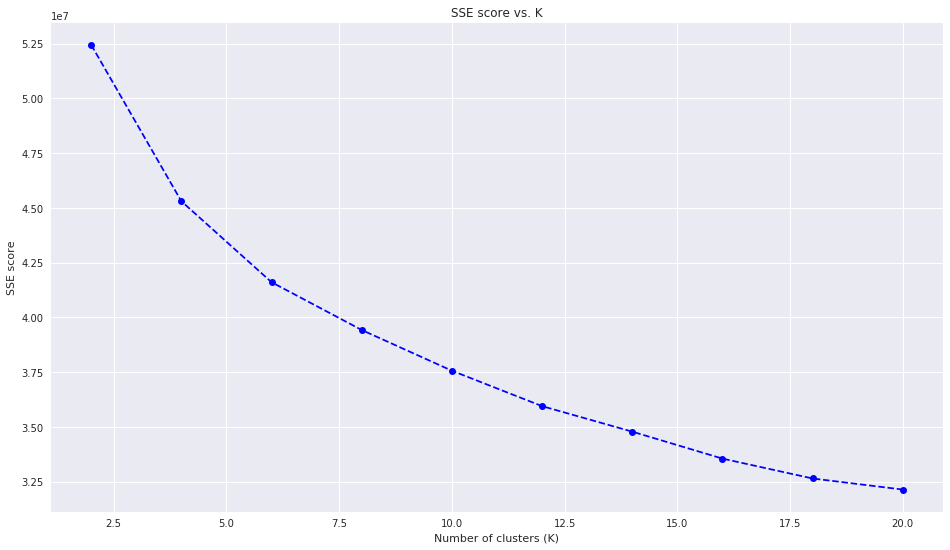

```python
# investiage relation between average within-cluster distance vs. different cluster counts

# Make the images larger
plt.rcParams['figure.figsize'] = (16, 9)

scores = []
centers = list(range(2, 22, 2))

for center in centers:
    scores.append(get_kmeans_score(azdias4_pca2, center))

plt.plot(centers, scores, linestyle='--', marker='o', color='b');
plt.xlabel('Number of clusters (K)');
plt.ylabel('SSE score'); # Sum of Squared Errors
plt.title('SSE score vs. K');

    # run k-means clustering on the data and...


    # compute the average within-cluster distances.
```

```python
# Investigate the change in within-cluster distance across number of clusters.
# HINT: Use matplotlib's plot function to visualize this relationship.
```

Using a scree plot is a common method for understanding if an additional cluster center is needed. The `elbow method` used by looking at a scree plot is subjective, yet we can refer to scree plot to see how many cluster centers might be indicated which in this case turns out to be 16. Beyond **16 clusters** decrease in SSE (Sum of Squared Errors) is not substantial enough to suggest the need for an additional cluster.

```python
# Re-fit the k-means model with the selected number of clusters and obtain
# cluster predictions for the general population demographics data.

kmeans = KMeans(n_clusters=16)
model = kmeans.fit(azdias4_pca2) # fitting KMeans model to pca-transformed data
azdias_pred = model.predict(azdias4_pca2) # returning array of indices for the cluster each sample belongs to.
```

```python
# display(pd.DataFrame(azdias_pred))
```

### Discussion 3.1: Apply Clustering to General Population

Reporting my findings and decisions regarding clustering. Into how many clusters have you decided to segment the population?)

I have created a scree plot that reflects correlation between number of clusters and SSE score (average within-cluster distances from each point to their assigned cluster's centroid) to decide the optimal number of clusters to keep. Using the elbow method on the created scree plot I opt for **16 clusters** as the optimal number beyond which SSE score does not decrease substantially worthy of adding new cluster!

### Step 3.2: Apply All Steps to the Customer Data

Now that you have clusters and cluster centers for the general population, it's time to see how the customer data maps on to those clusters. Take care to not confuse this for re-fitting all of the models to the customer data. Instead, you're going to use the fits from the general population to clean, transform, and cluster the customer data. In the last step of the project, you will interpret how the general population fits apply to the customer data.

- Don't forget when loading in the customers data, that it is semicolon (`;`) delimited.
- Apply the same feature wrangling, selection, and engineering steps to the customer demographics using the `clean_data()` function you created earlier. (You can assume that the customer demographics data has similar meaning behind missing data patterns as the general demographics data.)
- Use the sklearn objects from the general demographics data, and apply their transformations to the customers data. That is, you should not be using a `.fit()` or `.fit_transform()` method to re-fit the old objects, nor should you be creating new sklearn objects! Carry the data through the feature scaling, PCA, and clustering steps, obtaining cluster assignments for all of the data in the customer demographics data.

```python
# Load in the customer demographics data.
customers = pd.read_csv('./Udacity_CUSTOMERS_Subset.csv', sep = ';')
```

```python
customers.head(n=10)
```

|  | AGER_TYP | ALTERSKATEGORIE_GROB | ANREDE_KZ | CJT_GESAMTTYP | FINANZ_MINIMALIST | FINANZ_SPARER | FINANZ_VORSORGER | FINANZ_ANLEGER | FINANZ_UNAUFFAELLIGER | FINANZ_HAUSBAUER | FINANZTYP | GEBURTSJAHR | GFK_URLAUBERTYP | GREEN_AVANTGARDE | HEALTH_TYP | LP_LEBENSPHASE_FEIN | LP_LEBENSPHASE_GROB | LP_FAMILIE_FEIN | LP_FAMILIE_GROB | LP_STATUS_FEIN | LP_STATUS_GROB | NATIONALITAET_KZ | PRAEGENDE_JUGENDJAHRE | RETOURTYP_BK_S | SEMIO_SOZ | SEMIO_FAM | SEMIO_REL | SEMIO_MAT | SEMIO_VERT | … |
| --- | --- | --- | --- | --- | --- | --- | --- | --- | --- | --- | --- | --- | --- | --- | --- | --- | --- | --- | --- | --- | --- | --- | --- | --- | --- | --- | --- | --- | --- | --- |
| 0 | 2 | 4 | 1 | 5.0 | 5 | 1 | 5 | 1 | 2 | 2 | 2 | 0 | 4.0 | 1 | 1 | 20.0 | 5.0 | 2.0 | 2.0 | 10.0 | 5.0 | 1 | 4 | 5.0 | 6 | 5 | 2 | 6 | 6 | … |
| 1 | -1 | 4 | 1 | NaN | 5 | 1 | 5 | 1 | 3 | 2 | 2 | 0 | NaN | 0 | 1 | NaN | NaN | NaN | NaN | NaN | NaN | 1 | 0 | NaN | 3 | 6 | 2 | 6 | 7 | … |
| 2 | -1 | 4 | 2 | 2.0 | 5 | 1 | 5 | 1 | 4 | 4 | 2 | 0 | 3.0 | 1 | 2 | 13.0 | 3.0 | 1.0 | 1.0 | 10.0 | 5.0 | 1 | 4 | 5.0 | 2 | 2 | 1 | 3 | 3 | … |
| 3 | 1 | 4 | 1 | 2.0 | 5 | 1 | 5 | 2 | 1 | 2 | 6 | 0 | 10.0 | 0 | 2 | 0.0 | 0.0 | 0.0 | 0.0 | 9.0 | 4.0 | 1 | 1 | 3.0 | 6 | 5 | 3 | 4 | 7 | … |
| 4 | -1 | 3 | 1 | 6.0 | 3 | 1 | 4 | 4 | 5 | 2 | 2 | 1960 | 2.0 | 0 | 3 | 31.0 | 10.0 | 10.0 | 5.0 | 1.0 | 1.0 | 1 | 8 | 5.0 | 4 | 5 | 4 | 6 | 5 | … |
| 5 | 1 | 3 | 1 | 4.0 | 5 | 1 | 5 | 1 | 2 | 3 | 5 | 0 | 11.0 | 1 | 3 | 17.0 | 5.0 | 2.0 | 2.0 | 7.0 | 3.0 | 1 | 4 | 3.0 | 6 | 4 | 4 | 1 | 7 | … |
| 6 | 2 | 4 | 1 | 2.0 | 5 | 1 | 5 | 1 | 1 | 2 | 2 | 1942 | 10.0 | 1 | 2 | 20.0 | 5.0 | 2.0 | 2.0 | 10.0 | 5.0 | 1 | 4 | 5.0 | 4 | 2 | 5 | 1 | 6 | … |
| 7 | 1 | 4 | 1 | 2.0 | 5 | 1 | 5 | 1 | 2 | 2 | 5 | 1938 | 8.0 | 1 | 1 | 20.0 | 5.0 | 2.0 | 2.0 | 10.0 | 5.0 | 1 | 4 | 5.0 | 6 | 4 | 5 | 6 | 7 | … |
| 8 | 2 | 4 | 2 | 1.0 | 2 | 2 | 5 | 1 | 1 | 5 | 5 | 1914 | 3.0 | 0 | 2 | 6.0 | 2.0 | 1.0 | 1.0 | 1.0 | 1.0 | 1 | 1 | 5.0 | 2 | 3 | 1 | 1 | 2 | … |
| 9 | 1 | 3 | 1 | 3.0 | 5 | 2 | 4 | 1 | 3 | 1 | 2 | 1959 | 1.0 | 1 | 3 | 28.0 | 8.0 | 8.0 | 4.0 | 10.0 | 5.0 | 1 | 9 | 2.0 | 6 | 4 | 4 | 1 | 7 | … |

```python
# customers.describe()
```

```python
# customers.info()
```

```
number of customer feature outliers > 20%:  42
```

|  | KK_KUNDENTYP | KBA05_ANTG4 | KBA05_BAUMAX | KBA05_ANTG3 | KBA05_ANTG2 | KBA05_ANTG1 | MOBI_REGIO | KBA05_GBZ | REGIOTYP | KKK | W_KEIT_KIND_HH | PLZ8_BAUMAX | PLZ8_ANTG4 | PLZ8_HHZ | PLZ8_ANTG2 | PLZ8_ANTG1 | PLZ8_GBZ | PLZ8_ANTG3 | ANZ_HH_TITEL | KBA13_ANZAHL_PKW | ARBEIT | ORTSGR_KLS9 | RELAT_AB | CAMEO_INTL_2015 | CAMEO_DEU_2015 | CAMEO_DEUG_2015 | EWDICHTE | INNENSTADT | BALLRAUM | … |
| --- | --- | --- | --- | --- | --- | --- | --- | --- | --- | --- | --- | --- | --- | --- | --- | --- | --- | --- | --- | --- | --- | --- | --- | --- | --- | --- | --- | --- | --- | --- |
| cust_missing_percent | 58.406382 | 29.209192 | 29.209192 | 29.209192 | 29.209192 | 29.209192 | 29.209192 | 29.209192 | 28.311732 | 28.311732 | 28.04145 | 27.53115 | 27.53115 | 27.53115 | 27.53115 | 27.53115 | 27.53115 | 27.53115 | 27.189907 | 26.757352 | 26.33732 | 26.33732 | 26.33732 | 26.312274 | 26.312274 | 26.312274 | 26.06756 | 26.06756 | 26.06756 | … |

```
<function matplotlib.pyplot.show(*args, **kw)>
```

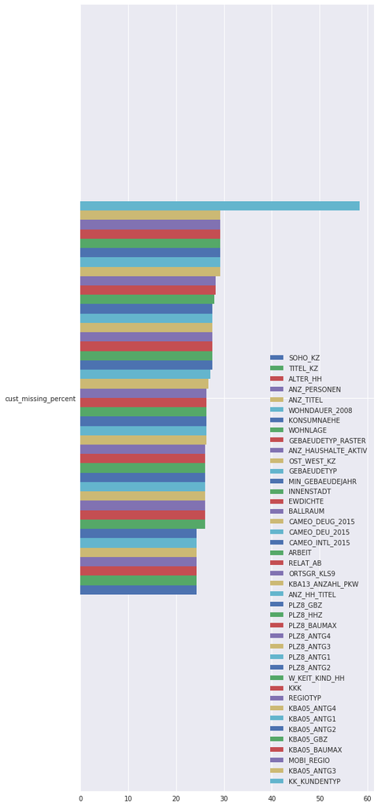

```python
# Investigate patterns of per-column missing values in customer data. # cmap=plt.cm.Blues


cust_missing_percent = (customers.isnull().sum(axis=0) / len(customers)) * 100
cust_missing_percent_df = pd.DataFrame(cust_missing_percent, columns = ['cust_missing_percent'])

cust_missing_percent_g20_df = cust_missing_percent_df[cust_missing_percent_df['cust_missing_percent'] > 20.0]
cust_missing_percent_g20_sorted_desc_df = cust_missing_percent_g20_df.sort_values(by=['cust_missing_percent'], inplace=False, ascending=False)
print("number of customer feature outliers > 20%: ", cust_missing_percent_g20_sorted_desc_df.shape[0])
display(cust_missing_percent_g20_sorted_desc_df.transpose())


cust_missing_percent_g20_sorted_asc_df = cust_missing_percent_g20_df.sort_values(by=['cust_missing_percent'], inplace=False, ascending=True)

cust_missing_percent_g20_sorted_asc_tr_df = cust_missing_percent_g20_sorted_asc_df.transpose()
cust_missing_percent_g20_sorted_asc_tr_df.plot(kind='barh', figsize = (8,22))
plt.show
```

According to the sorted values of per-column missing for customers feature, I found out that if we put the threshold 20% as in azdias dataset, `OST_WEST_KZ` feature will disappear right after removing the columns > 20 % missing values since there are 42 outlier columns (>20% missing) in customers dataset including `OST_WEST_KZ` feature with 26.05% missing values.

Therefore, for the case of customers dataset, I raise the threshold to 30%. In that case, just `KK_KUNDENTYP` will be dropped as outlier with 58.41% missing values.

```python
def clean_data(df):
    """
    Perform feature trimming, re-encoding, and engineering for demographics
    data

    INPUT: Demographics DataFrame
    OUTPUT: Trimmed and cleaned demographics DataFrame
    """

    cldf = df

    # Put in code here to execute all main cleaning steps:
    # convert missing value codes into NaNs, ...

    # Identify missing or unknown data values and convert them to NaNs.
    for indx in range(len(feat_info)):
        missing_or_unknown = feat_info.iloc[indx]['missing_or_unknown']
        missing_or_unknown = missing_or_unknown.strip('[')
        missing_or_unknown = missing_or_unknown.strip(']')
        missing_or_unknown = missing_or_unknown.split(sep=',')
        missing_or_unknown = [int(value) if (value!='X' and value!='XX' and value!='') else value for value in missing_or_unknown]
        if missing_or_unknown != ['']:
            cldf = cldf.replace({feat_info.iloc[indx]['attribute']: missing_or_unknown}, np.nan)

    print("customer data after converting missing/unknown values to NaNs: ")
    display(cldf.head(n=10))
    # remove selected columns and rows, ...
    cldf_missing_percent = (cldf.isnull().sum(axis=0) / len(cldf)) * 100
    cldf_missing_percent_df = pd.DataFrame(cldf_missing_percent, columns = ['cldf_missing_percent'])
    # Remove the outlier columns from the dataset (perform other data engineering tasks such as imputation later)
    cldf_missing_percent_g30_df = cldf_missing_percent_df[cldf_missing_percent_df['cldf_missing_percent'] > 30.0]
    cldf_missing_percent_g30_tr_df = cldf_missing_percent_g30_df.transpose()

    # display(cldf_missing_percent_g20_tr_df.head(n=10))

    cldf2 = cldf.drop(cldf_missing_percent_g30_tr_df, axis = 1)
    print("customer data after removing col>30% missings: ")
    display(cldf2.head(n=10))

    # How much data is missing in each row of the dataset?
    rows_mis = pd.DataFrame(cldf2.isnull().sum(axis=1), columns=['missing_in_rows'])
    cldf2_r = cldf2.join(rows_mis)

    # dropping rows that contains > 10 missing values
    cldf3 = cldf2_r[cldf2_r['missing_in_rows']<=10]

    cldf3 = cldf3.drop('missing_in_rows', axis = 1)

    # select, re-encode, and engineer column values.
    # Re-Encode Categorical Features
    cat_feat = feat_info2[feat_info2['type']=='categorical']

    cldf3.OST_WEST_KZ = cldf3.OST_WEST_KZ.replace({'O': 0.0,'W': 1.0})
    # filtering list of categorical features for one-hot encoding via pandas.get_dummies
    multi_cat_list = []

    for column in cat_feat['attribute']:
        cat_unique_value = cldf3[column].unique() # returns list of unique values
        if cat_unique_value.size > 2: # we only need features containing more than 2 possible values
            multi_cat_list.append(column)

    # Re-encode categorical variable(s) to be kept in the analysis.
    cldf4 = pd.get_dummies(cldf3, columns=multi_cat_list)

    # Engineer Mixed-Type Features
    cat_feat_mix = feat_info2[feat_info2['type']=='mixed']
    for column in cat_feat_mix['attribute']:
        mixed_cat_unique_value = cldf4[column].unique() # mixed type feature unique values

    cldf4['PRAEGENDE_JUGENDJAHRE_DEC'] = cldf4['PRAEGENDE_JUGENDJAHRE']
    cldf4['PRAEGENDE_JUGENDJAHRE_MOV'] = cldf4['PRAEGENDE_JUGENDJAHRE']

    # Mapping PRAEGENDE_JUGENDJAHRE_DEC and PRAEGENDE_JUGENDJAHRE_MOV
    dict_dec =  {1: 40.0, 2: 40.0,
                 3: 50.0, 4: 50.0,
                 5: 60.0, 6: 60.0, 7: 60.0,
                 8: 70.0, 9: 70.0,
                 10: 80.0, 11: 80.0, 12: 80.0, 13: 80.0,
                 14: 90.0, 15: 90.0}


    # replacing with decade values
    cldf4.PRAEGENDE_JUGENDJAHRE_DEC = cldf4.PRAEGENDE_JUGENDJAHRE_DEC.replace(dict_dec)


    # encoding Mainstream & Avantgarde as 0 & 1, respectively
    dict_mov =  {1: 0.0, 2: 1.0,
                 3: 0.0, 4: 1.0,
                 5: 0.0, 6: 1.0, 7: 1.0,
                 8: 0.0, 9: 1.0,
                 10: 0.0, 11: 1.0,
                 12: 0.0, 13: 1.0,
                 14: 0.0, 15: 1.0}

    cldf4.PRAEGENDE_JUGENDJAHRE_MOV = cldf4.PRAEGENDE_JUGENDJAHRE_MOV.replace(dict_mov)

    # copy "CAMEO_INTL_2015" to 2 new columns: CAMEO_INTL_2015_W & CAMEO_INTL_2015_L
    cldf4['CAMEO_INTL_2015_W'] = cldf4['CAMEO_INTL_2015']
    cldf4['CAMEO_INTL_2015_L'] = cldf4['CAMEO_INTL_2015']

    # Encoding CAMEO_INTL_2015_W and CAMEO_INTL_2015_L
    # mapping Wealth stage codes
    dict_wealth = {'11': 1.0, '12': 1.0, '13': 1.0, '14': 1.0, '15': 1.0,
                   '21': 2.0, '22': 2.0, '23': 2.0, '24': 2.0, '25': 2.0,
                   '31': 3.0, '32': 3.0, '33': 3.0, '34': 3.0, '35': 3.0,
                   '41': 4.0, '42': 4.0, '43': 4.0, '44': 4.0, '45': 4.0,
                   '51': 5.0, '52': 5.0, '53': 5.0, '54': 5.0, '55': 5.0}

    cldf4.CAMEO_INTL_2015_W = cldf4.CAMEO_INTL_2015_W.replace(dict_wealth)

    # mapping Life Stage codes
    dict_life = {'11': 1.0, '12': 2.0, '13': 3.0, '14': 4.0, '15': 5.0,
                 '21': 1.0, '22': 2.0, '23': 3.0, '24': 4.0, '25': 5.0,
                 '31': 1.0, '32': 2.0, '33': 3.0, '34': 4.0, '35': 5.0,
                 '41': 1.0, '42': 2.0, '43': 3.0, '44': 4.0, '45': 5.0,
                 '51': 1.0, '52': 2.0, '53': 3.0, '54': 4.0, '55': 5.0}

    cldf4.CAMEO_INTL_2015_L = cldf4.CAMEO_INTL_2015_L.replace(dict_life)

    # dropping original columns substituted by engineered features and irrelevant/overlapping features
    cldf4.drop(['PRAEGENDE_JUGENDJAHRE', 'CAMEO_INTL_2015', 'WOHNLAGE', 'PLZ8_BAUMAX'], axis=1, inplace=True)

    # Return the cleaned dataframe.
    return cldf4
```

```python
# Apply preprocessing, feature transformation, and clustering from the general
# demographics onto the customer data, obtaining cluster predictions for the
# customer demographics data.


# def clean_data(df):
# Return the cleaned dataframe.
#    return df
customers_clean = clean_data(customers)
```

```
customer data after converting missing/unknown values to NaNs:
```

|  | AGER_TYP | ALTERSKATEGORIE_GROB | ANREDE_KZ | CJT_GESAMTTYP | FINANZ_MINIMALIST | FINANZ_SPARER | FINANZ_VORSORGER | FINANZ_ANLEGER | FINANZ_UNAUFFAELLIGER | FINANZ_HAUSBAUER | FINANZTYP | GEBURTSJAHR | GFK_URLAUBERTYP | GREEN_AVANTGARDE | HEALTH_TYP | LP_LEBENSPHASE_FEIN | LP_LEBENSPHASE_GROB | LP_FAMILIE_FEIN | LP_FAMILIE_GROB | LP_STATUS_FEIN | LP_STATUS_GROB | NATIONALITAET_KZ | PRAEGENDE_JUGENDJAHRE | RETOURTYP_BK_S | SEMIO_SOZ | SEMIO_FAM | SEMIO_REL | SEMIO_MAT | SEMIO_VERT | … |
| --- | --- | --- | --- | --- | --- | --- | --- | --- | --- | --- | --- | --- | --- | --- | --- | --- | --- | --- | --- | --- | --- | --- | --- | --- | --- | --- | --- | --- | --- | --- |
| 0 | 2.0 | 4.0 | 1 | 5.0 | 5 | 1 | 5 | 1 | 2 | 2 | 2 | NaN | 4.0 | 1 | 1.0 | 20.0 | 5.0 | 2.0 | 2.0 | 10.0 | 5.0 | 1.0 | 4.0 | 5.0 | 6 | 5 | 2 | 6 | 6 | … |
| 1 | NaN | 4.0 | 1 | NaN | 5 | 1 | 5 | 1 | 3 | 2 | 2 | NaN | NaN | 0 | 1.0 | NaN | NaN | NaN | NaN | NaN | NaN | 1.0 | NaN | NaN | 3 | 6 | 2 | 6 | 7 | … |
| 2 | NaN | 4.0 | 2 | 2.0 | 5 | 1 | 5 | 1 | 4 | 4 | 2 | NaN | 3.0 | 1 | 2.0 | 13.0 | 3.0 | 1.0 | 1.0 | 10.0 | 5.0 | 1.0 | 4.0 | 5.0 | 2 | 2 | 1 | 3 | 3 | … |
| 3 | 1.0 | 4.0 | 1 | 2.0 | 5 | 1 | 5 | 2 | 1 | 2 | 6 | NaN | 10.0 | 0 | 2.0 | NaN | NaN | NaN | NaN | 9.0 | 4.0 | 1.0 | 1.0 | 3.0 | 6 | 5 | 3 | 4 | 7 | … |
| 4 | NaN | 3.0 | 1 | 6.0 | 3 | 1 | 4 | 4 | 5 | 2 | 2 | 1960.0 | 2.0 | 0 | 3.0 | 31.0 | 10.0 | 10.0 | 5.0 | 1.0 | 1.0 | 1.0 | 8.0 | 5.0 | 4 | 5 | 4 | 6 | 5 | … |
| 5 | 1.0 | 3.0 | 1 | 4.0 | 5 | 1 | 5 | 1 | 2 | 3 | 5 | NaN | 11.0 | 1 | 3.0 | 17.0 | 5.0 | 2.0 | 2.0 | 7.0 | 3.0 | 1.0 | 4.0 | 3.0 | 6 | 4 | 4 | 1 | 7 | … |
| 6 | 2.0 | 4.0 | 1 | 2.0 | 5 | 1 | 5 | 1 | 1 | 2 | 2 | 1942.0 | 10.0 | 1 | 2.0 | 20.0 | 5.0 | 2.0 | 2.0 | 10.0 | 5.0 | 1.0 | 4.0 | 5.0 | 4 | 2 | 5 | 1 | 6 | … |
| 7 | 1.0 | 4.0 | 1 | 2.0 | 5 | 1 | 5 | 1 | 2 | 2 | 5 | 1938.0 | 8.0 | 1 | 1.0 | 20.0 | 5.0 | 2.0 | 2.0 | 10.0 | 5.0 | 1.0 | 4.0 | 5.0 | 6 | 4 | 5 | 6 | 7 | … |
| 8 | 2.0 | 4.0 | 2 | 1.0 | 2 | 2 | 5 | 1 | 1 | 5 | 5 | 1914.0 | 3.0 | 0 | 2.0 | 6.0 | 2.0 | 1.0 | 1.0 | 1.0 | 1.0 | 1.0 | 1.0 | 5.0 | 2 | 3 | 1 | 1 | 2 | … |
| 9 | 1.0 | 3.0 | 1 | 3.0 | 5 | 2 | 4 | 1 | 3 | 1 | 2 | 1959.0 | 1.0 | 1 | 3.0 | 28.0 | 8.0 | 8.0 | 4.0 | 10.0 | 5.0 | 1.0 | 9.0 | 2.0 | 6 | 4 | 4 | 1 | 7 | … |

```
customer data after removing col>30% missings:
```

|  | ALTERSKATEGORIE_GROB | ANREDE_KZ | CJT_GESAMTTYP | FINANZ_MINIMALIST | FINANZ_SPARER | FINANZ_VORSORGER | FINANZ_ANLEGER | FINANZ_UNAUFFAELLIGER | FINANZ_HAUSBAUER | FINANZTYP | GFK_URLAUBERTYP | GREEN_AVANTGARDE | HEALTH_TYP | LP_LEBENSPHASE_FEIN | LP_LEBENSPHASE_GROB | LP_FAMILIE_FEIN | LP_FAMILIE_GROB | LP_STATUS_FEIN | LP_STATUS_GROB | NATIONALITAET_KZ | PRAEGENDE_JUGENDJAHRE | RETOURTYP_BK_S | SEMIO_SOZ | SEMIO_FAM | SEMIO_REL | SEMIO_MAT | SEMIO_VERT | SEMIO_LUST | SEMIO_ERL | … |
| --- | --- | --- | --- | --- | --- | --- | --- | --- | --- | --- | --- | --- | --- | --- | --- | --- | --- | --- | --- | --- | --- | --- | --- | --- | --- | --- | --- | --- | --- | --- |
| 0 | 4.0 | 1 | 5.0 | 5 | 1 | 5 | 1 | 2 | 2 | 2 | 4.0 | 1 | 1.0 | 20.0 | 5.0 | 2.0 | 2.0 | 10.0 | 5.0 | 1.0 | 4.0 | 5.0 | 6 | 5 | 2 | 6 | 6 | 7 | 3 | … |
| 1 | 4.0 | 1 | NaN | 5 | 1 | 5 | 1 | 3 | 2 | 2 | NaN | 0 | 1.0 | NaN | NaN | NaN | NaN | NaN | NaN | 1.0 | NaN | NaN | 3 | 6 | 2 | 6 | 7 | 5 | 3 | … |
| 2 | 4.0 | 2 | 2.0 | 5 | 1 | 5 | 1 | 4 | 4 | 2 | 3.0 | 1 | 2.0 | 13.0 | 3.0 | 1.0 | 1.0 | 10.0 | 5.0 | 1.0 | 4.0 | 5.0 | 2 | 2 | 1 | 3 | 3 | 7 | 7 | … |
| 3 | 4.0 | 1 | 2.0 | 5 | 1 | 5 | 2 | 1 | 2 | 6 | 10.0 | 0 | 2.0 | NaN | NaN | NaN | NaN | 9.0 | 4.0 | 1.0 | 1.0 | 3.0 | 6 | 5 | 3 | 4 | 7 | 5 | 3 | … |
| 4 | 3.0 | 1 | 6.0 | 3 | 1 | 4 | 4 | 5 | 2 | 2 | 2.0 | 0 | 3.0 | 31.0 | 10.0 | 10.0 | 5.0 | 1.0 | 1.0 | 1.0 | 8.0 | 5.0 | 4 | 5 | 4 | 6 | 5 | 6 | 4 | … |
| 5 | 3.0 | 1 | 4.0 | 5 | 1 | 5 | 1 | 2 | 3 | 5 | 11.0 | 1 | 3.0 | 17.0 | 5.0 | 2.0 | 2.0 | 7.0 | 3.0 | 1.0 | 4.0 | 3.0 | 6 | 4 | 4 | 1 | 7 | 6 | 4 | … |
| 6 | 4.0 | 1 | 2.0 | 5 | 1 | 5 | 1 | 1 | 2 | 2 | 10.0 | 1 | 2.0 | 20.0 | 5.0 | 2.0 | 2.0 | 10.0 | 5.0 | 1.0 | 4.0 | 5.0 | 4 | 2 | 5 | 1 | 6 | 5 | 3 | … |
| 7 | 4.0 | 1 | 2.0 | 5 | 1 | 5 | 1 | 2 | 2 | 5 | 8.0 | 1 | 1.0 | 20.0 | 5.0 | 2.0 | 2.0 | 10.0 | 5.0 | 1.0 | 4.0 | 5.0 | 6 | 4 | 5 | 6 | 7 | 7 | 3 | … |
| 8 | 4.0 | 2 | 1.0 | 2 | 2 | 5 | 1 | 1 | 5 | 5 | 3.0 | 0 | 2.0 | 6.0 | 2.0 | 1.0 | 1.0 | 1.0 | 1.0 | 1.0 | 1.0 | 5.0 | 2 | 3 | 1 | 1 | 2 | 7 | 7 | … |
| 9 | 3.0 | 1 | 3.0 | 5 | 2 | 4 | 1 | 3 | 1 | 2 | 1.0 | 1 | 3.0 | 28.0 | 8.0 | 8.0 | 4.0 | 10.0 | 5.0 | 1.0 | 9.0 | 2.0 | 6 | 4 | 4 | 1 | 7 | 4 | 4 | … |

```python
customers_clean.shape
```

```
(139259, 192)
```

```python
azdias4_scaled.shape
```

```
(780153, 195)
```

```python
# customers_imp.columns.tolist()
```

```python
# azdias4_scaled.columns.tolist()
```

```python
customers_features_missing = list(set(azdias4_scaled.columns.tolist()) - set(customers_clean.columns.tolist()))
customers_features_missing
```

```
['REGIOTYP', 'GEBAEUDETYP_5.0', 'KKK']
```

After cleaning customers data, these 3 features are missing from cleaned customers data:

- `REGIOTYP` (RR1 region: Neighborhood typology)
- `GEBAEUDETYP_5.0` one-hot-encoded of `GEBAEUDETYP` (Building-level: Type of building (residential vs. commercial)) index 5 refers to "*company building w/o known company*" which makes sense as there is no company info for customers
- `KKK` (RR1 region: Purchasing power in region)

```python
print(customers_clean.columns.get_loc('GEBAEUDETYP_3.0'))
print(customers_clean.columns.get_loc('GEBAEUDETYP_4.0'))
# display(customers_clean.columns.get_loc('GEBAEUDETYP_5.0'))
print(customers_clean.columns.get_loc('GEBAEUDETYP_6.0'))
print(customers_clean.columns.get_loc('GEBAEUDETYP_8.0'))
```

```
131
132
133
134
```

```python
# Adding missing column GEBAEUDETYP_5.0 to re-use PCA models fitted to azdias general population

# filling with zeroes since encoded value of 5 is unknown

customers_clean.insert(loc=133, column='GEBAEUDETYP_5.0', value = 0)
```

```python
print(customers_clean.columns.get_loc('GEBAEUDETYP_3.0'))
print(customers_clean.columns.get_loc('GEBAEUDETYP_4.0'))
print(customers_clean.columns.get_loc('GEBAEUDETYP_5.0'))
print(customers_clean.columns.get_loc('GEBAEUDETYP_6.0'))
print(customers_clean.columns.get_loc('GEBAEUDETYP_8.0'))
```

```
131
132
133
134
135
```

```python
# display(customers_clean['GEBAEUDETYP_4.0'].head(n=5))
display(customers_clean.head(n=5))
```

|  | ALTERSKATEGORIE_GROB | ANREDE_KZ | FINANZ_MINIMALIST | FINANZ_SPARER | FINANZ_VORSORGER | FINANZ_ANLEGER | FINANZ_UNAUFFAELLIGER | FINANZ_HAUSBAUER | GREEN_AVANTGARDE | HEALTH_TYP | LP_LEBENSPHASE_FEIN | LP_LEBENSPHASE_GROB | RETOURTYP_BK_S | SEMIO_SOZ | SEMIO_FAM | SEMIO_REL | SEMIO_MAT | SEMIO_VERT | SEMIO_LUST | SEMIO_ERL | SEMIO_KULT | SEMIO_RAT | SEMIO_KRIT | SEMIO_DOM | SEMIO_KAEM | SEMIO_PFLICHT | SEMIO_TRADV | SOHO_KZ | ANZ_PERSONEN | … |
| --- | --- | --- | --- | --- | --- | --- | --- | --- | --- | --- | --- | --- | --- | --- | --- | --- | --- | --- | --- | --- | --- | --- | --- | --- | --- | --- | --- | --- | --- | --- |
| 0 | 4.0 | 1 | 5 | 1 | 5 | 1 | 2 | 2 | 1 | 1.0 | 20.0 | 5.0 | 5.0 | 6 | 5 | 2 | 6 | 6 | 7 | 3 | 4 | 1 | 3 | 1 | 1 | 2 | 1 | 0.0 | 2.0 | … |
| 2 | 4.0 | 2 | 5 | 1 | 5 | 1 | 4 | 4 | 1 | 2.0 | 13.0 | 3.0 | 5.0 | 2 | 2 | 1 | 3 | 3 | 7 | 7 | 1 | 2 | 7 | 5 | 6 | 4 | 1 | 0.0 | 1.0 | … |
| 3 | 4.0 | 1 | 5 | 1 | 5 | 2 | 1 | 2 | 0 | 2.0 | NaN | NaN | 3.0 | 6 | 5 | 3 | 4 | 7 | 5 | 3 | 4 | 3 | 3 | 3 | 3 | 3 | 4 | 0.0 | 0.0 | … |
| 4 | 3.0 | 1 | 3 | 1 | 4 | 4 | 5 | 2 | 0 | 3.0 | 31.0 | 10.0 | 5.0 | 4 | 5 | 4 | 6 | 5 | 6 | 4 | 5 | 5 | 3 | 5 | 2 | 5 | 4 | 0.0 | 4.0 | … |
| 5 | 3.0 | 1 | 5 | 1 | 5 | 1 | 2 | 3 | 1 | 3.0 | 17.0 | 5.0 | 3.0 | 6 | 4 | 4 | 1 | 7 | 6 | 4 | 6 | 2 | 5 | 5 | 3 | 3 | 4 | 0.0 | 2.0 | … |

```python
display(azdias4_scaled.head(n=5))
```

|  | ALTERSKATEGORIE_GROB | ANREDE_KZ | FINANZ_MINIMALIST | FINANZ_SPARER | FINANZ_VORSORGER | FINANZ_ANLEGER | FINANZ_UNAUFFAELLIGER | FINANZ_HAUSBAUER | GREEN_AVANTGARDE | HEALTH_TYP | LP_LEBENSPHASE_FEIN | LP_LEBENSPHASE_GROB | RETOURTYP_BK_S | SEMIO_SOZ | SEMIO_FAM | SEMIO_REL | SEMIO_MAT | SEMIO_VERT | SEMIO_LUST | SEMIO_ERL | SEMIO_KULT | SEMIO_RAT | SEMIO_KRIT | SEMIO_DOM | SEMIO_KAEM | SEMIO_PFLICHT | SEMIO_TRADV | SOHO_KZ | ANZ_PERSONEN | … |
| --- | --- | --- | --- | --- | --- | --- | --- | --- | --- | --- | --- | --- | --- | --- | --- | --- | --- | --- | --- | --- | --- | --- | --- | --- | --- | --- | --- | --- | --- | --- |
| 1 | -1.767651 | 0.958395 | -1.488140 | 1.539080 | -1.045251 | 1.467273 | 0.980071 | 1.326876 | -0.531199 | 1.088920 | 0.412206 | 0.317534 | -1.682495 | 0.434451 | -0.057434 | 0.005086 | -0.454614 | -1.685168 | -1.120989 | -1.436709 | -0.583197 | 1.277558 | -0.306355 | 1.336372 | -0.157888 | 1.505994 | 1.290984 | 10.871068 | 0.229631 | … |
| 2 | 0.198089 | 0.958395 | -1.488140 | 0.866538 | -1.771610 | -0.569041 | 0.262544 | 1.326876 | 1.882535 | 1.088920 | -1.099137 | -1.043720 | -0.306527 | -0.080370 | -1.629542 | -0.518465 | -0.454614 | -0.137103 | -0.168867 | 0.751916 | -0.583197 | 0.068660 | 1.408802 | 1.336372 | 1.446598 | -0.632808 | -0.410671 | -0.091987 | -0.633119 | … |
| 3 | 1.180959 | 0.958395 | 0.688928 | -0.478545 | 1.133828 | -0.569041 | -1.172510 | -0.817895 | -0.531199 | -0.263472 | -0.259502 | -0.499219 | -0.994511 | 0.434451 | -1.629542 | -1.042017 | -1.499833 | -0.137103 | -0.168867 | 1.299072 | -0.072196 | -0.535788 | -0.306355 | -0.309004 | 0.376940 | -0.098107 | 0.156547 | -0.091987 | -1.495869 | … |
| 4 | 0.198089 | -1.043411 | 0.688928 | 0.193996 | 0.407468 | -1.247812 | 0.262544 | -0.817895 | -0.531199 | 1.088920 | 1.335805 | 1.406536 | 1.069442 | 0.949272 | -0.057434 | 0.005086 | -0.977223 | 1.410963 | -0.168867 | -0.342397 | 0.949807 | -1.140237 | -0.878074 | -1.405922 | -1.227545 | -0.098107 | -0.977890 | -0.091987 | 1.955131 | … |
| 5 | -1.767651 | 0.958395 | -0.036761 | -1.151087 | 1.133828 | -0.569041 | -0.454983 | 1.326876 | -0.531199 | 1.088920 | -0.679320 | -0.771469 | -0.306527 | -1.110013 | -0.057434 | 1.575741 | 0.067996 | -1.169146 | -1.120989 | -1.436709 | 0.438806 | 1.882007 | -0.306355 | -0.309004 | -0.157888 | 1.505994 | 1.290984 | -0.091987 | -0.633119 | … |

```python
display(azdias4_scaled.columns.get_loc('GEBAEUDETYP_RASTER'))
# display(azdias4_scaled.columns.get_loc('KKK'))
display(azdias4_scaled.columns.get_loc('MOBI_REGIO'))
```

```
46
```

```
48
```

```python
# Adding missing column KKK to re-use PCA models fitted to azdias general population

# filling with zeroes KKK values are unknown

customers_clean.insert(loc=47, column='KKK', value = 0)
```

```python
display(azdias4_scaled.columns.get_loc('GEBAEUDETYP_RASTER'))
display(azdias4_scaled.columns.get_loc('KKK'))
display(azdias4_scaled.columns.get_loc('MOBI_REGIO'))
```

```
46
```

```
47
```

```
48
```

```python
display(azdias4_scaled.columns.get_loc('ONLINE_AFFINITAET'))
# display(azdias4_scaled.columns.get_loc('REGIOTYP'))
display(azdias4_scaled.columns.get_loc('KBA13_ANZAHL_PKW'))
```

```
49
```

```
51
```

```python
# Adding missing column REGIOTYP to re-use PCA models fitted to azdias general population

# filling with zeroes REGIOTYP values are unknown

customers_clean.insert(loc=50, column='REGIOTYP', value = 0)
```

```python
display(azdias4_scaled.columns.get_loc('ONLINE_AFFINITAET'))
display(azdias4_scaled.columns.get_loc('REGIOTYP'))
display(azdias4_scaled.columns.get_loc('KBA13_ANZAHL_PKW'))
```

```
49
```

```
50
```

```
51
```

```python
print("total nan values in customers cleaned data before imputation: {}".format(customers_clean.isna().sum().sum()))
```

```
total nan values in customers cleaned data before imputation: 71360
```

```python
customers_clean.shape
```

```
(139259, 195)
```

```python
# If you've not yet cleaned the dataset of all NaN values, then investigate and
# do that now.

# imputer = Imputer(missing_values=np.nan, strategy='median', axis = 0)
customers_imp = pd.DataFrame(imputer.transform(customers_clean))

customers_imp.columns = customers_clean.columns # restoring original column names
customers_imp.index = customers_clean.index # restoring original indices
```

```python
print("total nan values in customers cleaned data after imputation: {}".format(customers_imp.isna().sum().sum()))
```

```
total nan values in customers cleaned data after imputation: 0
```

```python
# customers data scaling transformation, scaler = StandardScaler()

customers_scaled = scaler.transform(customers_imp)
customers_scaled = pd.DataFrame(customers_scaled, columns=customers_imp.columns)

# PCA transformation
customers_pca = pca2.transform(customers_scaled)

# KMeans predictions
customers_pred = kmeans.predict(customers_pca)
```

### Step 3.3: Compare Customer Data to Demographics Data

At this point, you have clustered data based on demographics of the general population of Germany, and seen how the customer data for a mail-order sales company maps onto those demographic clusters. In this final substep, you will compare the two cluster distributions to see where the strongest customer base for the company is.

Consider the proportion of persons in each cluster for the general population, and the proportions for the customers. If we think the company's customer base to be universal, then the cluster assignment proportions should be fairly similar between the two. If there are only particular segments of the population that are interested in the company's products, then we should see a mismatch from one to the other. If there is a higher proportion of persons in a cluster for the customer data compared to the general population (e.g. 5% of persons are assigned to a cluster for the general population, but 15% of the customer data is closest to that cluster's centroid) then that suggests the people in that cluster to be a target audience for the company. On the other hand, the proportion of the data in a cluster being larger in the general population than the customer data (e.g. only 2% of customers closest to a population centroid that captures 6% of the data) suggests that group of persons to be outside of the target demographics.

Take a look at the following points in this step:

- Compute the proportion of data points in each cluster for the general population and the customer data. Visualizations will be useful here: both for the individual dataset proportions, but also to visualize the ratios in cluster representation between groups. Seaborn's [`countplot()`](https://seaborn.pydata.org/generated/seaborn.countplot.html) or [`barplot()`](https://seaborn.pydata.org/generated/seaborn.barplot.html) function could be handy.
  - Recall the analysis you performed in step 1.1.3 of the project, where you separated out certain data points from the dataset if they had more than a specified threshold of missing values. If you found that this group was qualitatively different from the main bulk of the data, you should treat this as an additional data cluster in this analysis. Make sure that you account for the number of data points in this subset, for both the general population and customer datasets, when making your computations!
- Which cluster or clusters are overrepresented in the customer dataset compared to the general population? Select at least one such cluster and infer what kind of people might be represented by that cluster. Use the principal component interpretations from step 2.3 or look at additional components to help you make this inference. Alternatively, you can use the `.inverse_transform()` method of the PCA and StandardScaler objects to transform centroids back to the original data space and interpret the retrieved values directly.
- Perform a similar investigation for the underrepresented clusters. Which cluster or clusters are underrepresented in the customer dataset compared to the general population, and what kinds of people are typified by these clusters?

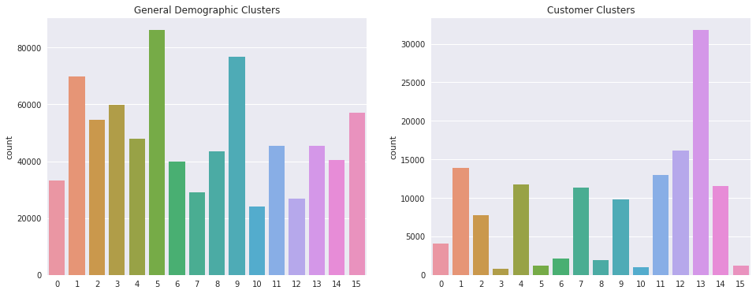

```python
# Compare the proportion of data in each cluster for the customer data to the
# proportion of data in each cluster for the general population.

fig, (ax1, ax2) = plt.subplots(1, 2, figsize=(16, 6))

sns.countplot(azdias_pred, ax=ax1)
ax1.set_title("General Demographic Clusters")
sns.countplot(customers_pred, ax=ax2)
ax2.set_title("Customer Clusters");
```

```python
# What kinds of people are part of a cluster that is overrepresented in the
# customer data compared to the general population?

# scaler = StandardScaler()
centroid_13 = scaler.inverse_transform(pca2.inverse_transform(kmeans.cluster_centers_[13]))
```

```python
overrepresented_clust = pd.Series(data=centroid_13, index=customers_imp.columns)
overrepresented_clust
```

```
ALTERSKATEGORIE_GROB            3.103737
ANREDE_KZ                       1.038052
FINANZ_MINIMALIST               4.711550
FINANZ_SPARER                   1.938661
FINANZ_VORSORGER                3.968706
FINANZ_ANLEGER                  1.755824
FINANZ_UNAUFFAELLIGER           2.417341
FINANZ_HAUSBAUER                1.841343
GREEN_AVANTGARDE                1.002520
HEALTH_TYP                      2.104745
LP_LEBENSPHASE_FEIN            24.828033
LP_LEBENSPHASE_GROB             7.200448
RETOURTYP_BK_S                  3.614977
SEMIO_SOZ                       5.478618
SEMIO_FAM                       5.011587
SEMIO_REL                       4.001535
SEMIO_MAT                       3.761386
SEMIO_VERT                      6.332435
SEMIO_LUST                      4.820937
SEMIO_ERL                       3.819078
SEMIO_KULT                      5.145874
SEMIO_RAT                       2.777680
SEMIO_KRIT                      2.965223
SEMIO_DOM                       3.213707
SEMIO_KAEM                      2.548905
SEMIO_PFLICHT                   3.507961
SEMIO_TRADV                     3.312843
SOHO_KZ                         0.010346
ANZ_PERSONEN                    2.274633
ANZ_TITEL                      -0.003692
HH_EINKOMMEN_SCORE              2.349485
W_KEIT_KIND_HH                  4.150366
WOHNDAUER_2008                  8.476434
ANZ_HAUSHALTE_AKTIV             0.522929
ANZ_HH_TITEL                   -0.032085
KONSUMNAEHE                     3.497496
MIN_GEBAEUDEJAHR             1993.055747
OST_WEST_KZ                     0.916256
KBA05_ANTG1                     2.762509
KBA05_ANTG2                     1.093849
```

[output cut: 141 more lines]

```
CAMEO_DEU_2015_7E               0.003782
CAMEO_DEU_2015_8A               0.010950
CAMEO_DEU_2015_8B               0.011455
CAMEO_DEU_2015_8C               0.006347
CAMEO_DEU_2015_8D               0.000198
CAMEO_DEU_2015_9A               0.010940
CAMEO_DEU_2015_9B               0.018654
CAMEO_DEU_2015_9C               0.013510
CAMEO_DEU_2015_9D               0.013553
CAMEO_DEU_2015_9E              -0.004004
PRAEGENDE_JUGENDJAHRE_DEC      68.755682
PRAEGENDE_JUGENDJAHRE_MOV       1.002520
CAMEO_INTL_2015_W               2.186280
CAMEO_INTL_2015_L               3.391390
dtype: float64
```

```python
# What kinds of people are part of a cluster that is underrepresented in the
# customer data compared to the general population?

centroid_5 = scaler.inverse_transform(pca2.inverse_transform(kmeans.cluster_centers_[5]))
```

```python
underrepresented_clust = pd.Series(data=centroid_5, index=customers_imp.columns)
underrepresented_clust
```

```
ALTERSKATEGORIE_GROB            1.824732
ANREDE_KZ                       1.987836
FINANZ_MINIMALIST               1.045124
FINANZ_SPARER                   4.527976
FINANZ_VORSORGER                2.066932
FINANZ_ANLEGER                  4.373096
FINANZ_UNAUFFAELLIGER           3.995628
FINANZ_HAUSBAUER                4.198354
GREEN_AVANTGARDE                0.037705
HEALTH_TYP                      2.199705
LP_LEBENSPHASE_FEIN             8.961355
LP_LEBENSPHASE_GROB             2.970941
RETOURTYP_BK_S                  2.544607
SEMIO_SOZ                       3.349723
SEMIO_FAM                       3.850325
SEMIO_REL                       5.168376
SEMIO_MAT                       4.547888
SEMIO_VERT                      2.324491
SEMIO_LUST                      3.151674
SEMIO_ERL                       4.433647
SEMIO_KULT                      3.995971
SEMIO_RAT                       5.808014
SEMIO_KRIT                      5.476676
SEMIO_DOM                       6.005116
SEMIO_KAEM                      6.050809
SEMIO_PFLICHT                   5.951880
SEMIO_TRADV                     5.133044
SOHO_KZ                         0.007936
ANZ_PERSONEN                    1.422006
ANZ_TITEL                       0.005870
HH_EINKOMMEN_SCORE              5.581256
W_KEIT_KIND_HH                  4.238526
WOHNDAUER_2008                  7.130233
ANZ_HAUSHALTE_AKTIV            13.328951
ANZ_HH_TITEL                    0.045246
KONSUMNAEHE                     2.203158
MIN_GEBAEUDEJAHR             1992.539807
OST_WEST_KZ                     0.769406
KBA05_ANTG1                     0.519725
KBA05_ANTG2                     1.398239
```

[output cut: 141 more lines]

```
CAMEO_DEU_2015_7E               0.002646
CAMEO_DEU_2015_8A               0.148161
CAMEO_DEU_2015_8B               0.069224
CAMEO_DEU_2015_8C               0.062921
CAMEO_DEU_2015_8D               0.025780
CAMEO_DEU_2015_9A               0.060717
CAMEO_DEU_2015_9B               0.083814
CAMEO_DEU_2015_9C               0.075112
CAMEO_DEU_2015_9D               0.093986
CAMEO_DEU_2015_9E               0.003595
PRAEGENDE_JUGENDJAHRE_DEC      86.529918
PRAEGENDE_JUGENDJAHRE_MOV       0.037705
CAMEO_INTL_2015_W               4.313465
CAMEO_INTL_2015_L               2.060241
dtype: float64
```

### Discussion 3.3: Compare Customer Data to Demographics Data

Reporting findings and conclusions from the clustering analysis. Can we describe segments of the population that are relatively popular with the mail-order company, or relatively unpopular with the company?

As evident from the foregoing `General Demographics` vs. `Customers` clustering results, we can gain the following insights:

- `Cluster 13` is **overrepresented** in the Customers dataset compared to that of the General Population dataset, meaning we can identify some segments of the population that are relatively popular and form the core customer base for the mail-order sales company in Germany:
  - `ALTERSKATEGORIE_GROB = 3.103737` People with age 46-60 years old is higher popular with the company
  - `ANREDE_KZ = 1.038052` Males are higher popular with the company
  - `SEMIO_SOZ = 5.478618` (low affinity) socially-minded personality are popular customer base
- `Cluster 5` is **underrepresented** in the Customers dataset compared to that of the General Population dataset, meaning we can carve out some segments of the population that are relatively unpopular with the mail-order sales company in Germany:
  - `ALTERSKATEGORIE_GROB = 1.824732` People with age 30-45 years old is lower popular with the company
  - `ANREDE_KZ = 1.987836` Females are not popular with the mail-order company
  - `SEMIO_SOZ = 3.349723` (high affinity) socially-minded personality are unpopular with the company

## Thank You!

[figure not shown]